# pvs_analysis_report

# Descriptive

## Demographic by person

under this section the demographic variable will be analyzed by mode of data collection. face to face or via phone interviews.

Format 1

| **Characteristic** | **Face to Face** N = 300<sup>1</sup> | **Phone** N = 724<sup>1</sup> |
| --- | --- | --- |
| Age Band |  |  |
| 18 to 29 | 83 (27.67%) | 280 (38.67%) |
| 30 to 39 | 77 (25.67%) | 216 (29.83%) |
| 40 to 49 | 59 (19.67%) | 119 (16.44%) |
| 60 to 69 | 16 (5.33%) | 27 (3.73%) |
| 70 to 79 | 14 (4.67%) | 9 (1.24%) |
| 80 or older | 51 (17.00%) | 73 (10.08%) |
| Sex |  |  |
| Female | 201 (67.00%) | 311 (42.96%) |
| Male | 99 (33.00%) | 413 (57.04%) |
| Education |  |  |
| No education | 37 (12.33%) | 32 (4.42%) |
| Primary school | 179 (59.67%) | 273 (37.71%) |
| Secondary school | 80 (26.67%) | 302 (41.71%) |
| Tertiary | 4 (1.33%) | 117 (16.16%) |
| Ethincity |  |  |
| Chichewa | 183 (61.00%) | 450 (62.15%) |
| Other | 68 (22.67%) | 116 (16.02%) |
| Tumbuka | 44 (14.67%) | 120 (16.57%) |
| Yao | 5 (1.67%) | 38 (5.25%) |
| Income Level |  |  |
| Less than MK52,000 | 190 (63.33%) | 278 (38.40%) |
| MK1,000,000 or more | 0 (0.00%) | 12 (1.66%) |
| MK100,000 to <MK500,000 | 40 (13.33%) | 205 (28.31%) |
| MK500,000 to <MK1,000,000 | 4 (1.33%) | 42 (5.80%) |
| MK52,000 to <MK100,000 | 59 (19.67%) | 165 (22.79%) |
| Refused to answer | 7 (2.33%) | 22 (3.04%) |

<sup>1</sup> n (%)

# maps: distribution of mode of data collection

```
## Map saved to C:\Users\Lenovo\OneDrive\Desktop\Git R project\R_Projects\People Voice  Study\maps\mode_of_data_collection_map.png
```

```
## Resolution: 2362.205 by 1181.102 pixels
```

```
## Size: 7.874016 by 3.937008 inches (300 dpi)
```

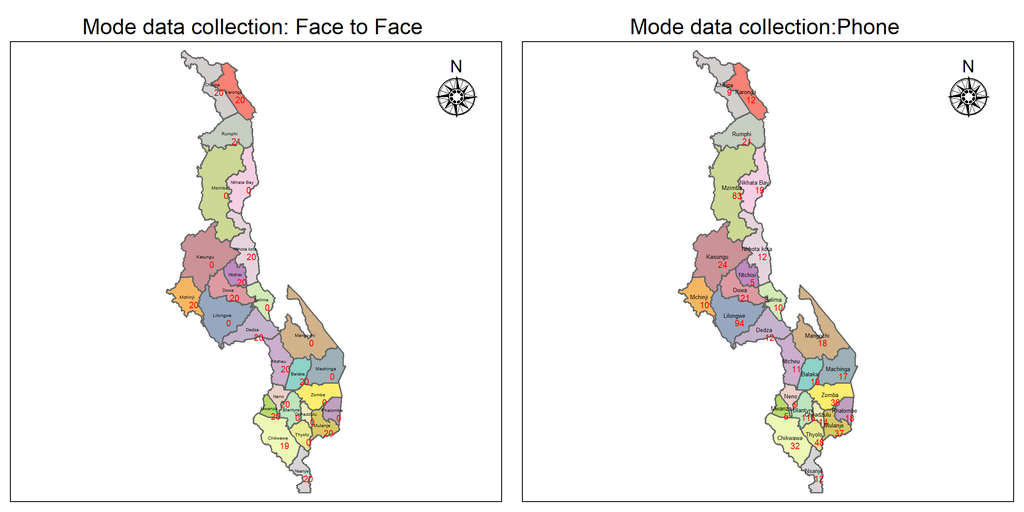

```r
mode_dis<- pvs_data|>
  select(mode,
         q4_1) |>
  rename(
    district = q4_1
  ) |>
  group_by(district, mode) |>
  count(mode) |>
  pivot_wider(
    names_from = mode,
    values_from = n
  )




mode_dis[is.na(mode_dis)]<-0


mode_dis<- mode_dis |>
  mutate(
    district= recode(
      district,
      "Mzuzu City" = "Mzimba",
      "Nkhotakota" = "Nkhota kota",
    )
  ) |>
  clean_names()


mode_dis<- mode_dis |>
  group_by(district) |>
summarise(face_to_face=sum(face_to_face),
          phone=sum(phone))


mode_dis_sf<- merge(mode_dis,
      psv_map,
      by = "district") |>
  st_as_sf()


map_face <- tm_shape(mode_dis_sf)+
   tm_borders()+
   tm_fill(
    col = "district"  )+
  tm_shape(mode_dis_sf)+
  tm_text("face_to_face",
          size = 0.4,
          col = "red",
          ymod = -0.3,
          xmod = 0.25) +
  tm_shape(mode_dis_sf)+
  tm_text("district",
          size = 0.2,
          col = "black")+
  tm_compass(
    type = "rose",
    position = c("right", "top"),
    size = 2)+
   tm_layout(
    legend.show = FALSE,
    main.title = "Mode data collection: Face to Face ",
    main.title.size = 1,
    main.title.position = "center"
  )



map_phone<- tm_shape(mode_dis_sf)+
  tm_borders()+
   tm_fill(
    col = "district"  )+

tm_shape(mode_dis_sf)+
  tm_text("phone",
          size = 0.4,
          col = "red",
          ymod = -0.3,
          xmod = 0.2) +
  tm_shape(mode_dis_sf)+
  tm_text("district",
          size = 0.25,
          col = "black")+
  tm_compass(
    type = "rose",
    position = c("right", "top"),
    size = 2)+
   tm_layout(
    legend.show = FALSE,
    main.title = "Mode data collection:Phone ",
    main.title.size = 1,
    main.title.position = "center"
  )



map_mode<- tmap_arrange(
  map_face,
  map_phone,
  ncol = 2,
  nrow = 1
)

tmap_save(map_mode,
  filename = here("maps/mode_of_data_collection_map.png"),
  width = 20,
  height = 10,
  dpi = 300,
  units = "cm"
)
```

Format 2

| **Characteristic** | **N = 1,024**<sup>1</sup> |
| --- | --- |
| Mode of Data Collection |  |
| Face to Face | 300 (29.30%) |
| Phone | 724 (70.70%) |
| Age Band |  |
| 18 to 29 | 363 (35.45%) |
| 30 to 39 | 293 (28.61%) |
| 40 to 49 | 178 (17.38%) |
| 60 to 69 | 43 (4.20%) |
| 70 to 79 | 23 (2.25%) |
| 80 or older | 124 (12.11%) |
| Sex |  |
| Female | 512 (50.00%) |
| Male | 512 (50.00%) |
| Education |  |
| No education | 69 (6.74%) |
| Primary school | 452 (44.14%) |
| Secondary school | 382 (37.30%) |
| Tertiary | 121 (11.82%) |
| Ethincity |  |
| Chichewa | 633 (61.82%) |
| Other | 184 (17.97%) |
| Tumbuka | 164 (16.02%) |
| Yao | 43 (4.20%) |
| Income Level |  |
| Less than MK52,000 | 468 (45.70%) |
| MK1,000,000 or more | 12 (1.17%) |
| MK100,000 to <MK500,000 | 245 (23.93%) |
| MK500,000 to <MK1,000,000 | 46 (4.49%) |
| MK52,000 to <MK100,000 | 224 (21.88%) |
| Refused to answer | 29 (2.83%) |

<sup>1</sup> n (%)

# Demographic by place

under this section the demographic variable will be analyzed by mode of data collection. face to face or via phone interviews. focus on district, region and residence.

format 1

| **Characteristic** | **Face to Face** N = 300<sup>1</sup> | **Phone** N = 724<sup>1</sup> |
| --- | --- | --- |
| Region |  |  |
| Central | 120 (40.00%) | 199 (27.49%) |
| Northern | 61 (20.33%) | 144 (19.89%) |
| Southern | 119 (39.67%) | 381 (52.62%) |
| District |  |  |
| Balaka | 20 (6.67%) | 19 (2.62%) |
| Blantyre | 0 (0.00%) | 116 (16.02%) |
| Chikwawa | 19 (6.33%) | 32 (4.42%) |
| Chiradzulu | 0 (0.00%) | 14 (1.93%) |
| Chitipa | 20 (6.67%) | 9 (1.24%) |
| Dedza | 20 (6.67%) | 12 (1.66%) |
| Dowa | 20 (6.67%) | 21 (2.90%) |
| Karonga | 20 (6.67%) | 12 (1.66%) |
| Kasungu | 0 (0.00%) | 24 (3.31%) |
| Lilongwe | 0 (0.00%) | 94 (12.98%) |
| Machinga | 0 (0.00%) | 17 (2.35%) |
| Mangochi | 0 (0.00%) | 18 (2.49%) |
| Mchinji | 20 (6.67%) | 10 (1.38%) |
| Mulanje | 20 (6.67%) | 37 (5.11%) |
| Mwanza | 20 (6.67%) | 5 (0.69%) |
| Mzimba | 0 (0.00%) | 53 (7.32%) |
| Mzuzu City | 0 (0.00%) | 30 (4.14%) |
| Neno | 20 (6.67%) | 9 (1.24%) |
| Nkhata Bay | 0 (0.00%) | 19 (2.62%) |
| Nkhotakota | 20 (6.67%) | 12 (1.66%) |
| Nsanje | 20 (6.67%) | 12 (1.66%) |
| Ntcheu | 20 (6.67%) | 11 (1.52%) |
| Ntchisi | 20 (6.67%) | 5 (0.69%) |
| Phalombe | 0 (0.00%) | 18 (2.49%) |
| Rumphi | 21 (7.00%) | 21 (2.90%) |
| Salima | 0 (0.00%) | 10 (1.38%) |
| Thyolo | 0 (0.00%) | 48 (6.63%) |
| Zomba | 0 (0.00%) | 36 (4.97%) |
| Residence |  |  |
| Rural | 296 (98.67%) | 435 (60.08%) |
| Urban | 4 (1.33%) | 289 (39.92%) |

<sup>1</sup> n (%)

format 2

| **Characteristic** | **N = 1,024**<sup>1</sup> |
| --- | --- |
| Mode of Data Collection |  |
| Face to Face | 300 (29.30%) |
| Phone | 724 (70.70%) |
| Region |  |
| Central | 319 (31.15%) |
| Northern | 205 (20.02%) |
| Southern | 500 (48.83%) |
| District |  |
| Balaka | 39 (3.81%) |
| Blantyre | 116 (11.33%) |
| Chikwawa | 51 (4.98%) |
| Chiradzulu | 14 (1.37%) |
| Chitipa | 29 (2.83%) |
| Dedza | 32 (3.13%) |
| Dowa | 41 (4.00%) |
| Karonga | 32 (3.13%) |
| Kasungu | 24 (2.34%) |
| Lilongwe | 94 (9.18%) |
| Machinga | 17 (1.66%) |
| Mangochi | 18 (1.76%) |
| Mchinji | 30 (2.93%) |
| Mulanje | 57 (5.57%) |
| Mwanza | 25 (2.44%) |
| Mzimba | 53 (5.18%) |
| Mzuzu City | 30 (2.93%) |
| Neno | 29 (2.83%) |
| Nkhata Bay | 19 (1.86%) |
| Nkhotakota | 32 (3.13%) |
| Nsanje | 32 (3.13%) |
| Ntcheu | 31 (3.03%) |
| Ntchisi | 25 (2.44%) |
| Phalombe | 18 (1.76%) |
| Rumphi | 42 (4.10%) |
| Salima | 10 (0.98%) |
| Thyolo | 48 (4.69%) |
| Zomba | 36 (3.52%) |
| Residence |  |
| Rural | 731 (71.39%) |
| Urban | 293 (28.61%) |

<sup>1</sup> n (%)

# crosstabs of demographic variables and type of health facility:

was this a public or private health facility? Q32 by demographic of person.

```
## 187 missing rows in the "q32" column have been removed.
```

| **Characteristic** | **Faith-based or NGO** N = 61<sup>1</sup> | **Private** N = 113<sup>1</sup> | **Public** N = 655<sup>1</sup> | **Refused to answer** N = 8<sup>1</sup> |
| --- | --- | --- | --- | --- |
| Mode of data collection |  |  |  |  |
| Face to Face | 8 (13.11%) | 6 (5.31%) | 248 (37.86%) | 2 (25.00%) |
| Phone | 53 (86.89%) | 107 (94.69%) | 407 (62.14%) | 6 (75.00%) |
| Age Band |  |  |  |  |
| 18 to 29 | 15 (24.59%) | 50 (44.25%) | 219 (33.44%) | 5 (62.50%) |
| 30 to 39 | 20 (32.79%) | 30 (26.55%) | 201 (30.69%) | 1 (12.50%) |
| 40 to 49 | 11 (18.03%) | 21 (18.58%) | 118 (18.02%) | 0 (0.00%) |
| 60 to 69 | 3 (4.92%) | 3 (2.65%) | 29 (4.43%) | 1 (12.50%) |
| 70 to 79 | 1 (1.64%) | 0 (0.00%) | 10 (1.53%) | 1 (12.50%) |
| 80 or older | 11 (18.03%) | 9 (7.96%) | 78 (11.91%) | 0 (0.00%) |
| Sex |  |  |  |  |
| Female | 29 (47.54%) | 43 (38.05%) | 367 (56.03%) | 4 (50.00%) |
| Male | 32 (52.46%) | 70 (61.95%) | 288 (43.97%) | 4 (50.00%) |
| Education |  |  |  |  |
| No education | 5 (8.20%) | 1 (0.88%) | 41 (6.26%) | 1 (12.50%) |
| Primary school | 22 (36.07%) | 36 (31.86%) | 314 (47.94%) | 3 (37.50%) |
| Secondary school | 25 (40.98%) | 46 (40.71%) | 239 (36.49%) | 3 (37.50%) |
| Tertiary | 9 (14.75%) | 30 (26.55%) | 61 (9.31%) | 1 (12.50%) |
| Ethinicity |  |  |  |  |
| Chichewa | 44 (72.13%) | 73 (64.60%) | 398 (60.76%) | 3 (37.50%) |
| Other | 8 (13.11%) | 23 (20.35%) | 108 (16.49%) | 2 (25.00%) |
| Tumbuka | 6 (9.84%) | 15 (13.27%) | 118 (18.02%) | 3 (37.50%) |
| Yao | 3 (4.92%) | 2 (1.77%) | 31 (4.73%) | 0 (0.00%) |
| Income Level |  |  |  |  |
| Less than MK52,000 | 29 (47.54%) | 34 (30.09%) | 333 (50.84%) | 2 (25.00%) |
| MK1,000,000 or more | 1 (1.64%) | 4 (3.54%) | 2 (0.31%) | 0 (0.00%) |
| MK100,000 to <MK500,000 | 14 (22.95%) | 36 (31.86%) | 143 (21.83%) | 3 (37.50%) |
| MK500,000 to <MK1,000,000 | 2 (3.28%) | 10 (8.85%) | 24 (3.66%) | 0 (0.00%) |
| MK52,000 to <MK100,000 | 15 (24.59%) | 26 (23.01%) | 140 (21.37%) | 3 (37.50%) |
| Refused to answer | 0 (0.00%) | 3 (2.65%) | 13 (1.98%) | 0 (0.00%) |

<sup>1</sup> n (%)

was this a public or private health facility? Q32 by demographic of district, residence and region.

```
## 187 missing rows in the "q32" column have been removed.
```

| **Characteristic** | **Faith-based or NGO** N = 61<sup>1</sup> | **Private** N = 113<sup>1</sup> | **Public** N = 655<sup>1</sup> | **Refused to answer** N = 8<sup>1</sup> |
| --- | --- | --- | --- | --- |
| Mode of data collection |  |  |  |  |
| Face to Face | 8 (13.11%) | 6 (5.31%) | 248 (37.86%) | 2 (25.00%) |
| Phone | 53 (86.89%) | 107 (94.69%) | 407 (62.14%) | 6 (75.00%) |
| Region |  |  |  |  |
| Central | 27 (44.26%) | 43 (38.05%) | 192 (29.31%) | 2 (25.00%) |
| Northern | 7 (11.48%) | 19 (16.81%) | 143 (21.83%) | 5 (62.50%) |
| Southern | 27 (44.26%) | 51 (45.13%) | 320 (48.85%) | 1 (12.50%) |
| District |  |  |  |  |
| Balaka | 3 (4.92%) | 4 (3.54%) | 29 (4.43%) | 0 (0.00%) |
| Blantyre | 5 (8.20%) | 10 (8.85%) | 70 (10.69%) | 1 (12.50%) |
| Chikwawa | 6 (9.84%) | 6 (5.31%) | 22 (3.36%) | 0 (0.00%) |
| Chiradzulu | 0 (0.00%) | 2 (1.77%) | 9 (1.37%) | 0 (0.00%) |
| Chitipa | 0 (0.00%) | 2 (1.77%) | 24 (3.66%) | 1 (12.50%) |
| Dedza | 4 (6.56%) | 0 (0.00%) | 24 (3.66%) | 0 (0.00%) |
| Dowa | 1 (1.64%) | 4 (3.54%) | 30 (4.58%) | 0 (0.00%) |
| Karonga | 0 (0.00%) | 1 (0.88%) | 25 (3.82%) | 1 (12.50%) |
| Kasungu | 1 (1.64%) | 4 (3.54%) | 13 (1.98%) | 0 (0.00%) |
| Lilongwe | 9 (14.75%) | 22 (19.47%) | 37 (5.65%) | 0 (0.00%) |
| Machinga | 0 (0.00%) | 2 (1.77%) | 13 (1.98%) | 0 (0.00%) |
| Mangochi | 3 (4.92%) | 2 (1.77%) | 11 (1.68%) | 0 (0.00%) |
| Mchinji | 4 (6.56%) | 2 (1.77%) | 23 (3.51%) | 0 (0.00%) |
| Mulanje | 4 (6.56%) | 3 (2.65%) | 41 (6.26%) | 0 (0.00%) |
| Mwanza | 0 (0.00%) | 2 (1.77%) | 20 (3.05%) | 0 (0.00%) |
| Mzimba | 4 (6.56%) | 4 (3.54%) | 32 (4.89%) | 2 (25.00%) |
| Mzuzu City | 2 (3.28%) | 6 (5.31%) | 15 (2.29%) | 0 (0.00%) |
| Neno | 0 (0.00%) | 0 (0.00%) | 26 (3.97%) | 0 (0.00%) |
| Nkhata Bay | 1 (1.64%) | 5 (4.42%) | 11 (1.68%) | 0 (0.00%) |
| Nkhotakota | 0 (0.00%) | 3 (2.65%) | 23 (3.51%) | 1 (12.50%) |
| Nsanje | 1 (1.64%) | 1 (0.88%) | 17 (2.60%) | 0 (0.00%) |
| Ntcheu | 4 (6.56%) | 5 (4.42%) | 19 (2.90%) | 1 (12.50%) |
| Ntchisi | 3 (4.92%) | 1 (0.88%) | 18 (2.75%) | 0 (0.00%) |
| Phalombe | 0 (0.00%) | 1 (0.88%) | 10 (1.53%) | 0 (0.00%) |
| Rumphi | 0 (0.00%) | 1 (0.88%) | 36 (5.50%) | 1 (12.50%) |
| Salima | 1 (1.64%) | 2 (1.77%) | 5 (0.76%) | 0 (0.00%) |
| Thyolo | 4 (6.56%) | 10 (8.85%) | 28 (4.27%) | 0 (0.00%) |
| Zomba | 1 (1.64%) | 8 (7.08%) | 24 (3.66%) | 0 (0.00%) |
| Residence |  |  |  |  |
| Rural | 46 (75.41%) | 68 (60.18%) | 501 (76.49%) | 6 (75.00%) |
| Urban | 15 (24.59%) | 45 (39.82%) | 154 (23.51%) | 2 (25.00%) |

<sup>1</sup> n (%)

# crosstabs of demographic variables and staying overnight at health facility:

in the past 12 month did you stay overnight? q26 by demographic of person.

| **Characteristic** | **No** N = 909<sup>1</sup> | **Refused to answer** N = 1<sup>1</sup> | **Yes** N = 114<sup>1</sup> |
| --- | --- | --- | --- |
| Mode of data collection |  |  |  |
| Face to Face | 255 (28.05%) | 0 (0.00%) | 45 (39.47%) |
| Phone | 654 (71.95%) | 1 (100.00%) | 69 (60.53%) |
| Age Band |  |  |  |
| 18 to 29 | 316 (34.76%) | 0 (0.00%) | 47 (41.23%) |
| 30 to 39 | 259 (28.49%) | 1 (100.00%) | 33 (28.95%) |
| 40 to 49 | 164 (18.04%) | 0 (0.00%) | 14 (12.28%) |
| 60 to 69 | 42 (4.62%) | 0 (0.00%) | 1 (0.88%) |
| 70 to 79 | 20 (2.20%) | 0 (0.00%) | 3 (2.63%) |
| 80 or older | 108 (11.88%) | 0 (0.00%) | 16 (14.04%) |
| Sex |  |  |  |
| Female | 438 (48.18%) | 1 (100.00%) | 73 (64.04%) |
| Male | 471 (51.82%) | 0 (0.00%) | 41 (35.96%) |
| Education |  |  |  |
| No education | 62 (6.82%) | 0 (0.00%) | 7 (6.14%) |
| Primary school | 393 (43.23%) | 0 (0.00%) | 59 (51.75%) |
| Secondary school | 346 (38.06%) | 1 (100.00%) | 35 (30.70%) |
| Tertiary | 108 (11.88%) | 0 (0.00%) | 13 (11.40%) |
| Ethinicity |  |  |  |
| Chichewa | 561 (61.72%) | 1 (100.00%) | 71 (62.28%) |
| Other | 165 (18.15%) | 0 (0.00%) | 19 (16.67%) |
| Tumbuka | 143 (15.73%) | 0 (0.00%) | 21 (18.42%) |
| Yao | 40 (4.40%) | 0 (0.00%) | 3 (2.63%) |
| Income Level |  |  |  |
| Less than MK52,000 | 404 (44.44%) | 0 (0.00%) | 64 (56.14%) |
| MK1,000,000 or more | 11 (1.21%) | 0 (0.00%) | 1 (0.88%) |
| MK100,000 to <MK500,000 | 222 (24.42%) | 0 (0.00%) | 23 (20.18%) |
| MK500,000 to <MK1,000,000 | 43 (4.73%) | 0 (0.00%) | 3 (2.63%) |
| MK52,000 to <MK100,000 | 203 (22.33%) | 1 (100.00%) | 20 (17.54%) |
| Refused to answer | 26 (2.86%) | 0 (0.00%) | 3 (2.63%) |

<sup>1</sup> n (%)

# in the past 12 month did you stay overnight? q26 by demographic of district, residence and region.

| **Characteristic** | **No** N = 909<sup>1</sup> | **Refused to answer** N = 1<sup>1</sup> | **Yes** N = 114<sup>1</sup> |
| --- | --- | --- | --- |
| Region |  |  |  |
| Central | 288 (31.68%) | 0 (0.00%) | 31 (27.19%) |
| Northern | 178 (19.58%) | 1 (100.00%) | 26 (22.81%) |
| Southern | 443 (48.73%) | 0 (0.00%) | 57 (50.00%) |
| District |  |  |  |
| Balaka | 35 (3.85%) | 0 (0.00%) | 4 (3.51%) |
| Blantyre | 103 (11.33%) | 0 (0.00%) | 13 (11.40%) |
| Chikwawa | 45 (4.95%) | 0 (0.00%) | 6 (5.26%) |
| Chiradzulu | 14 (1.54%) | 0 (0.00%) | 0 (0.00%) |
| Chitipa | 24 (2.64%) | 0 (0.00%) | 5 (4.39%) |
| Dedza | 30 (3.30%) | 0 (0.00%) | 2 (1.75%) |
| Dowa | 38 (4.18%) | 0 (0.00%) | 3 (2.63%) |
| Karonga | 28 (3.08%) | 0 (0.00%) | 4 (3.51%) |
| Kasungu | 24 (2.64%) | 0 (0.00%) | 0 (0.00%) |
| Lilongwe | 85 (9.35%) | 0 (0.00%) | 9 (7.89%) |
| Machinga | 13 (1.43%) | 0 (0.00%) | 4 (3.51%) |
| Mangochi | 14 (1.54%) | 0 (0.00%) | 4 (3.51%) |
| Mchinji | 26 (2.86%) | 0 (0.00%) | 4 (3.51%) |
| Mulanje | 49 (5.39%) | 0 (0.00%) | 8 (7.02%) |
| Mwanza | 23 (2.53%) | 0 (0.00%) | 2 (1.75%) |
| Mzimba | 49 (5.39%) | 0 (0.00%) | 4 (3.51%) |
| Mzuzu City | 27 (2.97%) | 1 (100.00%) | 2 (1.75%) |
| Neno | 25 (2.75%) | 0 (0.00%) | 4 (3.51%) |
| Nkhata Bay | 18 (1.98%) | 0 (0.00%) | 1 (0.88%) |
| Nkhotakota | 31 (3.41%) | 0 (0.00%) | 1 (0.88%) |
| Nsanje | 30 (3.30%) | 0 (0.00%) | 2 (1.75%) |
| Ntcheu | 24 (2.64%) | 0 (0.00%) | 7 (6.14%) |
| Ntchisi | 20 (2.20%) | 0 (0.00%) | 5 (4.39%) |
| Phalombe | 15 (1.65%) | 0 (0.00%) | 3 (2.63%) |
| Rumphi | 32 (3.52%) | 0 (0.00%) | 10 (8.77%) |
| Salima | 10 (1.10%) | 0 (0.00%) | 0 (0.00%) |
| Thyolo | 43 (4.73%) | 0 (0.00%) | 5 (4.39%) |
| Zomba | 34 (3.74%) | 0 (0.00%) | 2 (1.75%) |
| Residence |  |  |  |
| Rural | 644 (70.85%) | 0 (0.00%) | 87 (76.32%) |
| Urban | 265 (29.15%) | 1 (100.00%) | 27 (23.68%) |

<sup>1</sup> n (%)

# crosstabs of demographic variable number 3

## q27a demographic variabel of person

Have you had your blood pressure measured from any healthcare provider

| **Characteristic** | **Don’t know** N = 3<sup>1</sup> | **No** N = 531<sup>1</sup> | **Yes** N = 490<sup>1</sup> |
| --- | --- | --- | --- |
| Mode of data collection |  |  |  |
| Face to Face | 2 (66.67%) | 153 (28.81%) | 145 (29.59%) |
| Phone | 1 (33.33%) | 378 (71.19%) | 345 (70.41%) |
| Age Band |  |  |  |
| 18 to 29 | 1 (33.33%) | 217 (40.87%) | 145 (29.59%) |
| 30 to 39 | 2 (66.67%) | 144 (27.12%) | 147 (30.00%) |
| 40 to 49 | 0 (0.00%) | 77 (14.50%) | 101 (20.61%) |
| 60 to 69 | 0 (0.00%) | 23 (4.33%) | 20 (4.08%) |
| 70 to 79 | 0 (0.00%) | 12 (2.26%) | 11 (2.24%) |
| 80 or older | 0 (0.00%) | 58 (10.92%) | 66 (13.47%) |
| Sex |  |  |  |
| Female | 3 (100.00%) | 227 (42.75%) | 282 (57.55%) |
| Male | 0 (0.00%) | 304 (57.25%) | 208 (42.45%) |
| Education |  |  |  |
| No education | 1 (33.33%) | 40 (7.53%) | 28 (5.71%) |
| Primary school | 1 (33.33%) | 234 (44.07%) | 217 (44.29%) |
| Secondary school | 1 (33.33%) | 206 (38.79%) | 175 (35.71%) |
| Tertiary | 0 (0.00%) | 51 (9.60%) | 70 (14.29%) |
| Ethinicity |  |  |  |
| Chichewa | 3 (100.00%) | 330 (62.15%) | 300 (61.22%) |
| Other | 0 (0.00%) | 103 (19.40%) | 81 (16.53%) |
| Tumbuka | 0 (0.00%) | 73 (13.75%) | 91 (18.57%) |
| Yao | 0 (0.00%) | 25 (4.71%) | 18 (3.67%) |
| Income Level |  |  |  |
| Less than MK52,000 | 3 (100.00%) | 248 (46.70%) | 217 (44.29%) |
| MK1,000,000 or more | 0 (0.00%) | 5 (0.94%) | 7 (1.43%) |
| MK100,000 to <MK500,000 | 0 (0.00%) | 117 (22.03%) | 128 (26.12%) |
| MK500,000 to <MK1,000,000 | 0 (0.00%) | 18 (3.39%) | 28 (5.71%) |
| MK52,000 to <MK100,000 | 0 (0.00%) | 127 (23.92%) | 97 (19.80%) |
| Refused to answer | 0 (0.00%) | 16 (3.01%) | 13 (2.65%) |

<sup>1</sup> n (%)

## q27a demographic variabel of district, residence and region

Have you had your blood pressure measured from any healthcare provider

| **Characteristic** | **Don’t know** N = 3<sup>1</sup> | **No** N = 531<sup>1</sup> | **Yes** N = 490<sup>1</sup> |
| --- | --- | --- | --- |
| Region |  |  |  |
| Central | 2 (66.67%) | 187 (35.22%) | 130 (26.53%) |
| Northern | 0 (0.00%) | 93 (17.51%) | 112 (22.86%) |
| Southern | 1 (33.33%) | 251 (47.27%) | 248 (50.61%) |
| District |  |  |  |
| Balaka | 0 (0.00%) | 18 (3.39%) | 21 (4.29%) |
| Blantyre | 0 (0.00%) | 54 (10.17%) | 62 (12.65%) |
| Chikwawa | 0 (0.00%) | 32 (6.03%) | 19 (3.88%) |
| Chiradzulu | 0 (0.00%) | 9 (1.69%) | 5 (1.02%) |
| Chitipa | 0 (0.00%) | 14 (2.64%) | 15 (3.06%) |
| Dedza | 0 (0.00%) | 16 (3.01%) | 16 (3.27%) |
| Dowa | 0 (0.00%) | 27 (5.08%) | 14 (2.86%) |
| Karonga | 0 (0.00%) | 15 (2.82%) | 17 (3.47%) |
| Kasungu | 0 (0.00%) | 17 (3.20%) | 7 (1.43%) |
| Lilongwe | 1 (33.33%) | 56 (10.55%) | 37 (7.55%) |
| Machinga | 0 (0.00%) | 10 (1.88%) | 7 (1.43%) |
| Mangochi | 0 (0.00%) | 6 (1.13%) | 12 (2.45%) |
| Mchinji | 1 (33.33%) | 20 (3.77%) | 9 (1.84%) |
| Mulanje | 0 (0.00%) | 26 (4.90%) | 31 (6.33%) |
| Mwanza | 0 (0.00%) | 9 (1.69%) | 16 (3.27%) |
| Mzimba | 0 (0.00%) | 23 (4.33%) | 30 (6.12%) |
| Mzuzu City | 0 (0.00%) | 14 (2.64%) | 16 (3.27%) |
| Neno | 1 (33.33%) | 9 (1.69%) | 19 (3.88%) |
| Nkhata Bay | 0 (0.00%) | 8 (1.51%) | 11 (2.24%) |
| Nkhotakota | 0 (0.00%) | 18 (3.39%) | 14 (2.86%) |
| Nsanje | 0 (0.00%) | 24 (4.52%) | 8 (1.63%) |
| Ntcheu | 0 (0.00%) | 16 (3.01%) | 15 (3.06%) |
| Ntchisi | 0 (0.00%) | 10 (1.88%) | 15 (3.06%) |
| Phalombe | 0 (0.00%) | 7 (1.32%) | 11 (2.24%) |
| Rumphi | 0 (0.00%) | 19 (3.58%) | 23 (4.69%) |
| Salima | 0 (0.00%) | 7 (1.32%) | 3 (0.61%) |
| Thyolo | 0 (0.00%) | 26 (4.90%) | 22 (4.49%) |
| Zomba | 0 (0.00%) | 21 (3.95%) | 15 (3.06%) |
| Residence |  |  |  |
| Rural | 2 (66.67%) | 381 (71.75%) | 348 (71.02%) |
| Urban | 1 (33.33%) | 150 (28.25%) | 142 (28.98%) |

<sup>1</sup> n (%)

## q27b demographic variabel of person

```
## 512 missing rows in the "q27b" column have been removed.
```

Have you received a mammogram from any healthcare provider

| **Characteristic** | **No** N = 464<sup>1</sup> | **Yes** N = 48<sup>1</sup> |
| --- | --- | --- |
| Mode of data collection |  |  |
| Face to Face | 181 (39.01%) | 20 (41.67%) |
| Phone | 283 (60.99%) | 28 (58.33%) |
| Age Band |  |  |
| 18 to 29 | 165 (35.56%) | 14 (29.17%) |
| 30 to 39 | 129 (27.80%) | 14 (29.17%) |
| 40 to 49 | 88 (18.97%) | 10 (20.83%) |
| 60 to 69 | 23 (4.96%) | 0 (0.00%) |
| 70 to 79 | 6 (1.29%) | 1 (2.08%) |
| 80 or older | 53 (11.42%) | 9 (18.75%) |
| Sex |  |  |
| Female | 464 (100.00%) | 48 (100.00%) |
| Male | 0 (0.00%) | 0 (0.00%) |
| Education |  |  |
| No education | 42 (9.05%) | 3 (6.25%) |
| Primary school | 240 (51.72%) | 27 (56.25%) |
| Secondary school | 139 (29.96%) | 13 (27.08%) |
| Tertiary | 43 (9.27%) | 5 (10.42%) |
| Ethinicity |  |  |
| Chichewa | 288 (62.07%) | 23 (47.92%) |
| Other | 90 (19.40%) | 14 (29.17%) |
| Tumbuka | 67 (14.44%) | 11 (22.92%) |
| Yao | 19 (4.09%) | 0 (0.00%) |
| Income Level |  |  |
| Less than MK52,000 | 253 (54.53%) | 22 (45.83%) |
| MK1,000,000 or more | 2 (0.43%) | 2 (4.17%) |
| MK100,000 to <MK500,000 | 92 (19.83%) | 6 (12.50%) |
| MK500,000 to <MK1,000,000 | 16 (3.45%) | 3 (6.25%) |
| MK52,000 to <MK100,000 | 91 (19.61%) | 15 (31.25%) |
| Refused to answer | 10 (2.16%) | 0 (0.00%) |

<sup>1</sup> n (%)

## q27b demographic variabel of district, residence and region

```
## 512 missing rows in the "q27b" column have been removed.
```

Have you received a mammogram from any healthcare provider

| **Characteristic** | **No** N = 464<sup>1</sup> | **Yes** N = 48<sup>1</sup> |
| --- | --- | --- |
| Region |  |  |
| Central | 146 (31.47%) | 10 (20.83%) |
| Northern | 83 (17.89%) | 13 (27.08%) |
| Southern | 235 (50.65%) | 25 (52.08%) |
| District |  |  |
| Balaka | 29 (6.25%) | 0 (0.00%) |
| Blantyre | 54 (11.64%) | 7 (14.58%) |
| Chikwawa | 15 (3.23%) | 1 (2.08%) |
| Chiradzulu | 5 (1.08%) | 0 (0.00%) |
| Chitipa | 16 (3.45%) | 0 (0.00%) |
| Dedza | 15 (3.23%) | 2 (4.17%) |
| Dowa | 28 (6.03%) | 1 (2.08%) |
| Karonga | 12 (2.59%) | 3 (6.25%) |
| Kasungu | 7 (1.51%) | 1 (2.08%) |
| Lilongwe | 34 (7.33%) | 2 (4.17%) |
| Machinga | 7 (1.51%) | 0 (0.00%) |
| Mangochi | 8 (1.72%) | 0 (0.00%) |
| Mchinji | 15 (3.23%) | 2 (4.17%) |
| Mulanje | 26 (5.60%) | 4 (8.33%) |
| Mwanza | 20 (4.31%) | 2 (4.17%) |
| Mzimba | 22 (4.74%) | 1 (2.08%) |
| Mzuzu City | 11 (2.37%) | 3 (6.25%) |
| Neno | 20 (4.31%) | 3 (6.25%) |
| Nkhata Bay | 5 (1.08%) | 1 (2.08%) |
| Nkhotakota | 17 (3.66%) | 0 (0.00%) |
| Nsanje | 14 (3.02%) | 2 (4.17%) |
| Ntcheu | 13 (2.80%) | 1 (2.08%) |
| Ntchisi | 14 (3.02%) | 1 (2.08%) |
| Phalombe | 3 (0.65%) | 3 (6.25%) |
| Rumphi | 17 (3.66%) | 5 (10.42%) |
| Salima | 3 (0.65%) | 0 (0.00%) |
| Thyolo | 21 (4.53%) | 3 (6.25%) |
| Zomba | 13 (2.80%) | 0 (0.00%) |
| Residence |  |  |
| Rural | 351 (75.65%) | 37 (77.08%) |
| Urban | 113 (24.35%) | 11 (22.92%) |

<sup>1</sup> n (%)

## q27c demographic variabel of person: Receive Cervical Cancer Screening

| **Characteristic** | **No** N = 347<sup>1</sup> | **Yes** N = 165<sup>1</sup> |
| --- | --- | --- |
| Mode of data collection |  |  |
| Face to Face | 144 (41.50%) | 57 (34.55%) |
| Phone | 203 (58.50%) | 108 (65.45%) |
| Age Band |  |  |
| 18 to 29 | 140 (40.35%) | 39 (23.64%) |
| 30 to 39 | 89 (25.65%) | 54 (32.73%) |
| 40 to 49 | 57 (16.43%) | 41 (24.85%) |
| 60 to 69 | 17 (4.90%) | 6 (3.64%) |
| 70 to 79 | 7 (2.02%) | 0 (0.00%) |
| 80 or older | 37 (10.66%) | 25 (15.15%) |
| Education |  |  |
| No education | 33 (9.51%) | 12 (7.27%) |
| Primary school | 173 (49.86%) | 94 (56.97%) |
| Secondary school | 106 (30.55%) | 46 (27.88%) |
| Tertiary | 35 (10.09%) | 13 (7.88%) |
| Ethinicity |  |  |
| Chichewa | 213 (61.38%) | 98 (59.39%) |
| Other | 70 (20.17%) | 34 (20.61%) |
| Tumbuka | 52 (14.99%) | 26 (15.76%) |
| Yao | 12 (3.46%) | 7 (4.24%) |
| Income Level |  |  |
| Less than MK52,000 | 196 (56.48%) | 79 (47.88%) |
| MK1,000,000 or more | 2 (0.58%) | 2 (1.21%) |
| MK100,000 to <MK500,000 | 63 (18.16%) | 35 (21.21%) |
| MK500,000 to <MK1,000,000 | 12 (3.46%) | 7 (4.24%) |
| MK52,000 to <MK100,000 | 66 (19.02%) | 40 (24.24%) |
| Refused to answer | 8 (2.31%) | 2 (1.21%) |

<sup>1</sup> n (%)

## q27c demographic variabel of district, residence and region cervical cancer screening

```
## 512 missing rows in the "q27c" column have been removed.
```

Have you received cervical cancer screening from any healthcare provide

| **Characteristic** | **No** N = 347<sup>1</sup> | **Yes** N = 165<sup>1</sup> |
| --- | --- | --- |
| Region |  |  |
| Central | 112 (32.28%) | 44 (26.67%) |
| Northern | 65 (18.73%) | 31 (18.79%) |
| Southern | 170 (48.99%) | 90 (54.55%) |
| District |  |  |
| Balaka | 21 (6.05%) | 8 (4.85%) |
| Blantyre | 37 (10.66%) | 24 (14.55%) |
| Chikwawa | 13 (3.75%) | 3 (1.82%) |
| Chiradzulu | 3 (0.86%) | 2 (1.21%) |
| Chitipa | 14 (4.03%) | 2 (1.21%) |
| Dedza | 11 (3.17%) | 6 (3.64%) |
| Dowa | 19 (5.48%) | 10 (6.06%) |
| Karonga | 12 (3.46%) | 3 (1.82%) |
| Kasungu | 5 (1.44%) | 3 (1.82%) |
| Lilongwe | 30 (8.65%) | 6 (3.64%) |
| Machinga | 7 (2.02%) | 0 (0.00%) |
| Mangochi | 5 (1.44%) | 3 (1.82%) |
| Mchinji | 10 (2.88%) | 7 (4.24%) |
| Mulanje | 21 (6.05%) | 9 (5.45%) |
| Mwanza | 12 (3.46%) | 10 (6.06%) |
| Mzimba | 18 (5.19%) | 5 (3.03%) |
| Mzuzu City | 6 (1.73%) | 8 (4.85%) |
| Neno | 12 (3.46%) | 11 (6.67%) |
| Nkhata Bay | 2 (0.58%) | 4 (2.42%) |
| Nkhotakota | 15 (4.32%) | 2 (1.21%) |
| Nsanje | 12 (3.46%) | 4 (2.42%) |
| Ntcheu | 9 (2.59%) | 5 (3.03%) |
| Ntchisi | 10 (2.88%) | 5 (3.03%) |
| Phalombe | 2 (0.58%) | 4 (2.42%) |
| Rumphi | 13 (3.75%) | 9 (5.45%) |
| Salima | 3 (0.86%) | 0 (0.00%) |
| Thyolo | 15 (4.32%) | 9 (5.45%) |
| Zomba | 10 (2.88%) | 3 (1.82%) |
| Residence |  |  |
| Rural | 259 (74.64%) | 129 (78.18%) |
| Urban | 88 (25.36%) | 36 (21.82%) |

<sup>1</sup> n (%)

## q27d Q27d. Have you had your eyes or vision checked from any healthcare provide.

Have you had your eyes or vision checked from any healthcare provider

| **Characteristic** | **Don’t know** N = 3<sup>1</sup> | **No** N = 847<sup>1</sup> | **Yes** N = 174<sup>1</sup> |
| --- | --- | --- | --- |
| Age Band |  |  |  |
| 18 to 29 | 1 (33.33%) | 312 (36.84%) | 50 (28.74%) |
| 30 to 39 | 1 (33.33%) | 246 (29.04%) | 46 (26.44%) |
| 40 to 49 | 1 (33.33%) | 141 (16.65%) | 36 (20.69%) |
| 60 to 69 | 0 (0.00%) | 28 (3.31%) | 15 (8.62%) |
| 70 to 79 | 0 (0.00%) | 21 (2.48%) | 2 (1.15%) |
| 80 or older | 0 (0.00%) | 99 (11.69%) | 25 (14.37%) |
| Sex |  |  |  |
| Female | 1 (33%) | 438 (52%) | 73 (42%) |
| Male | 2 (67%) | 409 (48%) | 101 (58%) |
| Education |  |  |  |
| No education | 0 (0.00%) | 60 (7.08%) | 9 (5.17%) |
| Primary school | 2 (66.67%) | 382 (45.10%) | 68 (39.08%) |
| Secondary school | 1 (33.33%) | 319 (37.66%) | 62 (35.63%) |
| Tertiary | 0 (0.00%) | 86 (10.15%) | 35 (20.11%) |
| Ethinicity |  |  |  |
| Chichewa | 2 (66.67%) | 526 (62.10%) | 105 (60.34%) |
| Other | 0 (0.00%) | 153 (18.06%) | 31 (17.82%) |
| Tumbuka | 1 (33.33%) | 135 (15.94%) | 28 (16.09%) |
| Yao | 0 (0.00%) | 33 (3.90%) | 10 (5.75%) |
| Income Level |  |  |  |
| Less than MK52,000 | 1 (33.33%) | 388 (45.81%) | 79 (45.40%) |
| MK1,000,000 or more | 0 (0.00%) | 10 (1.18%) | 2 (1.15%) |
| MK100,000 to <MK500,000 | 1 (33.33%) | 205 (24.20%) | 39 (22.41%) |
| MK500,000 to <MK1,000,000 | 0 (0.00%) | 33 (3.90%) | 13 (7.47%) |
| MK52,000 to <MK100,000 | 1 (33.33%) | 190 (22.43%) | 33 (18.97%) |
| Refused to answer | 0 (0.00%) | 21 (2.48%) | 8 (4.60%) |

<sup>1</sup> n (%)

## q27d Q27d. Have you had your eyes or vision checked from any healthcare provide.by district, region, residence and health facility.

| **Characteristic** | **Don’t know** N = 3<sup>1</sup> | **No** N = 847<sup>1</sup> | **Yes** N = 174<sup>1</sup> |
| --- | --- | --- | --- |
| Region |  |  |  |
| Central | 1 (33.33%) | 278 (32.82%) | 40 (22.99%) |
| Northern | 1 (33.33%) | 172 (20.31%) | 32 (18.39%) |
| Southern | 1 (33.33%) | 397 (46.87%) | 102 (58.62%) |
| District |  |  |  |
| Balaka | 0 (0.00%) | 29 (3.42%) | 10 (5.75%) |
| Blantyre | 0 (0.00%) | 89 (10.51%) | 27 (15.52%) |
| Chikwawa | 0 (0.00%) | 42 (4.96%) | 9 (5.17%) |
| Chiradzulu | 0 (0.00%) | 12 (1.42%) | 2 (1.15%) |
| Chitipa | 0 (0.00%) | 28 (3.31%) | 1 (0.57%) |
| Dedza | 0 (0.00%) | 29 (3.42%) | 3 (1.72%) |
| Dowa | 1 (33.33%) | 35 (4.13%) | 5 (2.87%) |
| Karonga | 0 (0.00%) | 27 (3.19%) | 5 (2.87%) |
| Kasungu | 0 (0.00%) | 23 (2.72%) | 1 (0.57%) |
| Lilongwe | 0 (0.00%) | 76 (8.97%) | 18 (10.34%) |
| Machinga | 0 (0.00%) | 15 (1.77%) | 2 (1.15%) |
| Mangochi | 0 (0.00%) | 15 (1.77%) | 3 (1.72%) |
| Mchinji | 0 (0.00%) | 26 (3.07%) | 4 (2.30%) |
| Mulanje | 0 (0.00%) | 45 (5.31%) | 12 (6.90%) |
| Mwanza | 0 (0.00%) | 20 (2.36%) | 5 (2.87%) |
| Mzimba | 0 (0.00%) | 45 (5.31%) | 8 (4.60%) |
| Mzuzu City | 1 (33.33%) | 22 (2.60%) | 7 (4.02%) |
| Neno | 0 (0.00%) | 23 (2.72%) | 6 (3.45%) |
| Nkhata Bay | 0 (0.00%) | 16 (1.89%) | 3 (1.72%) |
| Nkhotakota | 0 (0.00%) | 30 (3.54%) | 2 (1.15%) |
| Nsanje | 0 (0.00%) | 28 (3.31%) | 4 (2.30%) |
| Ntcheu | 0 (0.00%) | 25 (2.95%) | 6 (3.45%) |
| Ntchisi | 0 (0.00%) | 25 (2.95%) | 0 (0.00%) |
| Phalombe | 0 (0.00%) | 13 (1.53%) | 5 (2.87%) |
| Rumphi | 0 (0.00%) | 34 (4.01%) | 8 (4.60%) |
| Salima | 0 (0.00%) | 9 (1.06%) | 1 (0.57%) |
| Thyolo | 0 (0.00%) | 39 (4.60%) | 9 (5.17%) |
| Zomba | 1 (33.33%) | 27 (3.19%) | 8 (4.60%) |
| Residence |  |  |  |
| Rural | 2 (66.67%) | 621 (73.32%) | 108 (62.07%) |
| Urban | 1 (33.33%) | 226 (26.68%) | 66 (37.93%) |
| Health Facility Type |  |  |  |
| Faith-based or NGO | 0 (0.00%) | 61 (7.65%) | 9 (5.36%) |
| Other (Specify) | 0 (0.00%) | 4 (0.50%) | 0 (0.00%) |
| Private | 0 (0.00%) | 53 (6.65%) | 23 (13.69%) |
| Public | 3 (100.00%) | 679 (85.19%) | 136 (80.95%) |

<sup>1</sup> n (%)

## Q27e. Have you had your teeth or mouth checked from any healthcare provider demograpchic of person

Have you had your teeth or mouth checked from any healthcare provider

| **Characteristic** | **Don’t know** N = 2<sup>1</sup> | **No** N = 899<sup>1</sup> | **Yes** N = 123<sup>1</sup> |
| --- | --- | --- | --- |
| Age Bdand |  |  |  |
| 18 to 29 | 2 (100.00%) | 314 (34.93%) | 47 (38.21%) |
| 30 to 39 | 0 (0.00%) | 266 (29.59%) | 27 (21.95%) |
| 40 to 49 | 0 (0.00%) | 155 (17.24%) | 23 (18.70%) |
| 60 to 69 | 0 (0.00%) | 36 (4.00%) | 7 (5.69%) |
| 70 to 79 | 0 (0.00%) | 22 (2.45%) | 1 (0.81%) |
| 80 or older | 0 (0.00%) | 106 (11.79%) | 18 (14.63%) |
| Sex |  |  |  |
| Female | 1 (50.00%) | 454 (50.50%) | 57 (46.34%) |
| Male | 1 (50.00%) | 445 (49.50%) | 66 (53.66%) |
| Education |  |  |  |
| No education | 0 (0.00%) | 60 (6.67%) | 9 (7.32%) |
| Primary school | 0 (0.00%) | 405 (45.05%) | 47 (38.21%) |
| Secondary school | 2 (100.00%) | 330 (36.71%) | 50 (40.65%) |
| Tertiary | 0 (0.00%) | 104 (11.57%) | 17 (13.82%) |
| Ethinicity |  |  |  |
| Chichewa | 1 (50.00%) | 562 (62.51%) | 70 (56.91%) |
| Other | 1 (50.00%) | 158 (17.58%) | 25 (20.33%) |
| Tumbuka | 0 (0.00%) | 142 (15.80%) | 22 (17.89%) |
| Yao | 0 (0.00%) | 37 (4.12%) | 6 (4.88%) |
| Income Level |  |  |  |
| Less than MK52,000 | 2 (100.00%) | 408 (45.38%) | 58 (47.15%) |
| MK1,000,000 or more | 0 (0.00%) | 10 (1.11%) | 2 (1.63%) |
| MK100,000 to <MK500,000 | 0 (0.00%) | 221 (24.58%) | 24 (19.51%) |
| MK500,000 to <MK1,000,000 | 0 (0.00%) | 41 (4.56%) | 5 (4.07%) |
| MK52,000 to <MK100,000 | 0 (0.00%) | 197 (21.91%) | 27 (21.95%) |
| Refused to answer | 0 (0.00%) | 22 (2.45%) | 7 (5.69%) |

<sup>1</sup> n (%)

## Q27e. Have you had your teeth or mouth checked from any healthcare provider demograpchic of district, region, residence and health facility.

Have you had your teeth or mouth checked from any healthcare provider

| **Characteristic** | **Don’t know** N = 2<sup>1</sup> | **No** N = 899<sup>1</sup> | **Yes** N = 123<sup>1</sup> |
| --- | --- | --- | --- |
| Region |  |  |  |
| Central | 1 (50.00%) | 289 (32.15%) | 29 (23.58%) |
| Northern | 0 (0.00%) | 179 (19.91%) | 26 (21.14%) |
| Southern | 1 (50.00%) | 431 (47.94%) | 68 (55.28%) |
| District |  |  |  |
| Balaka | 0 (0.00%) | 31 (3.45%) | 8 (6.50%) |
| Blantyre | 0 (0.00%) | 94 (10.46%) | 22 (17.89%) |
| Chikwawa | 0 (0.00%) | 48 (5.34%) | 3 (2.44%) |
| Chiradzulu | 0 (0.00%) | 14 (1.56%) | 0 (0.00%) |
| Chitipa | 0 (0.00%) | 24 (2.67%) | 5 (4.07%) |
| Dedza | 1 (50.00%) | 28 (3.11%) | 3 (2.44%) |
| Dowa | 0 (0.00%) | 34 (3.78%) | 7 (5.69%) |
| Karonga | 0 (0.00%) | 28 (3.11%) | 4 (3.25%) |
| Kasungu | 0 (0.00%) | 24 (2.67%) | 0 (0.00%) |
| Lilongwe | 0 (0.00%) | 84 (9.34%) | 10 (8.13%) |
| Machinga | 0 (0.00%) | 15 (1.67%) | 2 (1.63%) |
| Mangochi | 0 (0.00%) | 16 (1.78%) | 2 (1.63%) |
| Mchinji | 0 (0.00%) | 28 (3.11%) | 2 (1.63%) |
| Mulanje | 0 (0.00%) | 49 (5.45%) | 8 (6.50%) |
| Mwanza | 0 (0.00%) | 23 (2.56%) | 2 (1.63%) |
| Mzimba | 0 (0.00%) | 47 (5.23%) | 6 (4.88%) |
| Mzuzu City | 0 (0.00%) | 24 (2.67%) | 6 (4.88%) |
| Neno | 0 (0.00%) | 26 (2.89%) | 3 (2.44%) |
| Nkhata Bay | 0 (0.00%) | 18 (2.00%) | 1 (0.81%) |
| Nkhotakota | 0 (0.00%) | 30 (3.34%) | 2 (1.63%) |
| Nsanje | 0 (0.00%) | 31 (3.45%) | 1 (0.81%) |
| Ntcheu | 0 (0.00%) | 28 (3.11%) | 3 (2.44%) |
| Ntchisi | 0 (0.00%) | 23 (2.56%) | 2 (1.63%) |
| Phalombe | 0 (0.00%) | 16 (1.78%) | 2 (1.63%) |
| Rumphi | 0 (0.00%) | 38 (4.23%) | 4 (3.25%) |
| Salima | 0 (0.00%) | 10 (1.11%) | 0 (0.00%) |
| Thyolo | 0 (0.00%) | 36 (4.00%) | 12 (9.76%) |
| Zomba | 1 (50.00%) | 32 (3.56%) | 3 (2.44%) |
| Residence |  |  |  |
| Rural | 2 (100.00%) | 651 (72.41%) | 78 (63.41%) |
| Urban | 0 (0.00%) | 248 (27.59%) | 45 (36.59%) |
| Health Facility Type |  |  |  |
| Faith-based or NGO | 0 (0.00%) | 61 (7.22%) | 9 (7.44%) |
| Other (Specify) | 0 (0.00%) | 4 (0.47%) | 0 (0.00%) |
| Private | 1 (50.00%) | 60 (7.10%) | 15 (12.40%) |
| Public | 1 (50.00%) | 720 (85.21%) | 97 (80.17%) |

<sup>1</sup> n (%)

## Q27f. Have you had a blood sugar test from any healthcare provider

Have you had a blood sugar test from any healthcare provider

| **Characteristic** | **Don’t know** N = 4<sup>1</sup> | **No** N = 868<sup>1</sup> | **Yes** N = 152<sup>1</sup> |
| --- | --- | --- | --- |
| Age Band |  |  |  |
| 18 to 29 | 3 (75.00%) | 325 (37.44%) | 35 (23.03%) |
| 30 to 39 | 1 (25.00%) | 249 (28.69%) | 43 (28.29%) |
| 40 to 49 | 0 (0.00%) | 141 (16.24%) | 37 (24.34%) |
| 60 to 69 | 0 (0.00%) | 34 (3.92%) | 9 (5.92%) |
| 70 to 79 | 0 (0.00%) | 20 (2.30%) | 3 (1.97%) |
| 80 or older | 0 (0.00%) | 99 (11.41%) | 25 (16.45%) |
| Sex |  |  |  |
| Female | 2 (50.00%) | 435 (50.12%) | 75 (49.34%) |
| Male | 2 (50.00%) | 433 (49.88%) | 77 (50.66%) |
| Education |  |  |  |
| No education | 0 (0.00%) | 58 (6.68%) | 11 (7.24%) |
| Primary school | 2 (50.00%) | 391 (45.05%) | 59 (38.82%) |
| Secondary school | 2 (50.00%) | 324 (37.33%) | 56 (36.84%) |
| Tertiary | 0 (0.00%) | 95 (10.94%) | 26 (17.11%) |
| Ethinicity |  |  |  |
| Chichewa | 2 (50.00%) | 541 (62.33%) | 90 (59.21%) |
| Other | 1 (25.00%) | 159 (18.32%) | 24 (15.79%) |
| Tumbuka | 1 (25.00%) | 129 (14.86%) | 34 (22.37%) |
| Yao | 0 (0.00%) | 39 (4.49%) | 4 (2.63%) |
| Income Level |  |  |  |
| Less than MK52,000 | 3 (75.00%) | 405 (46.66%) | 60 (39.47%) |
| MK1,000,000 or more | 0 (0.00%) | 11 (1.27%) | 1 (0.66%) |
| MK100,000 to <MK500,000 | 0 (0.00%) | 207 (23.85%) | 38 (25.00%) |
| MK500,000 to <MK1,000,000 | 1 (25.00%) | 31 (3.57%) | 14 (9.21%) |
| MK52,000 to <MK100,000 | 0 (0.00%) | 190 (21.89%) | 34 (22.37%) |
| Refused to answer | 0 (0.00%) | 24 (2.76%) | 5 (3.29%) |

<sup>1</sup> n (%)

## Q27f. Have you had a blood sugar test from any healthcare provider demograpchic of district, region, residence and health facility.

Have you had a blood sugar test from any healthcare provider-Place of Residence, District, Region and Health Facility Type

| **Characteristic** | **Don’t know** N = 4<sup>1</sup> | **No** N = 868<sup>1</sup> | **Yes** N = 152<sup>1</sup> |
| --- | --- | --- | --- |
| Region |  |  |  |
| Central | 0 (0.00%) | 289 (33.29%) | 30 (19.74%) |
| Northern | 1 (25.00%) | 164 (18.89%) | 40 (26.32%) |
| Southern | 3 (75.00%) | 415 (47.81%) | 82 (53.95%) |
| District |  |  |  |
| Balaka | 0 (0.00%) | 35 (4.03%) | 4 (2.63%) |
| Blantyre | 0 (0.00%) | 88 (10.14%) | 28 (18.42%) |
| Chikwawa | 0 (0.00%) | 48 (5.53%) | 3 (1.97%) |
| Chiradzulu | 0 (0.00%) | 11 (1.27%) | 3 (1.97%) |
| Chitipa | 0 (0.00%) | 29 (3.34%) | 0 (0.00%) |
| Dedza | 0 (0.00%) | 28 (3.23%) | 4 (2.63%) |
| Dowa | 0 (0.00%) | 39 (4.49%) | 2 (1.32%) |
| Karonga | 0 (0.00%) | 24 (2.76%) | 8 (5.26%) |
| Kasungu | 0 (0.00%) | 23 (2.65%) | 1 (0.66%) |
| Lilongwe | 0 (0.00%) | 85 (9.79%) | 9 (5.92%) |
| Machinga | 0 (0.00%) | 15 (1.73%) | 2 (1.32%) |
| Mangochi | 0 (0.00%) | 13 (1.50%) | 5 (3.29%) |
| Mchinji | 0 (0.00%) | 25 (2.88%) | 5 (3.29%) |
| Mulanje | 0 (0.00%) | 50 (5.76%) | 7 (4.61%) |
| Mwanza | 0 (0.00%) | 20 (2.30%) | 5 (3.29%) |
| Mzimba | 1 (25.00%) | 41 (4.72%) | 11 (7.24%) |
| Mzuzu City | 0 (0.00%) | 23 (2.65%) | 7 (4.61%) |
| Neno | 2 (50.00%) | 20 (2.30%) | 7 (4.61%) |
| Nkhata Bay | 0 (0.00%) | 15 (1.73%) | 4 (2.63%) |
| Nkhotakota | 0 (0.00%) | 26 (3.00%) | 6 (3.95%) |
| Nsanje | 0 (0.00%) | 29 (3.34%) | 3 (1.97%) |
| Ntcheu | 0 (0.00%) | 30 (3.46%) | 1 (0.66%) |
| Ntchisi | 0 (0.00%) | 23 (2.65%) | 2 (1.32%) |
| Phalombe | 0 (0.00%) | 17 (1.96%) | 1 (0.66%) |
| Rumphi | 0 (0.00%) | 32 (3.69%) | 10 (6.58%) |
| Salima | 0 (0.00%) | 10 (1.15%) | 0 (0.00%) |
| Thyolo | 0 (0.00%) | 40 (4.61%) | 8 (5.26%) |
| Zomba | 1 (25.00%) | 29 (3.34%) | 6 (3.95%) |
| Residence |  |  |  |
| Rural | 3 (75.00%) | 631 (72.70%) | 97 (63.82%) |
| Urban | 1 (25.00%) | 237 (27.30%) | 55 (36.18%) |
| Health Facility Type |  |  |  |
| Faith-based or NGO | 0 (0.00%) | 57 (6.99%) | 13 (8.72%) |
| Other (Specify) | 0 (0.00%) | 4 (0.49%) | 0 (0.00%) |
| Private | 1 (25.00%) | 64 (7.85%) | 11 (7.38%) |
| Public | 3 (75.00%) | 690 (84.66%) | 125 (83.89%) |

<sup>1</sup> n (%)

## Q27g. Have you had a blood cholesterol test from any healthcare provider - demographic of person

Have you had a blood cholesterol test from any healthcare provider

| **Characteristic** | **Don’t know** N = 5<sup>1</sup> | **No** N = 973<sup>1</sup> | **Yes** N = 46<sup>1</sup> |
| --- | --- | --- | --- |
| Age Band |  |  |  |
| 18 to 29 | 2 (40.00%) | 352 (36.18%) | 9 (19.57%) |
| 30 to 39 | 0 (0.00%) | 281 (28.88%) | 12 (26.09%) |
| 40 to 49 | 1 (20.00%) | 164 (16.86%) | 13 (28.26%) |
| 60 to 69 | 0 (0.00%) | 40 (4.11%) | 3 (6.52%) |
| 70 to 79 | 0 (0.00%) | 23 (2.36%) | 0 (0.00%) |
| 80 or older | 2 (40.00%) | 113 (11.61%) | 9 (19.57%) |
| Sex |  |  |  |
| Female | 3 (60.00%) | 493 (50.67%) | 16 (34.78%) |
| Male | 2 (40.00%) | 480 (49.33%) | 30 (65.22%) |
| Education |  |  |  |
| No education | 0 (0.00%) | 65 (6.68%) | 4 (8.70%) |
| Primary school | 4 (80.00%) | 431 (44.30%) | 17 (36.96%) |
| Secondary school | 1 (20.00%) | 365 (37.51%) | 16 (34.78%) |
| Tertiary | 0 (0.00%) | 112 (11.51%) | 9 (19.57%) |
| Ethinicity |  |  |  |
| Chichewa | 4 (80.00%) | 599 (61.56%) | 30 (65.22%) |
| Other | 0 (0.00%) | 180 (18.50%) | 4 (8.70%) |
| Tumbuka | 1 (20.00%) | 152 (15.62%) | 11 (23.91%) |
| Yao | 0 (0.00%) | 42 (4.32%) | 1 (2.17%) |
| Income Level |  |  |  |
| Less than MK52,000 | 4 (80.00%) | 449 (46.15%) | 15 (32.61%) |
| MK1,000,000 or more | 0 (0.00%) | 9 (0.92%) | 3 (6.52%) |
| MK100,000 to <MK500,000 | 1 (20.00%) | 233 (23.95%) | 11 (23.91%) |
| MK500,000 to <MK1,000,000 | 0 (0.00%) | 41 (4.21%) | 5 (10.87%) |
| MK52,000 to <MK100,000 | 0 (0.00%) | 215 (22.10%) | 9 (19.57%) |
| Refused to answer | 0 (0.00%) | 26 (2.67%) | 3 (6.52%) |

<sup>1</sup> n (%)

## Q27g. Have you had a blood cholesterol test from any healthcare provider - demographic of district, region, residence and health facility.

Have you had a blood cholesterol test from any healthcare provider-Place of Residence, District, Region and Health Facility Type

| **Characteristic** | **Don’t know** N = 5<sup>1</sup> | **No** N = 973<sup>1</sup> | **Yes** N = 46<sup>1</sup> |
| --- | --- | --- | --- |
| Region |  |  |  |
| Central | 4 (80.00%) | 307 (31.55%) | 8 (17.39%) |
| Northern | 1 (20.00%) | 193 (19.84%) | 11 (23.91%) |
| Southern | 0 (0.00%) | 473 (48.61%) | 27 (58.70%) |
| District |  |  |  |
| Balaka | 0 (0.00%) | 39 (4.01%) | 0 (0.00%) |
| Blantyre | 0 (0.00%) | 107 (11.00%) | 9 (19.57%) |
| Chikwawa | 0 (0.00%) | 51 (5.24%) | 0 (0.00%) |
| Chiradzulu | 0 (0.00%) | 13 (1.34%) | 1 (2.17%) |
| Chitipa | 0 (0.00%) | 28 (2.88%) | 1 (2.17%) |
| Dedza | 0 (0.00%) | 32 (3.29%) | 0 (0.00%) |
| Dowa | 0 (0.00%) | 41 (4.21%) | 0 (0.00%) |
| Karonga | 0 (0.00%) | 30 (3.08%) | 2 (4.35%) |
| Kasungu | 0 (0.00%) | 23 (2.36%) | 1 (2.17%) |
| Lilongwe | 1 (20.00%) | 89 (9.15%) | 4 (8.70%) |
| Machinga | 0 (0.00%) | 16 (1.64%) | 1 (2.17%) |
| Mangochi | 0 (0.00%) | 15 (1.54%) | 3 (6.52%) |
| Mchinji | 0 (0.00%) | 29 (2.98%) | 1 (2.17%) |
| Mulanje | 0 (0.00%) | 53 (5.45%) | 4 (8.70%) |
| Mwanza | 0 (0.00%) | 21 (2.16%) | 4 (8.70%) |
| Mzimba | 0 (0.00%) | 51 (5.24%) | 2 (4.35%) |
| Mzuzu City | 1 (20.00%) | 26 (2.67%) | 3 (6.52%) |
| Neno | 0 (0.00%) | 28 (2.88%) | 1 (2.17%) |
| Nkhata Bay | 0 (0.00%) | 18 (1.85%) | 1 (2.17%) |
| Nkhotakota | 0 (0.00%) | 31 (3.19%) | 1 (2.17%) |
| Nsanje | 0 (0.00%) | 32 (3.29%) | 0 (0.00%) |
| Ntcheu | 0 (0.00%) | 30 (3.08%) | 1 (2.17%) |
| Ntchisi | 3 (60.00%) | 22 (2.26%) | 0 (0.00%) |
| Phalombe | 0 (0.00%) | 18 (1.85%) | 0 (0.00%) |
| Rumphi | 0 (0.00%) | 40 (4.11%) | 2 (4.35%) |
| Salima | 0 (0.00%) | 10 (1.03%) | 0 (0.00%) |
| Thyolo | 0 (0.00%) | 45 (4.62%) | 3 (6.52%) |
| Zomba | 0 (0.00%) | 35 (3.60%) | 1 (2.17%) |
| Residence |  |  |  |
| Rural | 4 (80.00%) | 698 (71.74%) | 29 (63.04%) |
| Urban | 1 (20.00%) | 275 (28.26%) | 17 (36.96%) |
| Health Facility Type |  |  |  |
| Faith-based or NGO | 0 (0.00%) | 66 (7.18%) | 4 (9.09%) |
| Other (Specify) | 0 (0.00%) | 4 (0.44%) | 0 (0.00%) |
| Private | 0 (0.00%) | 71 (7.73%) | 5 (11.36%) |
| Public | 5 (100.00%) | 778 (84.66%) | 35 (79.55%) |

<sup>1</sup> n (%)

## Q27h. Have you received care for depression anxiety or another mental health condition - demographic of person

Have you received care for depression anxiety or another mental health condition

| **Characteristic** | **Don’t know** N = 2<sup>1</sup> | **No** N = 962<sup>1</sup> | **Refused to answer** N = 1<sup>1</sup> | **Yes** N = 59<sup>1</sup> |
| --- | --- | --- | --- | --- |
| Age Banda |  |  |  |  |
| 18 to 29 | 0 (0.00%) | 343 (35.65%) | 0 (0.00%) | 20 (33.90%) |
| 30 to 39 | 0 (0.00%) | 276 (28.69%) | 0 (0.00%) | 17 (28.81%) |
| 40 to 49 | 1 (50.00%) | 165 (17.15%) | 0 (0.00%) | 12 (20.34%) |
| 60 to 69 | 0 (0.00%) | 41 (4.26%) | 0 (0.00%) | 2 (3.39%) |
| 70 to 79 | 0 (0.00%) | 21 (2.18%) | 0 (0.00%) | 2 (3.39%) |
| 80 or older | 1 (50.00%) | 116 (12.06%) | 1 (100.00%) | 6 (10.17%) |
| Sex |  |  |  |  |
| Female | 2 (100.00%) | 483 (50.21%) | 0 (0.00%) | 27 (45.76%) |
| Male | 0 (0.00%) | 479 (49.79%) | 1 (100.00%) | 32 (54.24%) |
| Education |  |  |  |  |
| No education | 0 (0.00%) | 67 (6.96%) | 0 (0.00%) | 2 (3.39%) |
| Primary school | 2 (100.00%) | 423 (43.97%) | 1 (100.00%) | 26 (44.07%) |
| Secondary school | 0 (0.00%) | 359 (37.32%) | 0 (0.00%) | 23 (38.98%) |
| Tertiary | 0 (0.00%) | 113 (11.75%) | 0 (0.00%) | 8 (13.56%) |
| Ethinicity |  |  |  |  |
| Chichewa | 2 (100.00%) | 595 (61.85%) | 1 (100.00%) | 35 (59.32%) |
| Other | 0 (0.00%) | 175 (18.19%) | 0 (0.00%) | 9 (15.25%) |
| Tumbuka | 0 (0.00%) | 153 (15.90%) | 0 (0.00%) | 11 (18.64%) |
| Yao | 0 (0.00%) | 39 (4.05%) | 0 (0.00%) | 4 (6.78%) |
| Income Level |  |  |  |  |
| Less than MK52,000 | 2 (100.00%) | 441 (45.84%) | 1 (100.00%) | 24 (40.68%) |
| MK1,000,000 or more | 0 (0.00%) | 11 (1.14%) | 0 (0.00%) | 1 (1.69%) |
| MK100,000 to <MK500,000 | 0 (0.00%) | 229 (23.80%) | 0 (0.00%) | 16 (27.12%) |
| MK500,000 to <MK1,000,000 | 0 (0.00%) | 46 (4.78%) | 0 (0.00%) | 0 (0.00%) |
| MK52,000 to <MK100,000 | 0 (0.00%) | 210 (21.83%) | 0 (0.00%) | 14 (23.73%) |
| Refused to answer | 0 (0.00%) | 25 (2.60%) | 0 (0.00%) | 4 (6.78%) |

<sup>1</sup> n (%)

## Q27h. Have you received care for depression anxiety or another mental health condition - demographic of district, region, residence and health facility.

Have you received care for depression anxiety or another mental health condition-Place of Residence, District, Region and Health Facility Type

| **Characteristic** | **Don’t know** N = 2<sup>1</sup> | **No** N = 962<sup>1</sup> | **Refused to answer** N = 1<sup>1</sup> | **Yes** N = 59<sup>1</sup> |
| --- | --- | --- | --- | --- |
| Region |  |  |  |  |
| Central | 1 (50.00%) | 301 (31.29%) | 0 (0.00%) | 17 (28.81%) |
| Northern | 0 (0.00%) | 190 (19.75%) | 0 (0.00%) | 15 (25.42%) |
| Southern | 1 (50.00%) | 471 (48.96%) | 1 (100.00%) | 27 (45.76%) |
| District |  |  |  |  |
| Balaka | 0 (0.00%) | 37 (3.85%) | 0 (0.00%) | 2 (3.39%) |
| Blantyre | 0 (0.00%) | 112 (11.64%) | 0 (0.00%) | 4 (6.78%) |
| Chikwawa | 0 (0.00%) | 50 (5.20%) | 0 (0.00%) | 1 (1.69%) |
| Chiradzulu | 0 (0.00%) | 13 (1.35%) | 0 (0.00%) | 1 (1.69%) |
| Chitipa | 0 (0.00%) | 28 (2.91%) | 0 (0.00%) | 1 (1.69%) |
| Dedza | 0 (0.00%) | 32 (3.33%) | 0 (0.00%) | 0 (0.00%) |
| Dowa | 0 (0.00%) | 39 (4.05%) | 0 (0.00%) | 2 (3.39%) |
| Karonga | 0 (0.00%) | 30 (3.12%) | 0 (0.00%) | 2 (3.39%) |
| Kasungu | 0 (0.00%) | 23 (2.39%) | 0 (0.00%) | 1 (1.69%) |
| Lilongwe | 0 (0.00%) | 89 (9.25%) | 0 (0.00%) | 5 (8.47%) |
| Machinga | 0 (0.00%) | 16 (1.66%) | 0 (0.00%) | 1 (1.69%) |
| Mangochi | 0 (0.00%) | 17 (1.77%) | 0 (0.00%) | 1 (1.69%) |
| Mchinji | 0 (0.00%) | 26 (2.70%) | 0 (0.00%) | 4 (6.78%) |
| Mulanje | 0 (0.00%) | 51 (5.30%) | 1 (100.00%) | 5 (8.47%) |
| Mwanza | 1 (50.00%) | 22 (2.29%) | 0 (0.00%) | 2 (3.39%) |
| Mzimba | 0 (0.00%) | 52 (5.41%) | 0 (0.00%) | 1 (1.69%) |
| Mzuzu City | 0 (0.00%) | 26 (2.70%) | 0 (0.00%) | 4 (6.78%) |
| Neno | 0 (0.00%) | 27 (2.81%) | 0 (0.00%) | 2 (3.39%) |
| Nkhata Bay | 0 (0.00%) | 16 (1.66%) | 0 (0.00%) | 3 (5.08%) |
| Nkhotakota | 0 (0.00%) | 27 (2.81%) | 0 (0.00%) | 5 (8.47%) |
| Nsanje | 0 (0.00%) | 32 (3.33%) | 0 (0.00%) | 0 (0.00%) |
| Ntcheu | 0 (0.00%) | 31 (3.22%) | 0 (0.00%) | 0 (0.00%) |
| Ntchisi | 1 (50.00%) | 24 (2.49%) | 0 (0.00%) | 0 (0.00%) |
| Phalombe | 0 (0.00%) | 17 (1.77%) | 0 (0.00%) | 1 (1.69%) |
| Rumphi | 0 (0.00%) | 38 (3.95%) | 0 (0.00%) | 4 (6.78%) |
| Salima | 0 (0.00%) | 10 (1.04%) | 0 (0.00%) | 0 (0.00%) |
| Thyolo | 0 (0.00%) | 44 (4.57%) | 0 (0.00%) | 4 (6.78%) |
| Zomba | 0 (0.00%) | 33 (3.43%) | 0 (0.00%) | 3 (5.08%) |
| Residence |  |  |  |  |
| Rural | 2 (100.00%) | 688 (71.52%) | 1 (100.00%) | 40 (67.80%) |
| Urban | 0 (0.00%) | 274 (28.48%) | 0 (0.00%) | 19 (32.20%) |
| Health Facility Type |  |  |  |  |
| Faith-based or NGO | 0 (0.00%) | 67 (7.39%) | 0 (0.00%) | 3 (5.17%) |
| Other (Specify) | 0 (0.00%) | 4 (0.44%) | 0 (0.00%) | 0 (0.00%) |
| Private | 0 (0.00%) | 73 (8.05%) | 0 (0.00%) | 3 (5.17%) |
| Public | 2 (100.00%) | 763 (84.12%) | 1 (100.00%) | 52 (89.66%) |

<sup>1</sup> n (%)

# Objective Number 4_1

## Q38a. How would you rate the overall quality of care you received?

```
## 187 missing rows in the "q38a" column have been removed.
```

How would you rate the overall quality of care you received?

| **Characteristic** | **Excellent** N = 116<sup>1</sup> | **Fair** N = 128<sup>1</sup> | **Good** N = 337<sup>1</sup> | **Poor** N = 60<sup>1</sup> | **Refused to answer** N = 1<sup>1</sup> | **Very good** N = 195<sup>1</sup> |
| --- | --- | --- | --- | --- | --- | --- |
| Age Band |  |  |  |  |  |  |
| 18 to 29 | 35 (30.17%) | 52 (40.63%) | 107 (31.75%) | 19 (31.67%) | 1 (100.00%) | 75 (38.46%) |
| 30 to 39 | 27 (23.28%) | 41 (32.03%) | 94 (27.89%) | 21 (35.00%) | 0 (0.00%) | 69 (35.38%) |
| 40 to 49 | 28 (24.14%) | 19 (14.84%) | 61 (18.10%) | 11 (18.33%) | 0 (0.00%) | 31 (15.90%) |
| 60 to 69 | 4 (3.45%) | 2 (1.56%) | 23 (6.82%) | 1 (1.67%) | 0 (0.00%) | 6 (3.08%) |
| 70 to 79 | 5 (4.31%) | 1 (0.78%) | 5 (1.48%) | 0 (0.00%) | 0 (0.00%) | 1 (0.51%) |
| 80 or older | 17 (14.66%) | 13 (10.16%) | 47 (13.95%) | 8 (13.33%) | 0 (0.00%) | 13 (6.67%) |
| Sex |  |  |  |  |  |  |
| Female | 62 (53.45%) | 68 (53.13%) | 187 (55.49%) | 28 (46.67%) | 1 (100.00%) | 97 (49.74%) |
| Male | 54 (46.55%) | 60 (46.88%) | 150 (44.51%) | 32 (53.33%) | 0 (0.00%) | 98 (50.26%) |
| Education |  |  |  |  |  |  |
| No education | 6 (5.17%) | 4 (3.13%) | 24 (7.12%) | 5 (8.33%) | 0 (0.00%) | 9 (4.62%) |
| Primary school | 61 (52.59%) | 49 (38.28%) | 157 (46.59%) | 25 (41.67%) | 0 (0.00%) | 83 (42.56%) |
| Secondary school | 35 (30.17%) | 55 (42.97%) | 123 (36.50%) | 22 (36.67%) | 1 (100.00%) | 77 (39.49%) |
| Tertiary | 14 (12.07%) | 20 (15.63%) | 33 (9.79%) | 8 (13.33%) | 0 (0.00%) | 26 (13.33%) |
| Ethinicity |  |  |  |  |  |  |
| Chichewa | 66 (56.90%) | 84 (65.63%) | 213 (63.20%) | 38 (63.33%) | 0 (0.00%) | 117 (60.00%) |
| Other | 25 (21.55%) | 15 (11.72%) | 53 (15.73%) | 7 (11.67%) | 1 (100.00%) | 40 (20.51%) |
| Tumbuka | 15 (12.93%) | 23 (17.97%) | 61 (18.10%) | 10 (16.67%) | 0 (0.00%) | 33 (16.92%) |
| Yao | 10 (8.62%) | 6 (4.69%) | 10 (2.97%) | 5 (8.33%) | 0 (0.00%) | 5 (2.56%) |
| Income Level |  |  |  |  |  |  |
| Less than MK52,000 | 54 (46.55%) | 65 (50.78%) | 172 (51.04%) | 24 (40.00%) | 1 (100.00%) | 82 (42.05%) |
| MK1,000,000 or more | 2 (1.72%) | 1 (0.78%) | 2 (0.59%) | 0 (0.00%) | 0 (0.00%) | 2 (1.03%) |
| MK100,000 to <MK500,000 | 36 (31.03%) | 29 (22.66%) | 69 (20.47%) | 13 (21.67%) | 0 (0.00%) | 49 (25.13%) |
| MK500,000 to <MK1,000,000 | 7 (6.03%) | 4 (3.13%) | 14 (4.15%) | 2 (3.33%) | 0 (0.00%) | 9 (4.62%) |
| MK52,000 to <MK100,000 | 16 (13.79%) | 27 (21.09%) | 72 (21.36%) | 21 (35.00%) | 0 (0.00%) | 48 (24.62%) |
| Refused to answer | 1 (0.86%) | 2 (1.56%) | 8 (2.37%) | 0 (0.00%) | 0 (0.00%) | 5 (2.56%) |

<sup>1</sup> n (%)

## Q38a. How would you rate the overall quality of care you received? - demographic of district, region, residence and health facility.

```
## 187 missing rows in the "q38a" column have been removed.
```

How would you rate the overall quality of care you received? - Place of Residence, District, Region and Health Facility Type

| **Characteristic** | **Excellent** N = 116<sup>1</sup> | **Fair** N = 128<sup>1</sup> | **Good** N = 337<sup>1</sup> | **Poor** N = 60<sup>1</sup> | **Refused to answer** N = 1<sup>1</sup> | **Very good** N = 195<sup>1</sup> |
| --- | --- | --- | --- | --- | --- | --- |
| Region |  |  |  |  |  |  |
| Central | 38 (32.76%) | 47 (36.72%) | 103 (30.56%) | 22 (36.67%) | 0 (0.00%) | 54 (27.69%) |
| Northern | 18 (15.52%) | 22 (17.19%) | 73 (21.66%) | 11 (18.33%) | 1 (100.00%) | 49 (25.13%) |
| Southern | 60 (51.72%) | 59 (46.09%) | 161 (47.77%) | 27 (45.00%) | 0 (0.00%) | 92 (47.18%) |
| District |  |  |  |  |  |  |
| Balaka | 2 (1.72%) | 5 (3.91%) | 18 (5.34%) | 2 (3.33%) | 0 (0.00%) | 9 (4.62%) |
| Blantyre | 17 (14.66%) | 18 (14.06%) | 30 (8.90%) | 5 (8.33%) | 0 (0.00%) | 16 (8.21%) |
| Chikwawa | 3 (2.59%) | 5 (3.91%) | 12 (3.56%) | 3 (5.00%) | 0 (0.00%) | 11 (5.64%) |
| Chiradzulu | 1 (0.86%) | 1 (0.78%) | 5 (1.48%) | 1 (1.67%) | 0 (0.00%) | 3 (1.54%) |
| Chitipa | 2 (1.72%) | 2 (1.56%) | 9 (2.67%) | 2 (3.33%) | 1 (100.00%) | 11 (5.64%) |
| Dedza | 8 (6.90%) | 7 (5.47%) | 9 (2.67%) | 1 (1.67%) | 0 (0.00%) | 3 (1.54%) |
| Dowa | 4 (3.45%) | 6 (4.69%) | 15 (4.45%) | 4 (6.67%) | 0 (0.00%) | 6 (3.08%) |
| Karonga | 3 (2.59%) | 1 (0.78%) | 15 (4.45%) | 2 (3.33%) | 0 (0.00%) | 6 (3.08%) |
| Kasungu | 2 (1.72%) | 4 (3.13%) | 6 (1.78%) | 2 (3.33%) | 0 (0.00%) | 4 (2.05%) |
| Lilongwe | 7 (6.03%) | 14 (10.94%) | 21 (6.23%) | 10 (16.67%) | 0 (0.00%) | 16 (8.21%) |
| Machinga | 4 (3.45%) | 3 (2.34%) | 3 (0.89%) | 2 (3.33%) | 0 (0.00%) | 3 (1.54%) |
| Mangochi | 3 (2.59%) | 3 (2.34%) | 6 (1.78%) | 1 (1.67%) | 0 (0.00%) | 3 (1.54%) |
| Mchinji | 2 (1.72%) | 6 (4.69%) | 18 (5.34%) | 1 (1.67%) | 0 (0.00%) | 2 (1.03%) |
| Mulanje | 5 (4.31%) | 2 (1.56%) | 25 (7.42%) | 3 (5.00%) | 0 (0.00%) | 13 (6.67%) |
| Mwanza | 3 (2.59%) | 3 (2.34%) | 11 (3.26%) | 2 (3.33%) | 0 (0.00%) | 3 (1.54%) |
| Mzimba | 5 (4.31%) | 5 (3.91%) | 22 (6.53%) | 2 (3.33%) | 0 (0.00%) | 8 (4.10%) |
| Mzuzu City | 3 (2.59%) | 3 (2.34%) | 9 (2.67%) | 1 (1.67%) | 0 (0.00%) | 7 (3.59%) |
| Neno | 2 (1.72%) | 2 (1.56%) | 15 (4.45%) | 1 (1.67%) | 0 (0.00%) | 6 (3.08%) |
| Nkhata Bay | 2 (1.72%) | 4 (3.13%) | 5 (1.48%) | 2 (3.33%) | 0 (0.00%) | 4 (2.05%) |
| Nkhotakota | 5 (4.31%) | 4 (3.13%) | 9 (2.67%) | 1 (1.67%) | 0 (0.00%) | 8 (4.10%) |
| Nsanje | 6 (5.17%) | 0 (0.00%) | 6 (1.78%) | 0 (0.00%) | 0 (0.00%) | 7 (3.59%) |
| Ntcheu | 4 (3.45%) | 3 (2.34%) | 15 (4.45%) | 1 (1.67%) | 0 (0.00%) | 6 (3.08%) |
| Ntchisi | 5 (4.31%) | 2 (1.56%) | 7 (2.08%) | 1 (1.67%) | 0 (0.00%) | 7 (3.59%) |
| Phalombe | 2 (1.72%) | 2 (1.56%) | 5 (1.48%) | 0 (0.00%) | 0 (0.00%) | 2 (1.03%) |
| Rumphi | 3 (2.59%) | 7 (5.47%) | 13 (3.86%) | 2 (3.33%) | 0 (0.00%) | 13 (6.67%) |
| Salima | 1 (0.86%) | 1 (0.78%) | 3 (0.89%) | 1 (1.67%) | 0 (0.00%) | 2 (1.03%) |
| Thyolo | 6 (5.17%) | 8 (6.25%) | 15 (4.45%) | 3 (5.00%) | 0 (0.00%) | 10 (5.13%) |
| Zomba | 6 (5.17%) | 7 (5.47%) | 10 (2.97%) | 4 (6.67%) | 0 (0.00%) | 6 (3.08%) |
| Residence |  |  |  |  |  |  |
| Rural | 76 (65.52%) | 92 (71.88%) | 264 (78.34%) | 47 (78.33%) | 1 (100.00%) | 141 (72.31%) |
| Urban | 40 (34.48%) | 36 (28.13%) | 73 (21.66%) | 13 (21.67%) | 0 (0.00%) | 54 (27.69%) |
| Health Facility Type |  |  |  |  |  |  |
| Faith-based or NGO | 5 (4.39%) | 9 (7.14%) | 27 (8.18%) | 3 (5.45%) | 0 (NA%) | 12 (6.42%) |
| Other (Specify) | 1 (0.88%) | 1 (0.79%) | 1 (0.30%) | 0 (0.00%) | 0 (NA%) | 0 (0.00%) |
| Private | 12 (10.53%) | 8 (6.35%) | 20 (6.06%) | 1 (1.82%) | 0 (NA%) | 20 (10.70%) |
| Public | 96 (84.21%) | 108 (85.71%) | 282 (85.45%) | 51 (92.73%) | 0 (NA%) | 155 (82.89%) |

<sup>1</sup> n (%)

## Q37. At this most recent visit, once you arrived at the facility, approximately: by demographic of person

```
## 187 missing rows in the "q37" column have been removed.
```

At this most recent visit, once you arrived at the facility, approximately how long did you wait to be seen by a healthcare provider?

| **Characteristic** | **1 hour to less than 2 hours** N = 164<sup>1</sup> | **15 minutes to less than 30 minutes** N = 149<sup>1</sup> | **2 hours to less than 3 hours** N = 94<sup>1</sup> | **3 hours to less than 4 hours** N = 88<sup>1</sup> | **30 minutes to less than 1 hour** N = 157<sup>1</sup> | **Less than 15 minutes** N = 139<sup>1</sup> | **More than 4 hours (specify)** N = 40<sup>1</sup> | **Refused to answer** N = 6<sup>1</sup> |
| --- | --- | --- | --- | --- | --- | --- | --- | --- |
| Age Band |  |  |  |  |  |  |  |  |
| 18 to 29 | 65 (39.63%) | 44 (29.53%) | 28 (29.79%) | 28 (31.82%) | 57 (36.31%) | 55 (39.57%) | 9 (22.50%) | 3 (50.00%) |
| 30 to 39 | 43 (26.22%) | 49 (32.89%) | 31 (32.98%) | 28 (31.82%) | 52 (33.12%) | 32 (23.02%) | 16 (40.00%) | 1 (16.67%) |
| 40 to 49 | 31 (18.90%) | 26 (17.45%) | 17 (18.09%) | 14 (15.91%) | 23 (14.65%) | 32 (23.02%) | 6 (15.00%) | 1 (16.67%) |
| 60 to 69 | 8 (4.88%) | 6 (4.03%) | 3 (3.19%) | 5 (5.68%) | 7 (4.46%) | 3 (2.16%) | 3 (7.50%) | 1 (16.67%) |
| 70 to 79 | 2 (1.22%) | 2 (1.34%) | 1 (1.06%) | 3 (3.41%) | 2 (1.27%) | 1 (0.72%) | 1 (2.50%) | 0 (0.00%) |
| 80 or older | 15 (9.15%) | 22 (14.77%) | 14 (14.89%) | 10 (11.36%) | 16 (10.19%) | 16 (11.51%) | 5 (12.50%) | 0 (0.00%) |
| Sex |  |  |  |  |  |  |  |  |
| Female | 78 (47.56%) | 82 (55.03%) | 51 (54.26%) | 53 (60.23%) | 87 (55.41%) | 65 (46.76%) | 24 (60.00%) | 3 (50.00%) |
| Male | 86 (52.44%) | 67 (44.97%) | 43 (45.74%) | 35 (39.77%) | 70 (44.59%) | 74 (53.24%) | 16 (40.00%) | 3 (50.00%) |
| Education |  |  |  |  |  |  |  |  |
| No education | 5 (3.05%) | 14 (9.40%) | 10 (10.64%) | 4 (4.55%) | 3 (1.91%) | 10 (7.19%) | 2 (5.00%) | 0 (0.00%) |
| Primary school | 76 (46.34%) | 67 (44.97%) | 43 (45.74%) | 48 (54.55%) | 69 (43.95%) | 45 (32.37%) | 25 (62.50%) | 2 (33.33%) |
| Secondary school | 66 (40.24%) | 48 (32.21%) | 34 (36.17%) | 30 (34.09%) | 62 (39.49%) | 59 (42.45%) | 11 (27.50%) | 3 (50.00%) |
| Tertiary | 17 (10.37%) | 20 (13.42%) | 7 (7.45%) | 6 (6.82%) | 23 (14.65%) | 25 (17.99%) | 2 (5.00%) | 1 (16.67%) |
| Ethinicity |  |  |  |  |  |  |  |  |
| Chichewa | 102 (62.20%) | 96 (64.43%) | 54 (57.45%) | 50 (56.82%) | 102 (64.97%) | 84 (60.43%) | 26 (65.00%) | 4 (66.67%) |
| Other | 19 (11.59%) | 28 (18.79%) | 14 (14.89%) | 19 (21.59%) | 23 (14.65%) | 30 (21.58%) | 7 (17.50%) | 1 (16.67%) |
| Tumbuka | 34 (20.73%) | 20 (13.42%) | 23 (24.47%) | 15 (17.05%) | 26 (16.56%) | 20 (14.39%) | 3 (7.50%) | 1 (16.67%) |
| Yao | 9 (5.49%) | 5 (3.36%) | 3 (3.19%) | 4 (4.55%) | 6 (3.82%) | 5 (3.60%) | 4 (10.00%) | 0 (0.00%) |
| Income Level |  |  |  |  |  |  |  |  |
| Less than MK52,000 | 72 (43.90%) | 78 (52.35%) | 43 (45.74%) | 58 (65.91%) | 67 (42.68%) | 55 (39.57%) | 20 (50.00%) | 5 (83.33%) |
| MK1,000,000 or more | 0 (0.00%) | 1 (0.67%) | 1 (1.06%) | 0 (0.00%) | 1 (0.64%) | 4 (2.88%) | 0 (0.00%) | 0 (0.00%) |
| MK100,000 to <MK500,000 | 44 (26.83%) | 34 (22.82%) | 17 (18.09%) | 13 (14.77%) | 35 (22.29%) | 44 (31.65%) | 9 (22.50%) | 0 (0.00%) |
| MK500,000 to <MK1,000,000 | 4 (2.44%) | 5 (3.36%) | 2 (2.13%) | 2 (2.27%) | 13 (8.28%) | 8 (5.76%) | 2 (5.00%) | 0 (0.00%) |
| MK52,000 to <MK100,000 | 39 (23.78%) | 29 (19.46%) | 28 (29.79%) | 14 (15.91%) | 39 (24.84%) | 26 (18.71%) | 9 (22.50%) | 0 (0.00%) |
| Refused to answer | 5 (3.05%) | 2 (1.34%) | 3 (3.19%) | 1 (1.14%) | 2 (1.27%) | 2 (1.44%) | 0 (0.00%) | 1 (16.67%) |

<sup>1</sup> n (%)

## Q37. At this most recent visit, once you arrived at the facility, approximately: by demographic of district, region, residence and health facility.

```
## 187 missing rows in the "q37" column have been removed.
```

At this most recent visit, once you arrived at the facility, approximately how long did you wait to be seen by a healthcare provider? - Place of Residence, District, Region and Health Facility Type

| **Characteristic** | **1 hour to less than 2 hours** N = 164<sup>1</sup> | **15 minutes to less than 30 minutes** N = 149<sup>1</sup> | **2 hours to less than 3 hours** N = 94<sup>1</sup> | **3 hours to less than 4 hours** N = 88<sup>1</sup> | **30 minutes to less than 1 hour** N = 157<sup>1</sup> | **Less than 15 minutes** N = 139<sup>1</sup> | **More than 4 hours (specify)** N = 40<sup>1</sup> | **Refused to answer** N = 6<sup>1</sup> |
| --- | --- | --- | --- | --- | --- | --- | --- | --- |
| Region |  |  |  |  |  |  |  |  |
| Central | 52 (31.71%) | 45 (30.20%) | 19 (20.21%) | 21 (23.86%) | 53 (33.76%) | 56 (40.29%) | 16 (40.00%) | 2 (33.33%) |
| Northern | 36 (21.95%) | 26 (17.45%) | 28 (29.79%) | 18 (20.45%) | 34 (21.66%) | 25 (17.99%) | 4 (10.00%) | 3 (50.00%) |
| Southern | 76 (46.34%) | 78 (52.35%) | 47 (50.00%) | 49 (55.68%) | 70 (44.59%) | 58 (41.73%) | 20 (50.00%) | 1 (16.67%) |
| District |  |  |  |  |  |  |  |  |
| Balaka | 6 (3.66%) | 8 (5.37%) | 2 (2.13%) | 3 (3.41%) | 10 (6.37%) | 6 (4.32%) | 1 (2.50%) | 0 (0.00%) |
| Blantyre | 17 (10.37%) | 18 (12.08%) | 12 (12.77%) | 9 (10.23%) | 15 (9.55%) | 14 (10.07%) | 0 (0.00%) | 1 (16.67%) |
| Chikwawa | 4 (2.44%) | 9 (6.04%) | 3 (3.19%) | 6 (6.82%) | 4 (2.55%) | 7 (5.04%) | 1 (2.50%) | 0 (0.00%) |
| Chiradzulu | 2 (1.22%) | 2 (1.34%) | 2 (2.13%) | 1 (1.14%) | 4 (2.55%) | 0 (0.00%) | 0 (0.00%) | 0 (0.00%) |
| Chitipa | 7 (4.27%) | 5 (3.36%) | 5 (5.32%) | 1 (1.14%) | 4 (2.55%) | 4 (2.88%) | 0 (0.00%) | 1 (16.67%) |
| Dedza | 1 (0.61%) | 6 (4.03%) | 2 (2.13%) | 6 (6.82%) | 6 (3.82%) | 3 (2.16%) | 4 (10.00%) | 0 (0.00%) |
| Dowa | 7 (4.27%) | 8 (5.37%) | 3 (3.19%) | 2 (2.27%) | 8 (5.10%) | 5 (3.60%) | 2 (5.00%) | 0 (0.00%) |
| Karonga | 5 (3.05%) | 3 (2.01%) | 5 (5.32%) | 4 (4.55%) | 8 (5.10%) | 2 (1.44%) | 0 (0.00%) | 0 (0.00%) |
| Kasungu | 5 (3.05%) | 1 (0.67%) | 2 (2.13%) | 0 (0.00%) | 4 (2.55%) | 3 (2.16%) | 3 (7.50%) | 0 (0.00%) |
| Lilongwe | 15 (9.15%) | 11 (7.38%) | 7 (7.45%) | 3 (3.41%) | 9 (5.73%) | 20 (14.39%) | 2 (5.00%) | 1 (16.67%) |
| Machinga | 2 (1.22%) | 2 (1.34%) | 3 (3.19%) | 2 (2.27%) | 2 (1.27%) | 0 (0.00%) | 4 (10.00%) | 0 (0.00%) |
| Mangochi | 4 (2.44%) | 4 (2.68%) | 1 (1.06%) | 0 (0.00%) | 4 (2.55%) | 1 (0.72%) | 2 (5.00%) | 0 (0.00%) |
| Mchinji | 6 (3.66%) | 8 (5.37%) | 0 (0.00%) | 1 (1.14%) | 8 (5.10%) | 4 (2.88%) | 2 (5.00%) | 0 (0.00%) |
| Mulanje | 16 (9.76%) | 8 (5.37%) | 8 (8.51%) | 1 (1.14%) | 6 (3.82%) | 8 (5.76%) | 1 (2.50%) | 0 (0.00%) |
| Mwanza | 3 (1.83%) | 2 (1.34%) | 3 (3.19%) | 7 (7.95%) | 1 (0.64%) | 2 (1.44%) | 4 (10.00%) | 0 (0.00%) |
| Mzimba | 7 (4.27%) | 6 (4.03%) | 7 (7.45%) | 6 (6.82%) | 5 (3.18%) | 10 (7.19%) | 0 (0.00%) | 1 (16.67%) |
| Mzuzu City | 3 (1.83%) | 3 (2.01%) | 2 (2.13%) | 4 (4.55%) | 6 (3.82%) | 3 (2.16%) | 2 (5.00%) | 0 (0.00%) |
| Neno | 4 (2.44%) | 2 (1.34%) | 3 (3.19%) | 7 (7.95%) | 5 (3.18%) | 3 (2.16%) | 2 (5.00%) | 0 (0.00%) |
| Nkhata Bay | 4 (2.44%) | 1 (0.67%) | 3 (3.19%) | 1 (1.14%) | 3 (1.91%) | 4 (2.88%) | 1 (2.50%) | 0 (0.00%) |
| Nkhotakota | 6 (3.66%) | 5 (3.36%) | 4 (4.26%) | 2 (2.27%) | 5 (3.18%) | 3 (2.16%) | 2 (5.00%) | 0 (0.00%) |
| Nsanje | 3 (1.83%) | 8 (5.37%) | 0 (0.00%) | 0 (0.00%) | 4 (2.55%) | 4 (2.88%) | 0 (0.00%) | 0 (0.00%) |
| Ntcheu | 6 (3.66%) | 2 (1.34%) | 1 (1.06%) | 2 (2.27%) | 5 (3.18%) | 12 (8.63%) | 0 (0.00%) | 1 (16.67%) |
| Ntchisi | 2 (1.22%) | 4 (2.68%) | 0 (0.00%) | 5 (5.68%) | 7 (4.46%) | 4 (2.88%) | 0 (0.00%) | 0 (0.00%) |
| Phalombe | 2 (1.22%) | 2 (1.34%) | 0 (0.00%) | 4 (4.55%) | 1 (0.64%) | 1 (0.72%) | 1 (2.50%) | 0 (0.00%) |
| Rumphi | 10 (6.10%) | 8 (5.37%) | 6 (6.38%) | 2 (2.27%) | 8 (5.10%) | 2 (1.44%) | 1 (2.50%) | 1 (16.67%) |
| Salima | 4 (2.44%) | 0 (0.00%) | 0 (0.00%) | 0 (0.00%) | 1 (0.64%) | 2 (1.44%) | 1 (2.50%) | 0 (0.00%) |
| Thyolo | 10 (6.10%) | 4 (2.68%) | 5 (5.32%) | 4 (4.55%) | 9 (5.73%) | 7 (5.04%) | 3 (7.50%) | 0 (0.00%) |
| Zomba | 3 (1.83%) | 9 (6.04%) | 5 (5.32%) | 5 (5.68%) | 5 (3.18%) | 5 (3.60%) | 1 (2.50%) | 0 (0.00%) |
| Residence |  |  |  |  |  |  |  |  |
| Rural | 119 (72.56%) | 111 (74.50%) | 68 (72.34%) | 72 (81.82%) | 125 (79.62%) | 89 (64.03%) | 35 (87.50%) | 2 (33.33%) |
| Urban | 45 (27.44%) | 38 (25.50%) | 26 (27.66%) | 16 (18.18%) | 32 (20.38%) | 50 (35.97%) | 5 (12.50%) | 4 (66.67%) |
| Health Facility Type |  |  |  |  |  |  |  |  |
| Faith-based or NGO | 8 (4.94%) | 20 (13.99%) | 5 (5.49%) | 1 (1.15%) | 11 (7.14%) | 8 (6.02%) | 3 (7.89%) | 0 (0.00%) |
| Other (Specify) | 0 (0.00%) | 0 (0.00%) | 0 (0.00%) | 0 (0.00%) | 1 (0.65%) | 2 (1.50%) | 0 (0.00%) | 0 (0.00%) |
| Private | 6 (3.70%) | 12 (8.39%) | 1 (1.10%) | 5 (5.75%) | 11 (7.14%) | 24 (18.05%) | 2 (5.26%) | 0 (0.00%) |
| Public | 148 (91.36%) | 111 (77.62%) | 85 (93.41%) | 81 (93.10%) | 131 (85.06%) | 99 (74.44%) | 33 (86.84%) | 4 (100.00%) |

<sup>1</sup> n (%)

| **Characteristic** | **Excellent** N = 85<sup>1</sup> | **Fair** N = 287<sup>1</sup> | **Good** N = 345<sup>1</sup> | **Poor** N = 125<sup>1</sup> | **Refused to answer** N = 14<sup>1</sup> | **Very good** N = 168<sup>1</sup> |
| --- | --- | --- | --- | --- | --- | --- |
| Mode of data collection |  |  |  |  |  |  |
| Face to Face | 26 (8.67%) | 57 (19.00%) | 137 (45.67%) | 13 (4.33%) | 3 (1.00%) | 64 (21.33%) |
| Phone | 59 (8.15%) | 230 (31.77%) | 208 (28.73%) | 112 (15.47%) | 11 (1.52%) | 104 (14.36%) |
| Age Band |  |  |  |  |  |  |
| 18 to 29 | 27 (7.44%) | 99 (27.27%) | 117 (32.23%) | 49 (13.50%) | 5 (1.38%) | 66 (18.18%) |
| 30 to 39 | 22 (7.51%) | 90 (30.72%) | 102 (34.81%) | 37 (12.63%) | 3 (1.02%) | 39 (13.31%) |
| 40 to 49 | 19 (10.67%) | 50 (28.09%) | 61 (34.27%) | 16 (8.99%) | 3 (1.69%) | 29 (16.29%) |
| 60 to 69 | 1 (2.33%) | 13 (30.23%) | 16 (37.21%) | 4 (9.30%) | 2 (4.65%) | 7 (16.28%) |
| 70 to 79 | 1 (4.35%) | 3 (13.04%) | 8 (34.78%) | 3 (13.04%) | 0 (0.00%) | 8 (34.78%) |
| 80 or older | 15 (12.10%) | 32 (25.81%) | 41 (33.06%) | 16 (12.90%) | 1 (0.81%) | 19 (15.32%) |
| Sex |  |  |  |  |  |  |
| Female | 50 (9.77%) | 125 (24.41%) | 192 (37.50%) | 56 (10.94%) | 6 (1.17%) | 83 (16.21%) |
| Male | 35 (6.84%) | 162 (31.64%) | 153 (29.88%) | 69 (13.48%) | 8 (1.56%) | 85 (16.60%) |
| Education |  |  |  |  |  |  |
| No education | 5 (7.25%) | 14 (20.29%) | 32 (46.38%) | 8 (11.59%) | 1 (1.45%) | 9 (13.04%) |
| Primary school | 46 (10.18%) | 104 (23.01%) | 167 (36.95%) | 44 (9.73%) | 7 (1.55%) | 84 (18.58%) |
| Secondary school | 27 (7.07%) | 129 (33.77%) | 113 (29.58%) | 43 (11.26%) | 6 (1.57%) | 64 (16.75%) |
| Tertiary | 7 (5.79%) | 40 (33.06%) | 33 (27.27%) | 30 (24.79%) | 0 (0.00%) | 11 (9.09%) |
| Ethinicity |  |  |  |  |  |  |
| Chichewa | 42 (6.64%) | 182 (28.75%) | 214 (33.81%) | 82 (12.95%) | 10 (1.58%) | 103 (16.27%) |
| Other | 22 (11.96%) | 49 (26.63%) | 58 (31.52%) | 27 (14.67%) | 1 (0.54%) | 27 (14.67%) |
| Tumbuka | 17 (10.37%) | 46 (28.05%) | 57 (34.76%) | 11 (6.71%) | 3 (1.83%) | 30 (18.29%) |
| Yao | 4 (9.30%) | 10 (23.26%) | 16 (37.21%) | 5 (11.63%) | 0 (0.00%) | 8 (18.60%) |
| Income Level |  |  |  |  |  |  |
| Less than MK52,000 | 39 (8.33%) | 114 (24.36%) | 175 (37.39%) | 47 (10.04%) | 5 (1.07%) | 88 (18.80%) |
| MK1,000,000 or more | 0 (0.00%) | 6 (50.00%) | 1 (8.33%) | 4 (33.33%) | 1 (8.33%) | 0 (0.00%) |
| MK100,000 to <MK500,000 | 25 (10.20%) | 75 (30.61%) | 70 (28.57%) | 39 (15.92%) | 3 (1.22%) | 33 (13.47%) |
| MK500,000 to <MK1,000,000 | 4 (8.70%) | 9 (19.57%) | 20 (43.48%) | 8 (17.39%) | 0 (0.00%) | 5 (10.87%) |
| MK52,000 to <MK100,000 | 16 (7.14%) | 75 (33.48%) | 71 (31.70%) | 21 (9.38%) | 3 (1.34%) | 38 (16.96%) |
| Refused to answer | 1 (3.45%) | 8 (27.59%) | 8 (27.59%) | 6 (20.69%) | 2 (6.90%) | 4 (13.79%) |

<sup>1</sup> n (%)

## q42 demographic variabel of district, residence and region

```r
q42_df2<- pvs_data |>
  select(
    q42,
    q4,
    q4_1,
    q5
  ) |>
  mutate(
    across(where(is.character), as.factor)
  )



q42_df2 |>
  tbl_summary(
    by= q42,
    missing = "no",
    percent = "row",
    digits = list(
      q4 ~ c(0, 2),
      q4_1 ~ c(0, 2),
      q5 ~ c(0, 2)
    ),
    label = list(
      q4~ "Region",
      q4_1~ "District",
      q5~ "Residence"
    )
  ) |>
  modify_caption(
    "Quality of  faith-based or NGO healthcare system in Malawi"
  )
```

| **Characteristic** | **Excellent** N = 85<sup>1</sup> | **Fair** N = 287<sup>1</sup> | **Good** N = 345<sup>1</sup> | **Poor** N = 125<sup>1</sup> | **Refused to answer** N = 14<sup>1</sup> | **Very good** N = 168<sup>1</sup> |
| --- | --- | --- | --- | --- | --- | --- |
| Region |  |  |  |  |  |  |
| Central | 24 (7.52%) | 99 (31.03%) | 109 (34.17%) | 34 (10.66%) | 6 (1.88%) | 47 (14.73%) |
| Northern | 18 (8.78%) | 54 (26.34%) | 73 (35.61%) | 16 (7.80%) | 5 (2.44%) | 39 (19.02%) |
| Southern | 43 (8.60%) | 134 (26.80%) | 163 (32.60%) | 75 (15.00%) | 3 (0.60%) | 82 (16.40%) |
| District |  |  |  |  |  |  |
| Balaka | 2 (5.13%) | 5 (12.82%) | 21 (53.85%) | 3 (7.69%) | 0 (0.00%) | 8 (20.51%) |
| Blantyre | 9 (7.76%) | 33 (28.45%) | 33 (28.45%) | 25 (21.55%) | 2 (1.72%) | 14 (12.07%) |
| Chikwawa | 3 (5.88%) | 11 (21.57%) | 15 (29.41%) | 11 (21.57%) | 0 (0.00%) | 11 (21.57%) |
| Chiradzulu | 1 (7.14%) | 6 (42.86%) | 3 (21.43%) | 2 (14.29%) | 0 (0.00%) | 2 (14.29%) |
| Chitipa | 3 (10.34%) | 9 (31.03%) | 8 (27.59%) | 1 (3.45%) | 0 (0.00%) | 8 (27.59%) |
| Dedza | 4 (12.50%) | 9 (28.13%) | 9 (28.13%) | 3 (9.38%) | 1 (3.13%) | 6 (18.75%) |
| Dowa | 3 (7.32%) | 8 (19.51%) | 21 (51.22%) | 4 (9.76%) | 0 (0.00%) | 5 (12.20%) |
| Karonga | 3 (9.38%) | 6 (18.75%) | 14 (43.75%) | 3 (9.38%) | 0 (0.00%) | 6 (18.75%) |
| Kasungu | 1 (4.17%) | 12 (50.00%) | 7 (29.17%) | 2 (8.33%) | 0 (0.00%) | 2 (8.33%) |
| Lilongwe | 1 (1.06%) | 35 (37.23%) | 22 (23.40%) | 21 (22.34%) | 3 (3.19%) | 12 (12.77%) |
| Machinga | 4 (23.53%) | 0 (0.00%) | 9 (52.94%) | 2 (11.76%) | 0 (0.00%) | 2 (11.76%) |
| Mangochi | 1 (5.56%) | 6 (33.33%) | 6 (33.33%) | 2 (11.11%) | 1 (5.56%) | 2 (11.11%) |
| Mchinji | 4 (13.33%) | 7 (23.33%) | 16 (53.33%) | 1 (3.33%) | 1 (3.33%) | 1 (3.33%) |
| Mulanje | 4 (7.02%) | 13 (22.81%) | 16 (28.07%) | 9 (15.79%) | 0 (0.00%) | 15 (26.32%) |
| Mwanza | 2 (8.00%) | 12 (48.00%) | 8 (32.00%) | 1 (4.00%) | 0 (0.00%) | 2 (8.00%) |
| Mzimba | 4 (7.55%) | 14 (26.42%) | 17 (32.08%) | 6 (11.32%) | 2 (3.77%) | 10 (18.87%) |
| Mzuzu City | 3 (10.00%) | 13 (43.33%) | 9 (30.00%) | 3 (10.00%) | 0 (0.00%) | 2 (6.67%) |
| Neno | 4 (13.79%) | 7 (24.14%) | 15 (51.72%) | 1 (3.45%) | 0 (0.00%) | 2 (6.90%) |
| Nkhata Bay | 1 (5.26%) | 6 (31.58%) | 5 (26.32%) | 1 (5.26%) | 1 (5.26%) | 5 (26.32%) |
| Nkhotakota | 3 (9.38%) | 7 (21.88%) | 15 (46.88%) | 1 (3.13%) | 0 (0.00%) | 6 (18.75%) |
| Nsanje | 3 (9.38%) | 9 (28.13%) | 11 (34.38%) | 2 (6.25%) | 0 (0.00%) | 7 (21.88%) |
| Ntcheu | 3 (9.68%) | 13 (41.94%) | 8 (25.81%) | 0 (0.00%) | 1 (3.23%) | 6 (19.35%) |
| Ntchisi | 2 (8.00%) | 6 (24.00%) | 8 (32.00%) | 2 (8.00%) | 0 (0.00%) | 7 (28.00%) |
| Phalombe | 2 (11.11%) | 7 (38.89%) | 3 (16.67%) | 2 (11.11%) | 0 (0.00%) | 4 (22.22%) |
| Rumphi | 4 (9.52%) | 6 (14.29%) | 20 (47.62%) | 2 (4.76%) | 2 (4.76%) | 8 (19.05%) |
| Salima | 3 (30.00%) | 2 (20.00%) | 3 (30.00%) | 0 (0.00%) | 0 (0.00%) | 2 (20.00%) |
| Thyolo | 6 (12.50%) | 17 (35.42%) | 10 (20.83%) | 8 (16.67%) | 0 (0.00%) | 7 (14.58%) |
| Zomba | 2 (5.56%) | 8 (22.22%) | 13 (36.11%) | 7 (19.44%) | 0 (0.00%) | 6 (16.67%) |
| Residence |  |  |  |  |  |  |
| Rural | 60 (8.21%) | 195 (26.68%) | 268 (36.66%) | 74 (10.12%) | 6 (0.82%) | 128 (17.51%) |
| Urban | 25 (8.53%) | 92 (31.40%) | 77 (26.28%) | 51 (17.41%) | 8 (2.73%) | 40 (13.65%) |

<sup>1</sup> n (%)

## Q43. Overall, how would you rate the quality of the private for-profit healthcare system in Malawi

## q43 demographic variabel of person

Quality of the private for-profit healthcare system in Malawi

| **Characteristic** | **Excellent** N = 129<sup>1</sup> | **Fair** N = 172<sup>1</sup> | **Good** N = 344<sup>1</sup> | **Poor** N = 56<sup>1</sup> | **Refused to answer** N = 95<sup>1</sup> | **Very good** N = 228<sup>1</sup> |
| --- | --- | --- | --- | --- | --- | --- |
| Mode of data collection |  |  |  |  |  |  |
| Face to Face | 31 (10.33%) | 44 (14.67%) | 79 (26.33%) | 20 (6.67%) | 72 (24.00%) | 54 (18.00%) |
| Phone | 98 (13.54%) | 128 (17.68%) | 265 (36.60%) | 36 (4.97%) | 23 (3.18%) | 174 (24.03%) |
| Age Band |  |  |  |  |  |  |
| 18 to 29 | 38 (10.47%) | 75 (20.66%) | 131 (36.09%) | 21 (5.79%) | 27 (7.44%) | 71 (19.56%) |
| 30 to 39 | 41 (13.99%) | 44 (15.02%) | 94 (32.08%) | 13 (4.44%) | 26 (8.87%) | 75 (25.60%) |
| 40 to 49 | 25 (14.04%) | 25 (14.04%) | 60 (33.71%) | 7 (3.93%) | 16 (8.99%) | 45 (25.28%) |
| 60 to 69 | 6 (13.95%) | 7 (16.28%) | 12 (27.91%) | 5 (11.63%) | 5 (11.63%) | 8 (18.60%) |
| 70 to 79 | 6 (26.09%) | 3 (13.04%) | 3 (13.04%) | 1 (4.35%) | 8 (34.78%) | 2 (8.70%) |
| 80 or older | 13 (10.48%) | 18 (14.52%) | 44 (35.48%) | 9 (7.26%) | 13 (10.48%) | 27 (21.77%) |
| Sex |  |  |  |  |  |  |
| Female | 64 (12.50%) | 74 (14.45%) | 180 (35.16%) | 30 (5.86%) | 60 (11.72%) | 104 (20.31%) |
| Male | 65 (12.70%) | 98 (19.14%) | 164 (32.03%) | 26 (5.08%) | 35 (6.84%) | 124 (24.22%) |
| Education |  |  |  |  |  |  |
| No education | 6 (8.70%) | 5 (7.25%) | 19 (27.54%) | 6 (8.70%) | 12 (17.39%) | 21 (30.43%) |
| Primary school | 56 (12.39%) | 77 (17.04%) | 143 (31.64%) | 26 (5.75%) | 58 (12.83%) | 92 (20.35%) |
| Secondary school | 50 (13.09%) | 70 (18.32%) | 127 (33.25%) | 22 (5.76%) | 23 (6.02%) | 90 (23.56%) |
| Tertiary | 17 (14.05%) | 20 (16.53%) | 55 (45.45%) | 2 (1.65%) | 2 (1.65%) | 25 (20.66%) |
| Ethinicity |  |  |  |  |  |  |
| Chichewa | 84 (13.27%) | 116 (18.33%) | 206 (32.54%) | 40 (6.32%) | 48 (7.58%) | 139 (21.96%) |
| Other | 21 (11.41%) | 28 (15.22%) | 53 (28.80%) | 8 (4.35%) | 33 (17.93%) | 41 (22.28%) |
| Tumbuka | 16 (9.76%) | 23 (14.02%) | 70 (42.68%) | 5 (3.05%) | 13 (7.93%) | 37 (22.56%) |
| Yao | 8 (18.60%) | 5 (11.63%) | 15 (34.88%) | 3 (6.98%) | 1 (2.33%) | 11 (25.58%) |
| Income Level |  |  |  |  |  |  |
| Less than MK52,000 | 43 (9.19%) | 74 (15.81%) | 157 (33.55%) | 33 (7.05%) | 62 (13.25%) | 99 (21.15%) |
| MK1,000,000 or more | 2 (16.67%) | 3 (25.00%) | 5 (41.67%) | 0 (0.00%) | 0 (0.00%) | 2 (16.67%) |
| MK100,000 to <MK500,000 | 41 (16.73%) | 45 (18.37%) | 88 (35.92%) | 10 (4.08%) | 9 (3.67%) | 52 (21.22%) |
| MK500,000 to <MK1,000,000 | 14 (30.43%) | 7 (15.22%) | 16 (34.78%) | 0 (0.00%) | 1 (2.17%) | 8 (17.39%) |
| MK52,000 to <MK100,000 | 24 (10.71%) | 41 (18.30%) | 66 (29.46%) | 12 (5.36%) | 21 (9.38%) | 60 (26.79%) |
| Refused to answer | 5 (17.24%) | 2 (6.90%) | 12 (41.38%) | 1 (3.45%) | 2 (6.90%) | 7 (24.14%) |

<sup>1</sup> n (%)

## q43 demographic variabel of district, residence and region

```r
q43_df2<- pvs_data |>
  select(
    q43,
    q4,
    q4_1,
    q5
  ) |>
  mutate(
    across(where(is.character), as.factor)
  )



q43_df2 |>
  tbl_summary(
    by= q43,
    missing = "no",
    percent = "row",
    digits = list(
      q4 ~ c(0, 2),
      q4_1 ~ c(0, 2),
      q5 ~ c(0, 2)
    ),
    label = list(
      q4~ "Region",
      q4_1~ "District",
      q5~ "Residence"
    )
  ) |>
  modify_caption(
    "Quality of the private for-profit healthcare system in Malawi"
  )
```

Quality of the private for-profit healthcare system in Malawi

| **Characteristic** | **Excellent** N = 129<sup>1</sup> | **Fair** N = 172<sup>1</sup> | **Good** N = 344<sup>1</sup> | **Poor** N = 56<sup>1</sup> | **Refused to answer** N = 95<sup>1</sup> | **Very good** N = 228<sup>1</sup> |
| --- | --- | --- | --- | --- | --- | --- |
| Region |  |  |  |  |  |  |
| Central | 37 (11.60%) | 67 (21.00%) | 108 (33.86%) | 21 (6.58%) | 22 (6.90%) | 64 (20.06%) |
| Northern | 20 (9.76%) | 28 (13.66%) | 80 (39.02%) | 7 (3.41%) | 19 (9.27%) | 51 (24.88%) |
| Southern | 72 (14.40%) | 77 (15.40%) | 156 (31.20%) | 28 (5.60%) | 54 (10.80%) | 113 (22.60%) |
| District |  |  |  |  |  |  |
| Balaka | 3 (7.69%) | 8 (20.51%) | 14 (35.90%) | 1 (2.56%) | 6 (15.38%) | 7 (17.95%) |
| Blantyre | 18 (15.52%) | 17 (14.66%) | 38 (32.76%) | 6 (5.17%) | 4 (3.45%) | 33 (28.45%) |
| Chikwawa | 7 (13.73%) | 6 (11.76%) | 13 (25.49%) | 4 (7.84%) | 5 (9.80%) | 16 (31.37%) |
| Chiradzulu | 4 (28.57%) | 1 (7.14%) | 5 (35.71%) | 1 (7.14%) | 2 (14.29%) | 1 (7.14%) |
| Chitipa | 2 (6.90%) | 4 (13.79%) | 13 (44.83%) | 0 (0.00%) | 9 (31.03%) | 1 (3.45%) |
| Dedza | 3 (9.38%) | 4 (12.50%) | 12 (37.50%) | 5 (15.63%) | 2 (6.25%) | 6 (18.75%) |
| Dowa | 5 (12.20%) | 13 (31.71%) | 11 (26.83%) | 5 (12.20%) | 0 (0.00%) | 7 (17.07%) |
| Karonga | 3 (9.38%) | 4 (12.50%) | 8 (25.00%) | 2 (6.25%) | 1 (3.13%) | 14 (43.75%) |
| Kasungu | 1 (4.17%) | 4 (16.67%) | 11 (45.83%) | 1 (4.17%) | 0 (0.00%) | 7 (29.17%) |
| Lilongwe | 11 (11.70%) | 22 (23.40%) | 37 (39.36%) | 2 (2.13%) | 2 (2.13%) | 20 (21.28%) |
| Machinga | 3 (17.65%) | 2 (11.76%) | 5 (29.41%) | 2 (11.76%) | 2 (11.76%) | 3 (17.65%) |
| Mangochi | 2 (11.11%) | 5 (27.78%) | 7 (38.89%) | 1 (5.56%) | 0 (0.00%) | 3 (16.67%) |
| Mchinji | 3 (10.00%) | 9 (30.00%) | 12 (40.00%) | 3 (10.00%) | 0 (0.00%) | 3 (10.00%) |
| Mulanje | 11 (19.30%) | 3 (5.26%) | 20 (35.09%) | 6 (10.53%) | 7 (12.28%) | 10 (17.54%) |
| Mwanza | 4 (16.00%) | 1 (4.00%) | 6 (24.00%) | 1 (4.00%) | 7 (28.00%) | 6 (24.00%) |
| Mzimba | 7 (13.21%) | 9 (16.98%) | 20 (37.74%) | 3 (5.66%) | 2 (3.77%) | 12 (22.64%) |
| Mzuzu City | 5 (16.67%) | 2 (6.67%) | 15 (50.00%) | 0 (0.00%) | 1 (3.33%) | 7 (23.33%) |
| Neno | 2 (6.90%) | 5 (17.24%) | 10 (34.48%) | 0 (0.00%) | 9 (31.03%) | 3 (10.34%) |
| Nkhata Bay | 0 (0.00%) | 7 (36.84%) | 7 (36.84%) | 0 (0.00%) | 0 (0.00%) | 5 (26.32%) |
| Nkhotakota | 6 (18.75%) | 4 (12.50%) | 4 (12.50%) | 2 (6.25%) | 9 (28.13%) | 7 (21.88%) |
| Nsanje | 4 (12.50%) | 5 (15.63%) | 5 (15.63%) | 1 (3.13%) | 8 (25.00%) | 9 (28.13%) |
| Ntcheu | 2 (6.45%) | 8 (25.81%) | 8 (25.81%) | 1 (3.23%) | 4 (12.90%) | 8 (25.81%) |
| Ntchisi | 3 (12.00%) | 3 (12.00%) | 9 (36.00%) | 2 (8.00%) | 5 (20.00%) | 3 (12.00%) |
| Phalombe | 2 (11.11%) | 3 (16.67%) | 7 (38.89%) | 2 (11.11%) | 2 (11.11%) | 2 (11.11%) |
| Rumphi | 3 (7.14%) | 2 (4.76%) | 17 (40.48%) | 2 (4.76%) | 6 (14.29%) | 12 (28.57%) |
| Salima | 3 (30.00%) | 0 (0.00%) | 4 (40.00%) | 0 (0.00%) | 0 (0.00%) | 3 (30.00%) |
| Thyolo | 10 (20.83%) | 11 (22.92%) | 14 (29.17%) | 1 (2.08%) | 1 (2.08%) | 11 (22.92%) |
| Zomba | 2 (5.56%) | 10 (27.78%) | 12 (33.33%) | 2 (5.56%) | 1 (2.78%) | 9 (25.00%) |
| Residence |  |  |  |  |  |  |
| Rural | 82 (11.22%) | 120 (16.42%) | 234 (32.01%) | 48 (6.57%) | 86 (11.76%) | 161 (22.02%) |
| Urban | 47 (16.04%) | 52 (17.75%) | 110 (37.54%) | 8 (2.73%) | 9 (3.07%) | 67 (22.87%) |

<sup>1</sup> n (%)

## Q44. Overall, how would you rate the quality of faith-based or NGO healthcare system in Malawi

## q44 demographic variabel of person

Quality of faith-based or NGO healthcare system in Malawi

| **Characteristic** | **Excellent** N = 96<sup>1</sup> | **Fair** N = 135<sup>1</sup> | **Good** N = 335<sup>1</sup> | **Poor** N = 32<sup>1</sup> | **Refused to answer** N = 206<sup>1</sup> | **Very good** N = 220<sup>1</sup> |
| --- | --- | --- | --- | --- | --- | --- |
| Mode of data collection |  |  |  |  |  |  |
| Face to Face | 19 (6.33%) | 35 (11.67%) | 72 (24.00%) | 13 (4.33%) | 112 (37.33%) | 49 (16.33%) |
| Phone | 77 (10.64%) | 100 (13.81%) | 263 (36.33%) | 19 (2.62%) | 94 (12.98%) | 171 (23.62%) |
| Age Band |  |  |  |  |  |  |
| 18 to 29 | 21 (5.79%) | 59 (16.25%) | 133 (36.64%) | 13 (3.58%) | 71 (19.56%) | 66 (18.18%) |
| 30 to 39 | 38 (12.97%) | 29 (9.90%) | 89 (30.38%) | 8 (2.73%) | 61 (20.82%) | 68 (23.21%) |
| 40 to 49 | 16 (8.99%) | 22 (12.36%) | 59 (33.15%) | 2 (1.12%) | 32 (17.98%) | 47 (26.40%) |
| 60 to 69 | 6 (13.95%) | 5 (11.63%) | 18 (41.86%) | 3 (6.98%) | 6 (13.95%) | 5 (11.63%) |
| 70 to 79 | 1 (4.35%) | 2 (8.70%) | 3 (13.04%) | 1 (4.35%) | 8 (34.78%) | 8 (34.78%) |
| 80 or older | 14 (11.29%) | 18 (14.52%) | 33 (26.61%) | 5 (4.03%) | 28 (22.58%) | 26 (20.97%) |
| Sex |  |  |  |  |  |  |
| Female | 48 (9.38%) | 64 (12.50%) | 163 (31.84%) | 15 (2.93%) | 122 (23.83%) | 100 (19.53%) |
| Male | 48 (9.38%) | 71 (13.87%) | 172 (33.59%) | 17 (3.32%) | 84 (16.41%) | 120 (23.44%) |
| Education |  |  |  |  |  |  |
| No education | 4 (5.80%) | 6 (8.70%) | 26 (37.68%) | 1 (1.45%) | 18 (26.09%) | 14 (20.29%) |
| Primary school | 38 (8.41%) | 67 (14.82%) | 129 (28.54%) | 18 (3.98%) | 110 (24.34%) | 90 (19.91%) |
| Secondary school | 43 (11.26%) | 51 (13.35%) | 137 (35.86%) | 11 (2.88%) | 62 (16.23%) | 78 (20.42%) |
| Tertiary | 11 (9.09%) | 11 (9.09%) | 43 (35.54%) | 2 (1.65%) | 16 (13.22%) | 38 (31.40%) |
| Ethinicity |  |  |  |  |  |  |
| Chichewa | 61 (9.64%) | 91 (14.38%) | 212 (33.49%) | 23 (3.63%) | 119 (18.80%) | 127 (20.06%) |
| Other | 18 (9.78%) | 19 (10.33%) | 50 (27.17%) | 5 (2.72%) | 45 (24.46%) | 47 (25.54%) |
| Tumbuka | 12 (7.32%) | 19 (11.59%) | 61 (37.20%) | 2 (1.22%) | 33 (20.12%) | 37 (22.56%) |
| Yao | 5 (11.63%) | 6 (13.95%) | 12 (27.91%) | 2 (4.65%) | 9 (20.93%) | 9 (20.93%) |
| Income Level |  |  |  |  |  |  |
| Less than MK52,000 | 27 (5.77%) | 64 (13.68%) | 160 (34.19%) | 16 (3.42%) | 118 (25.21%) | 83 (17.74%) |
| MK1,000,000 or more | 2 (16.67%) | 1 (8.33%) | 6 (50.00%) | 0 (0.00%) | 1 (8.33%) | 2 (16.67%) |
| MK100,000 to <MK500,000 | 33 (13.47%) | 36 (14.69%) | 81 (33.06%) | 6 (2.45%) | 30 (12.24%) | 59 (24.08%) |
| MK500,000 to <MK1,000,000 | 12 (26.09%) | 4 (8.70%) | 12 (26.09%) | 0 (0.00%) | 6 (13.04%) | 12 (26.09%) |
| MK52,000 to <MK100,000 | 18 (8.04%) | 28 (12.50%) | 69 (30.80%) | 9 (4.02%) | 46 (20.54%) | 54 (24.11%) |
| Refused to answer | 4 (13.79%) | 2 (6.90%) | 7 (24.14%) | 1 (3.45%) | 5 (17.24%) | 10 (34.48%) |

<sup>1</sup> n (%)

## q44 demographic variabel of district, residence and region

```r
q44_df2<- pvs_data |>
  select(
    q44,
    q4,
    q4_1,
    q5
  ) |>
  mutate(
    across(where(is.character), as.factor)
  )


q44_df2 |>
  tbl_summary(
    by= q44,
    missing = "no",
    percent = "row",
    digits = list(
      q4 ~ c(0, 2),
      q4_1 ~ c(0, 2),
      q5 ~ c(0, 2)
    ),
    label = list(
      q4~ "Region",
      q4_1~ "District",
      q5~ "Residence"
    )
  ) |>
  modify_caption(
    "Quality of  faith-based or NGO healthcare system in Malawi"
  )
```

Quality of faith-based or NGO healthcare system in Malawi

| **Characteristic** | **Excellent** N = 96<sup>1</sup> | **Fair** N = 135<sup>1</sup> | **Good** N = 335<sup>1</sup> | **Poor** N = 32<sup>1</sup> | **Refused to answer** N = 206<sup>1</sup> | **Very good** N = 220<sup>1</sup> |
| --- | --- | --- | --- | --- | --- | --- |
| Region |  |  |  |  |  |  |
| Central | 34 (10.66%) | 57 (17.87%) | 106 (33.23%) | 12 (3.76%) | 55 (17.24%) | 55 (17.24%) |
| Northern | 14 (6.83%) | 22 (10.73%) | 75 (36.59%) | 4 (1.95%) | 45 (21.95%) | 45 (21.95%) |
| Southern | 48 (9.60%) | 56 (11.20%) | 154 (30.80%) | 16 (3.20%) | 106 (21.20%) | 120 (24.00%) |
| District |  |  |  |  |  |  |
| Balaka | 4 (10.26%) | 3 (7.69%) | 7 (17.95%) | 1 (2.56%) | 16 (41.03%) | 8 (20.51%) |
| Blantyre | 12 (10.34%) | 14 (12.07%) | 36 (31.03%) | 2 (1.72%) | 19 (16.38%) | 33 (28.45%) |
| Chikwawa | 2 (3.92%) | 6 (11.76%) | 20 (39.22%) | 3 (5.88%) | 8 (15.69%) | 12 (23.53%) |
| Chiradzulu | 3 (21.43%) | 0 (0.00%) | 5 (35.71%) | 1 (7.14%) | 4 (28.57%) | 1 (7.14%) |
| Chitipa | 1 (3.45%) | 1 (3.45%) | 13 (44.83%) | 0 (0.00%) | 13 (44.83%) | 1 (3.45%) |
| Dedza | 3 (9.38%) | 6 (18.75%) | 12 (37.50%) | 3 (9.38%) | 3 (9.38%) | 5 (15.63%) |
| Dowa | 4 (9.76%) | 10 (24.39%) | 15 (36.59%) | 3 (7.32%) | 4 (9.76%) | 5 (12.20%) |
| Karonga | 1 (3.13%) | 4 (12.50%) | 10 (31.25%) | 0 (0.00%) | 6 (18.75%) | 11 (34.38%) |
| Kasungu | 3 (12.50%) | 3 (12.50%) | 8 (33.33%) | 0 (0.00%) | 3 (12.50%) | 7 (29.17%) |
| Lilongwe | 10 (10.64%) | 16 (17.02%) | 32 (34.04%) | 4 (4.26%) | 10 (10.64%) | 22 (23.40%) |
| Machinga | 1 (5.88%) | 4 (23.53%) | 6 (35.29%) | 0 (0.00%) | 4 (23.53%) | 2 (11.76%) |
| Mangochi | 2 (11.11%) | 2 (11.11%) | 9 (50.00%) | 1 (5.56%) | 3 (16.67%) | 1 (5.56%) |
| Mchinji | 5 (16.67%) | 5 (16.67%) | 14 (46.67%) | 1 (3.33%) | 1 (3.33%) | 4 (13.33%) |
| Mulanje | 10 (17.54%) | 6 (10.53%) | 15 (26.32%) | 3 (5.26%) | 11 (19.30%) | 12 (21.05%) |
| Mwanza | 1 (4.00%) | 1 (4.00%) | 4 (16.00%) | 1 (4.00%) | 16 (64.00%) | 2 (8.00%) |
| Mzimba | 4 (7.55%) | 9 (16.98%) | 19 (35.85%) | 3 (5.66%) | 8 (15.09%) | 10 (18.87%) |
| Mzuzu City | 6 (20.00%) | 2 (6.67%) | 15 (50.00%) | 0 (0.00%) | 3 (10.00%) | 4 (13.33%) |
| Neno | 2 (6.90%) | 2 (6.90%) | 11 (37.93%) | 0 (0.00%) | 3 (10.34%) | 11 (37.93%) |
| Nkhata Bay | 2 (10.53%) | 5 (26.32%) | 6 (31.58%) | 0 (0.00%) | 1 (5.26%) | 5 (26.32%) |
| Nkhotakota | 4 (12.50%) | 3 (9.38%) | 7 (21.88%) | 1 (3.13%) | 12 (37.50%) | 5 (15.63%) |
| Nsanje | 2 (6.25%) | 3 (9.38%) | 9 (28.13%) | 1 (3.13%) | 10 (31.25%) | 7 (21.88%) |
| Ntcheu | 1 (3.23%) | 11 (35.48%) | 7 (22.58%) | 0 (0.00%) | 10 (32.26%) | 2 (6.45%) |
| Ntchisi | 1 (4.00%) | 2 (8.00%) | 7 (28.00%) | 0 (0.00%) | 11 (44.00%) | 4 (16.00%) |
| Phalombe | 2 (11.11%) | 0 (0.00%) | 5 (27.78%) | 2 (11.11%) | 5 (27.78%) | 4 (22.22%) |
| Rumphi | 0 (0.00%) | 1 (2.38%) | 12 (28.57%) | 1 (2.38%) | 14 (33.33%) | 14 (33.33%) |
| Salima | 3 (30.00%) | 1 (10.00%) | 4 (40.00%) | 0 (0.00%) | 1 (10.00%) | 1 (10.00%) |
| Thyolo | 6 (12.50%) | 6 (12.50%) | 19 (39.58%) | 0 (0.00%) | 4 (8.33%) | 13 (27.08%) |
| Zomba | 1 (2.78%) | 9 (25.00%) | 8 (22.22%) | 1 (2.78%) | 3 (8.33%) | 14 (38.89%) |
| Residence |  |  |  |  |  |  |
| Rural | 63 (8.62%) | 102 (13.95%) | 234 (32.01%) | 25 (3.42%) | 163 (22.30%) | 144 (19.70%) |
| Urban | 33 (11.26%) | 33 (11.26%) | 101 (34.47%) | 7 (2.39%) | 43 (14.68%) | 76 (25.94%) |

<sup>1</sup> n (%)

##Objective 5 ## Q45. Thinking about the past two years, would you say Malawi’s health system is getting better, staying the same, or getting worse ## q45 demographic variabel of person

Would you say Malawi’s health system is getting better, staying the same, or getting worse

| **Characteristic** | **Getting better** N = 459<sup>1</sup> | **Getting worse** N = 346<sup>1</sup> | **Refused to answer** N = 31<sup>1</sup> | **Staying the same** N = 188<sup>1</sup> |
| --- | --- | --- | --- | --- |
| Mode of data collection |  |  |  |  |
| Face to Face | 168 (56.00%) | 81 (27.00%) | 9 (3.00%) | 42 (14.00%) |
| Phone | 291 (40.19%) | 265 (36.60%) | 22 (3.04%) | 146 (20.17%) |
| Age Band |  |  |  |  |
| 18 to 29 | 175 (48.21%) | 99 (27.27%) | 16 (4.41%) | 73 (20.11%) |
| 30 to 39 | 134 (45.73%) | 104 (35.49%) | 7 (2.39%) | 48 (16.38%) |
| 40 to 49 | 72 (40.45%) | 72 (40.45%) | 2 (1.12%) | 32 (17.98%) |
| 60 to 69 | 17 (39.53%) | 15 (34.88%) | 3 (6.98%) | 8 (18.60%) |
| 70 to 79 | 8 (34.78%) | 10 (43.48%) | 2 (8.70%) | 3 (13.04%) |
| 80 or older | 53 (42.74%) | 46 (37.10%) | 1 (0.81%) | 24 (19.35%) |
| Sex |  |  |  |  |
| Female | 253 (49.41%) | 163 (31.84%) | 19 (3.71%) | 77 (15.04%) |
| Male | 206 (40.23%) | 183 (35.74%) | 12 (2.34%) | 111 (21.68%) |
| Education |  |  |  |  |
| No education | 30 (43.48%) | 26 (37.68%) | 7 (10.14%) | 6 (8.70%) |
| Primary school | 213 (47.12%) | 155 (34.29%) | 9 (1.99%) | 75 (16.59%) |
| Secondary school | 167 (43.72%) | 129 (33.77%) | 11 (2.88%) | 75 (19.63%) |
| Tertiary | 49 (40.50%) | 36 (29.75%) | 4 (3.31%) | 32 (26.45%) |
| Ethinicity |  |  |  |  |
| Chichewa | 302 (47.71%) | 198 (31.28%) | 19 (3.00%) | 114 (18.01%) |
| Other | 64 (34.78%) | 79 (42.93%) | 8 (4.35%) | 33 (17.93%) |
| Tumbuka | 72 (43.90%) | 54 (32.93%) | 3 (1.83%) | 35 (21.34%) |
| Yao | 21 (48.84%) | 15 (34.88%) | 1 (2.33%) | 6 (13.95%) |
| Income Level |  |  |  |  |
| Less than MK52,000 | 225 (48.08%) | 150 (32.05%) | 15 (3.21%) | 78 (16.67%) |
| MK1,000,000 or more | 4 (33.33%) | 5 (41.67%) | 0 (0.00%) | 3 (25.00%) |
| MK100,000 to <MK500,000 | 96 (39.18%) | 89 (36.33%) | 7 (2.86%) | 53 (21.63%) |
| MK500,000 to <MK1,000,000 | 19 (41.30%) | 15 (32.61%) | 0 (0.00%) | 12 (26.09%) |
| MK52,000 to <MK100,000 | 104 (46.43%) | 75 (33.48%) | 7 (3.13%) | 38 (16.96%) |
| Refused to answer | 11 (37.93%) | 12 (41.38%) | 2 (6.90%) | 4 (13.79%) |

<sup>1</sup> n (%)

## q45 demographic variabel of district, residence and region

```r
q45_df2<- pvs_data |>
  select(
    q45,
    q4,
    q4_1,
    q5
  ) |>
  mutate(
    across(where(is.character), as.factor)
  )


q45_df2 |>
  tbl_summary(
    by= q45,
    missing = "no",
    percent = "row",
    digits = list(
      q4 ~ c(0, 2),
      q4_1 ~ c(0, 2),
      q5 ~ c(0, 2)
    ),
    label = list(
      q4~ "Region",
      q4_1~ "District",
      q5~ "Residence"
    )
  ) |>
  modify_caption(
    "Would you say Malawi’s health system is getting better, staying the same, or getting worse"
  )
```

Would you say Malawi’s health system is getting better, staying the same, or getting worse

| **Characteristic** | **Getting better** N = 459<sup>1</sup> | **Getting worse** N = 346<sup>1</sup> | **Refused to answer** N = 31<sup>1</sup> | **Staying the same** N = 188<sup>1</sup> |
| --- | --- | --- | --- | --- |
| Region |  |  |  |  |
| Central | 169 (52.98%) | 85 (26.65%) | 9 (2.82%) | 56 (17.55%) |
| Northern | 84 (40.98%) | 67 (32.68%) | 6 (2.93%) | 48 (23.41%) |
| Southern | 206 (41.20%) | 194 (38.80%) | 16 (3.20%) | 84 (16.80%) |
| District |  |  |  |  |
| Balaka | 23 (58.97%) | 9 (23.08%) | 1 (2.56%) | 6 (15.38%) |
| Blantyre | 42 (36.21%) | 45 (38.79%) | 4 (3.45%) | 25 (21.55%) |
| Chikwawa | 19 (37.25%) | 22 (43.14%) | 3 (5.88%) | 7 (13.73%) |
| Chiradzulu | 4 (28.57%) | 6 (42.86%) | 1 (7.14%) | 3 (21.43%) |
| Chitipa | 13 (44.83%) | 7 (24.14%) | 1 (3.45%) | 8 (27.59%) |
| Dedza | 20 (62.50%) | 6 (18.75%) | 1 (3.13%) | 5 (15.63%) |
| Dowa | 28 (68.29%) | 9 (21.95%) | 0 (0.00%) | 4 (9.76%) |
| Karonga | 11 (34.38%) | 9 (28.13%) | 1 (3.13%) | 11 (34.38%) |
| Kasungu | 6 (25.00%) | 7 (29.17%) | 0 (0.00%) | 11 (45.83%) |
| Lilongwe | 36 (38.30%) | 35 (37.23%) | 5 (5.32%) | 18 (19.15%) |
| Machinga | 8 (47.06%) | 6 (35.29%) | 1 (5.88%) | 2 (11.76%) |
| Mangochi | 5 (27.78%) | 12 (66.67%) | 0 (0.00%) | 1 (5.56%) |
| Mchinji | 17 (56.67%) | 8 (26.67%) | 0 (0.00%) | 5 (16.67%) |
| Mulanje | 31 (54.39%) | 20 (35.09%) | 0 (0.00%) | 6 (10.53%) |
| Mwanza | 14 (56.00%) | 8 (32.00%) | 1 (4.00%) | 2 (8.00%) |
| Mzimba | 26 (49.06%) | 17 (32.08%) | 1 (1.89%) | 9 (16.98%) |
| Mzuzu City | 6 (20.00%) | 13 (43.33%) | 0 (0.00%) | 11 (36.67%) |
| Neno | 14 (48.28%) | 9 (31.03%) | 0 (0.00%) | 6 (20.69%) |
| Nkhata Bay | 7 (36.84%) | 8 (42.11%) | 2 (10.53%) | 2 (10.53%) |
| Nkhotakota | 19 (59.38%) | 8 (25.00%) | 3 (9.38%) | 2 (6.25%) |
| Nsanje | 7 (21.88%) | 20 (62.50%) | 2 (6.25%) | 3 (9.38%) |
| Ntcheu | 19 (61.29%) | 5 (16.13%) | 0 (0.00%) | 7 (22.58%) |
| Ntchisi | 19 (76.00%) | 4 (16.00%) | 0 (0.00%) | 2 (8.00%) |
| Phalombe | 10 (55.56%) | 5 (27.78%) | 0 (0.00%) | 3 (16.67%) |
| Rumphi | 21 (50.00%) | 13 (30.95%) | 1 (2.38%) | 7 (16.67%) |
| Salima | 5 (50.00%) | 3 (30.00%) | 0 (0.00%) | 2 (20.00%) |
| Thyolo | 16 (33.33%) | 21 (43.75%) | 2 (4.17%) | 9 (18.75%) |
| Zomba | 13 (36.11%) | 11 (30.56%) | 1 (2.78%) | 11 (30.56%) |
| Residence |  |  |  |  |
| Rural | 338 (46.24%) | 245 (33.52%) | 22 (3.01%) | 126 (17.24%) |
| Urban | 121 (41.30%) | 101 (34.47%) | 9 (3.07%) | 62 (21.16%) |

<sup>1</sup> n (%)

##Objective 5 ##Q46. Which of the following statements do you agree with most ##q46 demographic variabel of person

```r
q46_df<- pvs_data |>
  select(
    mode,
    q46,
    ageband,
    q3,
    q8,
    q8a,
    q8b
  ) |>
  mutate(
    across(where(is.character), as.factor)
  )



q46_df |>
  tbl_summary(
    by= q46,
    missing = "no",
    percent = "row",
    digits = list(
      mode ~ c(0, 2),
      ageband ~ c(0, 2),
      q3 ~ c(0, 2),
      q8 ~ c(0, 2),
      q8a ~ c(0, 2),
      q8b ~ c(0, 2)
    ),
    label = list(
      mode~ "Mode of data collection",
      ageband ~ "Age Band",
      q3~"Sex",
      q8~ "Education",
      q8a~ "Ethinicity",
      q8b~ "Income Level"
    )
  ) |>
  modify_caption(
    "Q46. Which of the following statements do you agree with most"
  )
```

Q46. Which of the following statements do you agree with most

| **Characteristic** | **Number 1: Our healthcare system has so much wrong with it that we need to completely rebuild it.** N = 203<sup>1</sup> | **Number 2: There are some good things in our healthcare system, but major changes are needed to make it work better.** N = 500<sup>1</sup> | **Number 3: On the whole, the system works pretty well and only minor changes are necessary to make it work better.** N = 300<sup>1</sup> | **Refused to answer** N = 21<sup>1</sup> |
| --- | --- | --- | --- | --- |
| Mode of data collection |  |  |  |  |
| Face to Face | 43 (14.33%) | 143 (47.67%) | 107 (35.67%) | 7 (2.33%) |
| Phone | 160 (22.10%) | 357 (49.31%) | 193 (26.66%) | 14 (1.93%) |
| Age Band |  |  |  |  |
| 18 to 29 | 63 (17.36%) | 185 (50.96%) | 110 (30.30%) | 5 (1.38%) |
| 30 to 39 | 60 (20.48%) | 141 (48.12%) | 86 (29.35%) | 6 (2.05%) |
| 40 to 49 | 38 (21.35%) | 81 (45.51%) | 56 (31.46%) | 3 (1.69%) |
| 60 to 69 | 9 (20.93%) | 23 (53.49%) | 9 (20.93%) | 2 (4.65%) |
| 70 to 79 | 6 (26.09%) | 7 (30.43%) | 7 (30.43%) | 3 (13.04%) |
| 80 or older | 27 (21.77%) | 63 (50.81%) | 32 (25.81%) | 2 (1.61%) |
| Sex |  |  |  |  |
| Female | 101 (19.73%) | 246 (48.05%) | 155 (30.27%) | 10 (1.95%) |
| Male | 102 (19.92%) | 254 (49.61%) | 145 (28.32%) | 11 (2.15%) |
| Education |  |  |  |  |
| No education | 15 (21.74%) | 29 (42.03%) | 22 (31.88%) | 3 (4.35%) |
| Primary school | 90 (19.91%) | 214 (47.35%) | 136 (30.09%) | 12 (2.65%) |
| Secondary school | 81 (21.20%) | 176 (46.07%) | 119 (31.15%) | 6 (1.57%) |
| Tertiary | 17 (14.05%) | 81 (66.94%) | 23 (19.01%) | 0 (0.00%) |
| Ethinicity |  |  |  |  |
| Chichewa | 131 (20.70%) | 301 (47.55%) | 189 (29.86%) | 12 (1.90%) |
| Other | 39 (21.20%) | 84 (45.65%) | 56 (30.43%) | 5 (2.72%) |
| Tumbuka | 26 (15.85%) | 94 (57.32%) | 40 (24.39%) | 4 (2.44%) |
| Yao | 7 (16.28%) | 21 (48.84%) | 15 (34.88%) | 0 (0.00%) |
| Income Level |  |  |  |  |
| Less than MK52,000 | 84 (17.95%) | 227 (48.50%) | 146 (31.20%) | 11 (2.35%) |
| MK1,000,000 or more | 1 (8.33%) | 9 (75.00%) | 2 (16.67%) | 0 (0.00%) |
| MK100,000 to <MK500,000 | 60 (24.49%) | 115 (46.94%) | 68 (27.76%) | 2 (0.82%) |
| MK500,000 to <MK1,000,000 | 9 (19.57%) | 21 (45.65%) | 16 (34.78%) | 0 (0.00%) |
| MK52,000 to <MK100,000 | 43 (19.20%) | 114 (50.89%) | 61 (27.23%) | 6 (2.68%) |
| Refused to answer | 6 (20.69%) | 14 (48.28%) | 7 (24.14%) | 2 (6.90%) |

<sup>1</sup> n (%)

## q46 demographic variabel of district, residence and region

```r
q46_df2<- pvs_data |>
  select(
    q46,
    q4,
    q4_1,
    q5
  ) |>
  mutate(
    across(where(is.character), as.factor)
  )


q46_df2 |>
  tbl_summary(
    by= q46,
    missing = "no",
    percent = "row",
    digits = list(
      q4 ~ c(0, 2),
      q4_1 ~ c(0, 2),
      q5 ~ c(0, 2)
    ),
    label = list(
      q4~ "Region",
      q4_1~ "District",
      q5~ "Residence"
    )
  ) |>
  modify_caption(
    "Which of the following statements do you agree with most"
  )
```

Which of the following statements do you agree with most

| **Characteristic** | **Number 1: Our healthcare system has so much wrong with it that we need to completely rebuild it.** N = 203<sup>1</sup> | **Number 2: There are some good things in our healthcare system, but major changes are needed to make it work better.** N = 500<sup>1</sup> | **Number 3: On the whole, the system works pretty well and only minor changes are necessary to make it work better.** N = 300<sup>1</sup> | **Refused to answer** N = 21<sup>1</sup> |
| --- | --- | --- | --- | --- |
| Region |  |  |  |  |
| Central | 64 (20.06%) | 153 (47.96%) | 95 (29.78%) | 7 (2.19%) |
| Northern | 37 (18.05%) | 110 (53.66%) | 52 (25.37%) | 6 (2.93%) |
| Southern | 102 (20.40%) | 237 (47.40%) | 153 (30.60%) | 8 (1.60%) |
| District |  |  |  |  |
| Balaka | 7 (17.95%) | 19 (48.72%) | 13 (33.33%) | 0 (0.00%) |
| Blantyre | 28 (24.14%) | 55 (47.41%) | 32 (27.59%) | 1 (0.86%) |
| Chikwawa | 8 (15.69%) | 29 (56.86%) | 13 (25.49%) | 1 (1.96%) |
| Chiradzulu | 6 (42.86%) | 6 (42.86%) | 2 (14.29%) | 0 (0.00%) |
| Chitipa | 3 (10.34%) | 18 (62.07%) | 8 (27.59%) | 0 (0.00%) |
| Dedza | 4 (12.50%) | 15 (46.88%) | 13 (40.63%) | 0 (0.00%) |
| Dowa | 10 (24.39%) | 23 (56.10%) | 8 (19.51%) | 0 (0.00%) |
| Karonga | 4 (12.50%) | 22 (68.75%) | 6 (18.75%) | 0 (0.00%) |
| Kasungu | 5 (20.83%) | 15 (62.50%) | 4 (16.67%) | 0 (0.00%) |
| Lilongwe | 28 (29.79%) | 47 (50.00%) | 17 (18.09%) | 2 (2.13%) |
| Machinga | 1 (5.88%) | 9 (52.94%) | 7 (41.18%) | 0 (0.00%) |
| Mangochi | 6 (33.33%) | 7 (38.89%) | 5 (27.78%) | 0 (0.00%) |
| Mchinji | 5 (16.67%) | 10 (33.33%) | 15 (50.00%) | 0 (0.00%) |
| Mulanje | 9 (15.79%) | 27 (47.37%) | 19 (33.33%) | 2 (3.51%) |
| Mwanza | 5 (20.00%) | 13 (52.00%) | 7 (28.00%) | 0 (0.00%) |
| Mzimba | 13 (24.53%) | 26 (49.06%) | 14 (26.42%) | 0 (0.00%) |
| Mzuzu City | 4 (13.33%) | 16 (53.33%) | 8 (26.67%) | 2 (6.67%) |
| Neno | 5 (17.24%) | 12 (41.38%) | 12 (41.38%) | 0 (0.00%) |
| Nkhata Bay | 5 (26.32%) | 8 (42.11%) | 4 (21.05%) | 2 (10.53%) |
| Nkhotakota | 2 (6.25%) | 16 (50.00%) | 10 (31.25%) | 4 (12.50%) |
| Nsanje | 7 (21.88%) | 14 (43.75%) | 9 (28.13%) | 2 (6.25%) |
| Ntcheu | 5 (16.13%) | 9 (29.03%) | 17 (54.84%) | 0 (0.00%) |
| Ntchisi | 2 (8.00%) | 13 (52.00%) | 9 (36.00%) | 1 (4.00%) |
| Phalombe | 4 (22.22%) | 6 (33.33%) | 7 (38.89%) | 1 (5.56%) |
| Rumphi | 8 (19.05%) | 20 (47.62%) | 12 (28.57%) | 2 (4.76%) |
| Salima | 3 (30.00%) | 5 (50.00%) | 2 (20.00%) | 0 (0.00%) |
| Thyolo | 9 (18.75%) | 23 (47.92%) | 16 (33.33%) | 0 (0.00%) |
| Zomba | 7 (19.44%) | 17 (47.22%) | 11 (30.56%) | 1 (2.78%) |
| Residence |  |  |  |  |
| Rural | 133 (18.19%) | 352 (48.15%) | 228 (31.19%) | 18 (2.46%) |
| Urban | 70 (23.89%) | 148 (50.51%) | 72 (24.57%) | 3 (1.02%) |

<sup>1</sup> n (%)

##Q47. How would you rate the government’s management of the COVID-19 pandemic overall ##q47 demographic variabel of person

Rate the government’s management of the COVID-19 pandemic overall

| **Characteristic** | **Excellent** N = 88<sup>1</sup> | **Fair** N = 186<sup>1</sup> | **Good** N = 379<sup>1</sup> | **Poor** N = 123<sup>1</sup> | **Refused to answer** N = 39<sup>1</sup> | **Very good** N = 209<sup>1</sup> |
| --- | --- | --- | --- | --- | --- | --- |
| Mode of data collection |  |  |  |  |  |  |
| Face to Face | 21 (7.00%) | 45 (15.00%) | 126 (42.00%) | 40 (13.33%) | 10 (3.33%) | 58 (19.33%) |
| Phone | 67 (9.25%) | 141 (19.48%) | 253 (34.94%) | 83 (11.46%) | 29 (4.01%) | 151 (20.86%) |
| Age Band |  |  |  |  |  |  |
| 18 to 29 | 36 (9.92%) | 64 (17.63%) | 135 (37.19%) | 30 (8.26%) | 16 (4.41%) | 82 (22.59%) |
| 30 to 39 | 27 (9.22%) | 59 (20.14%) | 107 (36.52%) | 39 (13.31%) | 8 (2.73%) | 53 (18.09%) |
| 40 to 49 | 18 (10.11%) | 29 (16.29%) | 64 (35.96%) | 27 (15.17%) | 5 (2.81%) | 35 (19.66%) |
| 60 to 69 | 0 (0.00%) | 9 (20.93%) | 16 (37.21%) | 4 (9.30%) | 4 (9.30%) | 10 (23.26%) |
| 70 to 79 | 2 (8.70%) | 1 (4.35%) | 7 (30.43%) | 6 (26.09%) | 1 (4.35%) | 6 (26.09%) |
| 80 or older | 5 (4.03%) | 24 (19.35%) | 50 (40.32%) | 17 (13.71%) | 5 (4.03%) | 23 (18.55%) |
| Sex |  |  |  |  |  |  |
| Female | 44 (8.59%) | 77 (15.04%) | 218 (42.58%) | 54 (10.55%) | 23 (4.49%) | 96 (18.75%) |
| Male | 44 (8.59%) | 109 (21.29%) | 161 (31.45%) | 69 (13.48%) | 16 (3.13%) | 113 (22.07%) |
| Education |  |  |  |  |  |  |
| No education | 3 (4.35%) | 10 (14.49%) | 31 (44.93%) | 10 (14.49%) | 8 (11.59%) | 7 (10.14%) |
| Primary school | 38 (8.41%) | 75 (16.59%) | 170 (37.61%) | 60 (13.27%) | 15 (3.32%) | 94 (20.80%) |
| Secondary school | 37 (9.69%) | 79 (20.68%) | 127 (33.25%) | 43 (11.26%) | 14 (3.66%) | 82 (21.47%) |
| Tertiary | 10 (8.26%) | 22 (18.18%) | 51 (42.15%) | 10 (8.26%) | 2 (1.65%) | 26 (21.49%) |
| Ethinicity |  |  |  |  |  |  |
| Chichewa | 51 (8.06%) | 118 (18.64%) | 236 (37.28%) | 79 (12.48%) | 18 (2.84%) | 131 (20.70%) |
| Other | 12 (6.52%) | 36 (19.57%) | 67 (36.41%) | 29 (15.76%) | 11 (5.98%) | 29 (15.76%) |
| Tumbuka | 18 (10.98%) | 24 (14.63%) | 64 (39.02%) | 10 (6.10%) | 6 (3.66%) | 42 (25.61%) |
| Yao | 7 (16.28%) | 8 (18.60%) | 12 (27.91%) | 5 (11.63%) | 4 (9.30%) | 7 (16.28%) |
| Income Level |  |  |  |  |  |  |
| Less than MK52,000 | 43 (9.19%) | 70 (14.96%) | 187 (39.96%) | 58 (12.39%) | 21 (4.49%) | 89 (19.02%) |
| MK1,000,000 or more | 2 (16.67%) | 3 (25.00%) | 5 (41.67%) | 1 (8.33%) | 0 (0.00%) | 1 (8.33%) |
| MK100,000 to <MK500,000 | 20 (8.16%) | 56 (22.86%) | 82 (33.47%) | 34 (13.88%) | 8 (3.27%) | 45 (18.37%) |
| MK500,000 to <MK1,000,000 | 5 (10.87%) | 10 (21.74%) | 14 (30.43%) | 3 (6.52%) | 0 (0.00%) | 14 (30.43%) |
| MK52,000 to <MK100,000 | 17 (7.59%) | 42 (18.75%) | 80 (35.71%) | 21 (9.38%) | 8 (3.57%) | 56 (25.00%) |
| Refused to answer | 1 (3.45%) | 5 (17.24%) | 11 (37.93%) | 6 (20.69%) | 2 (6.90%) | 4 (13.79%) |

<sup>1</sup> n (%)

## q47 demographic variabel of district, residence and region

```r
q47_df2<- pvs_data |>
  select(
    q47,
    q4,
    q4_1,
    q5
  ) |>
  mutate(
    across(where(is.character), as.factor)
  )


q47_df2 |>
  tbl_summary(
    by= q47,
    missing = "no",
    percent = "row",
    digits = list(
      q4 ~ c(0, 2),
      q4_1 ~ c(0, 2),
      q5 ~ c(0, 2)
    ),
    label = list(
      q4~ "Region",
      q4_1~ "District",
      q5~ "Residence"
    )
  ) |>
  modify_caption(
    "Rate the government’s management of the COVID-19 pandemic overall"
  )
```

Rate the government’s management of the COVID-19 pandemic overall

| **Characteristic** | **Excellent** N = 88<sup>1</sup> | **Fair** N = 186<sup>1</sup> | **Good** N = 379<sup>1</sup> | **Poor** N = 123<sup>1</sup> | **Refused to answer** N = 39<sup>1</sup> | **Very good** N = 209<sup>1</sup> |
| --- | --- | --- | --- | --- | --- | --- |
| Region |  |  |  |  |  |  |
| Central | 25 (7.84%) | 64 (20.06%) | 111 (34.80%) | 38 (11.91%) | 12 (3.76%) | 69 (21.63%) |
| Northern | 22 (10.73%) | 29 (14.15%) | 83 (40.49%) | 13 (6.34%) | 8 (3.90%) | 50 (24.39%) |
| Southern | 41 (8.20%) | 93 (18.60%) | 185 (37.00%) | 72 (14.40%) | 19 (3.80%) | 90 (18.00%) |
| District |  |  |  |  |  |  |
| Balaka | 3 (7.69%) | 4 (10.26%) | 19 (48.72%) | 6 (15.38%) | 1 (2.56%) | 6 (15.38%) |
| Blantyre | 8 (6.90%) | 23 (19.83%) | 43 (37.07%) | 12 (10.34%) | 4 (3.45%) | 26 (22.41%) |
| Chikwawa | 2 (3.92%) | 10 (19.61%) | 21 (41.18%) | 5 (9.80%) | 3 (5.88%) | 10 (19.61%) |
| Chiradzulu | 0 (0.00%) | 5 (35.71%) | 3 (21.43%) | 4 (28.57%) | 0 (0.00%) | 2 (14.29%) |
| Chitipa | 3 (10.34%) | 2 (6.90%) | 15 (51.72%) | 2 (6.90%) | 0 (0.00%) | 7 (24.14%) |
| Dedza | 5 (15.63%) | 5 (15.63%) | 9 (28.13%) | 6 (18.75%) | 0 (0.00%) | 7 (21.88%) |
| Dowa | 2 (4.88%) | 7 (17.07%) | 20 (48.78%) | 5 (12.20%) | 0 (0.00%) | 7 (17.07%) |
| Karonga | 4 (12.50%) | 3 (9.38%) | 13 (40.63%) | 0 (0.00%) | 1 (3.13%) | 11 (34.38%) |
| Kasungu | 1 (4.17%) | 5 (20.83%) | 9 (37.50%) | 2 (8.33%) | 2 (8.33%) | 5 (20.83%) |
| Lilongwe | 7 (7.45%) | 25 (26.60%) | 27 (28.72%) | 10 (10.64%) | 6 (6.38%) | 19 (20.21%) |
| Machinga | 2 (11.76%) | 1 (5.88%) | 5 (29.41%) | 2 (11.76%) | 2 (11.76%) | 5 (29.41%) |
| Mangochi | 3 (16.67%) | 3 (16.67%) | 6 (33.33%) | 1 (5.56%) | 1 (5.56%) | 4 (22.22%) |
| Mchinji | 1 (3.33%) | 7 (23.33%) | 13 (43.33%) | 4 (13.33%) | 0 (0.00%) | 5 (16.67%) |
| Mulanje | 5 (8.77%) | 11 (19.30%) | 21 (36.84%) | 13 (22.81%) | 1 (1.75%) | 6 (10.53%) |
| Mwanza | 1 (4.00%) | 5 (20.00%) | 10 (40.00%) | 2 (8.00%) | 1 (4.00%) | 6 (24.00%) |
| Mzimba | 5 (9.43%) | 7 (13.21%) | 20 (37.74%) | 1 (1.89%) | 5 (9.43%) | 15 (28.30%) |
| Mzuzu City | 4 (13.33%) | 7 (23.33%) | 12 (40.00%) | 4 (13.33%) | 0 (0.00%) | 3 (10.00%) |
| Neno | 2 (6.90%) | 3 (10.34%) | 15 (51.72%) | 3 (10.34%) | 0 (0.00%) | 6 (20.69%) |
| Nkhata Bay | 1 (5.26%) | 5 (26.32%) | 6 (31.58%) | 4 (21.05%) | 0 (0.00%) | 3 (15.79%) |
| Nkhotakota | 3 (9.38%) | 3 (9.38%) | 13 (40.63%) | 3 (9.38%) | 3 (9.38%) | 7 (21.88%) |
| Nsanje | 4 (12.50%) | 6 (18.75%) | 12 (37.50%) | 5 (15.63%) | 3 (9.38%) | 2 (6.25%) |
| Ntcheu | 4 (12.90%) | 6 (19.35%) | 9 (29.03%) | 6 (19.35%) | 1 (3.23%) | 5 (16.13%) |
| Ntchisi | 2 (8.00%) | 5 (20.00%) | 6 (24.00%) | 1 (4.00%) | 0 (0.00%) | 11 (44.00%) |
| Phalombe | 0 (0.00%) | 3 (16.67%) | 5 (27.78%) | 2 (11.11%) | 2 (11.11%) | 6 (33.33%) |
| Rumphi | 5 (11.90%) | 5 (11.90%) | 17 (40.48%) | 2 (4.76%) | 2 (4.76%) | 11 (26.19%) |
| Salima | 0 (0.00%) | 1 (10.00%) | 5 (50.00%) | 1 (10.00%) | 0 (0.00%) | 3 (30.00%) |
| Thyolo | 5 (10.42%) | 12 (25.00%) | 13 (27.08%) | 9 (18.75%) | 0 (0.00%) | 9 (18.75%) |
| Zomba | 6 (16.67%) | 7 (19.44%) | 12 (33.33%) | 8 (22.22%) | 1 (2.78%) | 2 (5.56%) |
| Residence |  |  |  |  |  |  |
| Rural | 61 (8.34%) | 129 (17.65%) | 273 (37.35%) | 95 (13.00%) | 25 (3.42%) | 148 (20.25%) |
| Urban | 27 (9.22%) | 57 (19.45%) | 106 (36.18%) | 28 (9.56%) | 14 (4.78%) | 61 (20.82%) |

<sup>1</sup> n (%)

## Q48. How would you rate the government’s management of the Cholera outbreak overall

##q48 demographic variabel of person

| **Characteristic** | **Excellent** N = 118<sup>1</sup> | **Fair** N = 150<sup>1</sup> | **Good** N = 397<sup>1</sup> | **Poor** N = 66<sup>1</sup> | **Refused to answer** N = 47<sup>1</sup> | **Very good** N = 246<sup>1</sup> |
| --- | --- | --- | --- | --- | --- | --- |
| Mode of data collection |  |  |  |  |  |  |
| Face to Face | 39 (13.00%) | 32 (10.67%) | 118 (39.33%) | 17 (5.67%) | 13 (4.33%) | 81 (27.00%) |
| Phone | 79 (10.91%) | 118 (16.30%) | 279 (38.54%) | 49 (6.77%) | 34 (4.70%) | 165 (22.79%) |
| Age Band |  |  |  |  |  |  |
| 18 to 29 | 41 (11.29%) | 61 (16.80%) | 133 (36.64%) | 21 (5.79%) | 22 (6.06%) | 85 (23.42%) |
| 30 to 39 | 32 (10.92%) | 43 (14.68%) | 115 (39.25%) | 24 (8.19%) | 9 (3.07%) | 70 (23.89%) |
| 40 to 49 | 29 (16.29%) | 19 (10.67%) | 76 (42.70%) | 8 (4.49%) | 5 (2.81%) | 41 (23.03%) |
| 60 to 69 | 4 (9.30%) | 6 (13.95%) | 17 (39.53%) | 2 (4.65%) | 1 (2.33%) | 13 (30.23%) |
| 70 to 79 | 4 (17.39%) | 4 (17.39%) | 7 (30.43%) | 0 (0.00%) | 1 (4.35%) | 7 (30.43%) |
| 80 or older | 8 (6.45%) | 17 (13.71%) | 49 (39.52%) | 11 (8.87%) | 9 (7.26%) | 30 (24.19%) |
| Sex |  |  |  |  |  |  |
| Female | 57 (11.13%) | 58 (11.33%) | 222 (43.36%) | 28 (5.47%) | 22 (4.30%) | 125 (24.41%) |
| Male | 61 (11.91%) | 92 (17.97%) | 175 (34.18%) | 38 (7.42%) | 25 (4.88%) | 121 (23.63%) |
| Education |  |  |  |  |  |  |
| No education | 4 (5.80%) | 6 (8.70%) | 35 (50.72%) | 7 (10.14%) | 3 (4.35%) | 14 (20.29%) |
| Primary school | 56 (12.39%) | 53 (11.73%) | 175 (38.72%) | 28 (6.19%) | 21 (4.65%) | 119 (26.33%) |
| Secondary school | 46 (12.04%) | 72 (18.85%) | 139 (36.39%) | 25 (6.54%) | 16 (4.19%) | 84 (21.99%) |
| Tertiary | 12 (9.92%) | 19 (15.70%) | 48 (39.67%) | 6 (4.96%) | 7 (5.79%) | 29 (23.97%) |
| Ethinicity |  |  |  |  |  |  |
| Chichewa | 67 (10.58%) | 106 (16.75%) | 241 (38.07%) | 42 (6.64%) | 22 (3.48%) | 155 (24.49%) |
| Other | 21 (11.41%) | 28 (15.22%) | 72 (39.13%) | 12 (6.52%) | 9 (4.89%) | 42 (22.83%) |
| Tumbuka | 21 (12.80%) | 13 (7.93%) | 71 (43.29%) | 11 (6.71%) | 14 (8.54%) | 34 (20.73%) |
| Yao | 9 (20.93%) | 3 (6.98%) | 13 (30.23%) | 1 (2.33%) | 2 (4.65%) | 15 (34.88%) |
| Income Level |  |  |  |  |  |  |
| Less than MK52,000 | 58 (12.39%) | 65 (13.89%) | 189 (40.38%) | 31 (6.62%) | 20 (4.27%) | 105 (22.44%) |
| MK1,000,000 or more | 4 (33.33%) | 1 (8.33%) | 4 (33.33%) | 2 (16.67%) | 1 (8.33%) | 0 (0.00%) |
| MK100,000 to <MK500,000 | 24 (9.80%) | 41 (16.73%) | 88 (35.92%) | 22 (8.98%) | 14 (5.71%) | 56 (22.86%) |
| MK500,000 to <MK1,000,000 | 9 (19.57%) | 4 (8.70%) | 22 (47.83%) | 2 (4.35%) | 0 (0.00%) | 9 (19.57%) |
| MK52,000 to <MK100,000 | 22 (9.82%) | 34 (15.18%) | 85 (37.95%) | 6 (2.68%) | 10 (4.46%) | 67 (29.91%) |
| Refused to answer | 1 (3.45%) | 5 (17.24%) | 9 (31.03%) | 3 (10.34%) | 2 (6.90%) | 9 (31.03%) |

<sup>1</sup> n (%)

## q48 demographic variabel of district, residence and region

```r
q48_df2<- pvs_data |>
  select(
    q48,
    q4,
    q4_1,
    q5
  ) |>
  mutate(
    across(where(is.character), as.factor)
  )


q48_df2 |>
  tbl_summary(
    by= q48,
    missing = "no",
    percent = "row",
    digits = list(
      q4 ~ c(0, 2),
      q4_1 ~ c(0, 2),
      q5 ~ c(0, 2)
    ),
    label = list(
      q4~ "Region",
      q4_1~ "District",
      q5~ "Residence"
    )
  ) |>
  modify_caption(
    "Rate the government’s management of the Cholera outbreak overall"
  )
```

Rate the government’s management of the Cholera outbreak overall

| **Characteristic** | **Excellent** N = 118<sup>1</sup> | **Fair** N = 150<sup>1</sup> | **Good** N = 397<sup>1</sup> | **Poor** N = 66<sup>1</sup> | **Refused to answer** N = 47<sup>1</sup> | **Very good** N = 246<sup>1</sup> |
| --- | --- | --- | --- | --- | --- | --- |
| Region |  |  |  |  |  |  |
| Central | 33 (10.34%) | 52 (16.30%) | 130 (40.75%) | 17 (5.33%) | 15 (4.70%) | 72 (22.57%) |
| Northern | 28 (13.66%) | 16 (7.80%) | 81 (39.51%) | 14 (6.83%) | 19 (9.27%) | 47 (22.93%) |
| Southern | 57 (11.40%) | 82 (16.40%) | 186 (37.20%) | 35 (7.00%) | 13 (2.60%) | 127 (25.40%) |
| District |  |  |  |  |  |  |
| Balaka | 7 (17.95%) | 6 (15.38%) | 10 (25.64%) | 0 (0.00%) | 0 (0.00%) | 16 (41.03%) |
| Blantyre | 13 (11.21%) | 28 (24.14%) | 42 (36.21%) | 7 (6.03%) | 0 (0.00%) | 26 (22.41%) |
| Chikwawa | 5 (9.80%) | 8 (15.69%) | 20 (39.22%) | 3 (5.88%) | 2 (3.92%) | 13 (25.49%) |
| Chiradzulu | 1 (7.14%) | 3 (21.43%) | 3 (21.43%) | 2 (14.29%) | 3 (21.43%) | 2 (14.29%) |
| Chitipa | 4 (13.79%) | 1 (3.45%) | 11 (37.93%) | 2 (6.90%) | 6 (20.69%) | 5 (17.24%) |
| Dedza | 6 (18.75%) | 4 (12.50%) | 10 (31.25%) | 3 (9.38%) | 0 (0.00%) | 9 (28.13%) |
| Dowa | 2 (4.88%) | 5 (12.20%) | 24 (58.54%) | 1 (2.44%) | 0 (0.00%) | 9 (21.95%) |
| Karonga | 8 (25.00%) | 0 (0.00%) | 14 (43.75%) | 0 (0.00%) | 0 (0.00%) | 10 (31.25%) |
| Kasungu | 0 (0.00%) | 4 (16.67%) | 11 (45.83%) | 3 (12.50%) | 1 (4.17%) | 5 (20.83%) |
| Lilongwe | 9 (9.57%) | 23 (24.47%) | 28 (29.79%) | 6 (6.38%) | 10 (10.64%) | 18 (19.15%) |
| Machinga | 2 (11.76%) | 1 (5.88%) | 5 (29.41%) | 1 (5.88%) | 2 (11.76%) | 6 (35.29%) |
| Mangochi | 3 (16.67%) | 1 (5.56%) | 8 (44.44%) | 1 (5.56%) | 0 (0.00%) | 5 (27.78%) |
| Mchinji | 1 (3.33%) | 5 (16.67%) | 17 (56.67%) | 1 (3.33%) | 1 (3.33%) | 5 (16.67%) |
| Mulanje | 3 (5.26%) | 8 (14.04%) | 23 (40.35%) | 9 (15.79%) | 2 (3.51%) | 12 (21.05%) |
| Mwanza | 3 (12.00%) | 2 (8.00%) | 9 (36.00%) | 2 (8.00%) | 0 (0.00%) | 9 (36.00%) |
| Mzimba | 7 (13.21%) | 2 (3.77%) | 23 (43.40%) | 2 (3.77%) | 9 (16.98%) | 10 (18.87%) |
| Mzuzu City | 3 (10.00%) | 5 (16.67%) | 12 (40.00%) | 3 (10.00%) | 2 (6.67%) | 5 (16.67%) |
| Neno | 2 (6.90%) | 2 (6.90%) | 15 (51.72%) | 2 (6.90%) | 0 (0.00%) | 8 (27.59%) |
| Nkhata Bay | 1 (5.26%) | 6 (31.58%) | 6 (31.58%) | 3 (15.79%) | 0 (0.00%) | 3 (15.79%) |
| Nkhotakota | 5 (15.63%) | 3 (9.38%) | 18 (56.25%) | 0 (0.00%) | 1 (3.13%) | 5 (15.63%) |
| Nsanje | 3 (9.38%) | 12 (37.50%) | 10 (31.25%) | 1 (3.13%) | 2 (6.25%) | 4 (12.50%) |
| Ntcheu | 4 (12.90%) | 4 (12.90%) | 13 (41.94%) | 2 (6.45%) | 0 (0.00%) | 8 (25.81%) |
| Ntchisi | 3 (12.00%) | 3 (12.00%) | 5 (20.00%) | 1 (4.00%) | 2 (8.00%) | 11 (44.00%) |
| Phalombe | 5 (27.78%) | 1 (5.56%) | 4 (22.22%) | 2 (11.11%) | 1 (5.56%) | 5 (27.78%) |
| Rumphi | 5 (11.90%) | 2 (4.76%) | 15 (35.71%) | 4 (9.52%) | 2 (4.76%) | 14 (33.33%) |
| Salima | 3 (30.00%) | 1 (10.00%) | 4 (40.00%) | 0 (0.00%) | 0 (0.00%) | 2 (20.00%) |
| Thyolo | 5 (10.42%) | 7 (14.58%) | 20 (41.67%) | 2 (4.17%) | 1 (2.08%) | 13 (27.08%) |
| Zomba | 5 (13.89%) | 3 (8.33%) | 17 (47.22%) | 3 (8.33%) | 0 (0.00%) | 8 (22.22%) |
| Residence |  |  |  |  |  |  |
| Rural | 82 (11.22%) | 98 (13.41%) | 287 (39.26%) | 42 (5.75%) | 32 (4.38%) | 190 (25.99%) |
| Urban | 36 (12.29%) | 52 (17.75%) | 110 (37.54%) | 24 (8.19%) | 15 (5.12%) | 56 (19.11%) |

<sup>1</sup> n (%)

##Q41a. How confident are you that you would receive good quality healthcare if you became very sick ##q41a demographic variabel of person

How confident are you that you would receive good quality healthcare if you became very sick

| **Characteristic** | **Not at all confident** N = 56<sup>1</sup> | **Not too confident** N = 137<sup>1</sup> | **Refused to answer / Blank** N = 10<sup>1</sup> | **Somewhat confident** N = 259<sup>1</sup> | **Very confident** N = 562<sup>1</sup> |
| --- | --- | --- | --- | --- | --- |
| Mode of data collection |  |  |  |  |  |
| Face to Face | 15 (5.00%) | 28 (9.33%) | 1 (0.33%) | 66 (22.00%) | 190 (63.33%) |
| Phone | 41 (5.66%) | 109 (15.06%) | 9 (1.24%) | 193 (26.66%) | 372 (51.38%) |
| Age Band |  |  |  |  |  |
| 18 to 29 | 19 (5.23%) | 47 (12.95%) | 4 (1.10%) | 89 (24.52%) | 204 (56.20%) |
| 30 to 39 | 18 (6.14%) | 51 (17.41%) | 1 (0.34%) | 72 (24.57%) | 151 (51.54%) |
| 40 to 49 | 9 (5.06%) | 19 (10.67%) | 1 (0.56%) | 51 (28.65%) | 98 (55.06%) |
| 60 to 69 | 1 (2.33%) | 2 (4.65%) | 3 (6.98%) | 6 (13.95%) | 31 (72.09%) |
| 70 to 79 | 1 (4.35%) | 5 (21.74%) | 0 (0.00%) | 4 (17.39%) | 13 (56.52%) |
| 80 or older | 8 (6.45%) | 13 (10.48%) | 1 (0.81%) | 37 (29.84%) | 65 (52.42%) |
| Sex |  |  |  |  |  |
| Female | 23 (4.49%) | 44 (8.59%) | 5 (0.98%) | 128 (25.00%) | 312 (60.94%) |
| Male | 33 (6.45%) | 93 (18.16%) | 5 (0.98%) | 131 (25.59%) | 250 (48.83%) |
| Education |  |  |  |  |  |
| No education | 6 (8.70%) | 9 (13.04%) | 2 (2.90%) | 10 (14.49%) | 42 (60.87%) |
| Primary school | 21 (4.65%) | 48 (10.62%) | 3 (0.66%) | 117 (25.88%) | 263 (58.19%) |
| Secondary school | 20 (5.24%) | 55 (14.40%) | 4 (1.05%) | 101 (26.44%) | 202 (52.88%) |
| Tertiary | 9 (7.44%) | 25 (20.66%) | 1 (0.83%) | 31 (25.62%) | 55 (45.45%) |
| Ethinicity |  |  |  |  |  |
| Chichewa | 30 (4.74%) | 84 (13.27%) | 4 (0.63%) | 170 (26.86%) | 345 (54.50%) |
| Other | 15 (8.15%) | 23 (12.50%) | 5 (2.72%) | 39 (21.20%) | 102 (55.43%) |
| Tumbuka | 8 (4.88%) | 22 (13.41%) | 1 (0.61%) | 40 (24.39%) | 93 (56.71%) |
| Yao | 3 (6.98%) | 8 (18.60%) | 0 (0.00%) | 10 (23.26%) | 22 (51.16%) |
| Income Level |  |  |  |  |  |
| Less than MK52,000 | 25 (5.34%) | 46 (9.83%) | 5 (1.07%) | 112 (23.93%) | 280 (59.83%) |
| MK1,000,000 or more | 0 (0.00%) | 5 (41.67%) | 0 (0.00%) | 3 (25.00%) | 4 (33.33%) |
| MK100,000 to <MK500,000 | 13 (5.31%) | 38 (15.51%) | 1 (0.41%) | 77 (31.43%) | 116 (47.35%) |
| MK500,000 to <MK1,000,000 | 4 (8.70%) | 7 (15.22%) | 0 (0.00%) | 8 (17.39%) | 27 (58.70%) |
| MK52,000 to <MK100,000 | 11 (4.91%) | 38 (16.96%) | 2 (0.89%) | 53 (23.66%) | 120 (53.57%) |
| Refused to answer | 3 (10.34%) | 3 (10.34%) | 2 (6.90%) | 6 (20.69%) | 15 (51.72%) |

<sup>1</sup> n (%)

## q41a demographic variabel of district, residence and region

```r
q41a_df2<- pvs_data |>
  select(
    q41a,
    q4,
    q4_1,
    q5
  ) |>
  mutate(
    across(where(is.character), as.factor)
  )


q41a_df2 |>
  tbl_summary(
    by= q41a,
    missing = "no",
    percent = "row",
    digits = list(
      q4 ~ c(0, 2),
      q4_1 ~ c(0, 2),
      q5 ~ c(0, 2)
    ),
    label = list(
      q4~ "Region",
      q4_1~ "District",
      q5~ "Residence"
    )
  ) |>
  modify_caption(
    "How confident are you that you would receive good quality healthcare if you became very sick"
  )
```

How confident are you that you would receive good quality healthcare if you became very sick

| **Characteristic** | **Not at all confident** N = 56<sup>1</sup> | **Not too confident** N = 137<sup>1</sup> | **Refused to answer / Blank** N = 10<sup>1</sup> | **Somewhat confident** N = 259<sup>1</sup> | **Very confident** N = 562<sup>1</sup> |
| --- | --- | --- | --- | --- | --- |
| Region |  |  |  |  |  |
| Central | 10 (3.13%) | 44 (13.79%) | 3 (0.94%) | 86 (26.96%) | 176 (55.17%) |
| Northern | 10 (4.88%) | 20 (9.76%) | 2 (0.98%) | 58 (28.29%) | 115 (56.10%) |
| Southern | 36 (7.20%) | 73 (14.60%) | 5 (1.00%) | 115 (23.00%) | 271 (54.20%) |
| District |  |  |  |  |  |
| Balaka | 2 (5.13%) | 2 (5.13%) | 0 (0.00%) | 10 (25.64%) | 25 (64.10%) |
| Blantyre | 6 (5.17%) | 21 (18.10%) | 1 (0.86%) | 31 (26.72%) | 57 (49.14%) |
| Chikwawa | 5 (9.80%) | 5 (9.80%) | 0 (0.00%) | 11 (21.57%) | 30 (58.82%) |
| Chiradzulu | 0 (0.00%) | 2 (14.29%) | 1 (7.14%) | 5 (35.71%) | 6 (42.86%) |
| Chitipa | 2 (6.90%) | 0 (0.00%) | 1 (3.45%) | 11 (37.93%) | 15 (51.72%) |
| Dedza | 1 (3.13%) | 2 (6.25%) | 0 (0.00%) | 9 (28.13%) | 20 (62.50%) |
| Dowa | 1 (2.44%) | 3 (7.32%) | 0 (0.00%) | 7 (17.07%) | 30 (73.17%) |
| Karonga | 1 (3.13%) | 2 (6.25%) | 0 (0.00%) | 6 (18.75%) | 23 (71.88%) |
| Kasungu | 0 (0.00%) | 9 (37.50%) | 0 (0.00%) | 6 (25.00%) | 9 (37.50%) |
| Lilongwe | 4 (4.26%) | 11 (11.70%) | 2 (2.13%) | 32 (34.04%) | 45 (47.87%) |
| Machinga | 1 (5.88%) | 3 (17.65%) | 0 (0.00%) | 3 (17.65%) | 10 (58.82%) |
| Mangochi | 2 (11.11%) | 4 (22.22%) | 0 (0.00%) | 3 (16.67%) | 9 (50.00%) |
| Mchinji | 2 (6.67%) | 3 (10.00%) | 1 (3.33%) | 15 (50.00%) | 9 (30.00%) |
| Mulanje | 7 (12.28%) | 3 (5.26%) | 0 (0.00%) | 11 (19.30%) | 36 (63.16%) |
| Mwanza | 5 (20.00%) | 6 (24.00%) | 0 (0.00%) | 5 (20.00%) | 9 (36.00%) |
| Mzimba | 2 (3.77%) | 5 (9.43%) | 0 (0.00%) | 13 (24.53%) | 33 (62.26%) |
| Mzuzu City | 1 (3.33%) | 4 (13.33%) | 1 (3.33%) | 11 (36.67%) | 13 (43.33%) |
| Neno | 0 (0.00%) | 5 (17.24%) | 1 (3.45%) | 5 (17.24%) | 18 (62.07%) |
| Nkhata Bay | 2 (10.53%) | 5 (26.32%) | 0 (0.00%) | 3 (15.79%) | 9 (47.37%) |
| Nkhotakota | 1 (3.13%) | 5 (15.63%) | 0 (0.00%) | 4 (12.50%) | 22 (68.75%) |
| Nsanje | 3 (9.38%) | 2 (6.25%) | 2 (6.25%) | 8 (25.00%) | 17 (53.13%) |
| Ntcheu | 1 (3.23%) | 6 (19.35%) | 0 (0.00%) | 4 (12.90%) | 20 (64.52%) |
| Ntchisi | 0 (0.00%) | 2 (8.00%) | 0 (0.00%) | 6 (24.00%) | 17 (68.00%) |
| Phalombe | 0 (0.00%) | 6 (33.33%) | 0 (0.00%) | 5 (27.78%) | 7 (38.89%) |
| Rumphi | 2 (4.76%) | 4 (9.52%) | 0 (0.00%) | 14 (33.33%) | 22 (52.38%) |
| Salima | 0 (0.00%) | 3 (30.00%) | 0 (0.00%) | 3 (30.00%) | 4 (40.00%) |
| Thyolo | 2 (4.17%) | 10 (20.83%) | 0 (0.00%) | 10 (20.83%) | 26 (54.17%) |
| Zomba | 3 (8.33%) | 4 (11.11%) | 0 (0.00%) | 8 (22.22%) | 21 (58.33%) |
| Residence |  |  |  |  |  |
| Rural | 37 (5.06%) | 87 (11.90%) | 6 (0.82%) | 179 (24.49%) | 422 (57.73%) |
| Urban | 19 (6.48%) | 50 (17.06%) | 4 (1.37%) | 80 (27.30%) | 140 (47.78%) |

<sup>1</sup> n (%)

## Q41b. How confident are you that you would be able to afford the healthcare you needed if you became very sick

##q41b demographic variabel of person

How confident are you that you would be able to afford the healthcare you needed if you became very sick

| **Characteristic** | **Not at all confident** N = 102<sup>1</sup> | **Not too confident** N = 169<sup>1</sup> | **Refused to answer / Blank** N = 10<sup>1</sup> | **Somewhat confident** N = 323<sup>1</sup> | **Very confident** N = 420<sup>1</sup> |
| --- | --- | --- | --- | --- | --- |
| Mode of data collection |  |  |  |  |  |
| Face to Face | 37 (12.33%) | 54 (18.00%) | 4 (1.33%) | 86 (28.67%) | 119 (39.67%) |
| Phone | 65 (8.98%) | 115 (15.88%) | 6 (0.83%) | 237 (32.73%) | 301 (41.57%) |
| Age Band |  |  |  |  |  |
| 18 to 29 | 36 (9.92%) | 61 (16.80%) | 2 (0.55%) | 113 (31.13%) | 151 (41.60%) |
| 30 to 39 | 29 (9.90%) | 55 (18.77%) | 2 (0.68%) | 93 (31.74%) | 114 (38.91%) |
| 40 to 49 | 18 (10.11%) | 25 (14.04%) | 3 (1.69%) | 54 (30.34%) | 78 (43.82%) |
| 60 to 69 | 6 (13.95%) | 8 (18.60%) | 2 (4.65%) | 9 (20.93%) | 18 (41.86%) |
| 70 to 79 | 1 (4.35%) | 4 (17.39%) | 0 (0.00%) | 7 (30.43%) | 11 (47.83%) |
| 80 or older | 12 (9.68%) | 16 (12.90%) | 1 (0.81%) | 47 (37.90%) | 48 (38.71%) |
| Sex |  |  |  |  |  |
| Female | 52 (10.16%) | 78 (15.23%) | 4 (0.78%) | 155 (30.27%) | 223 (43.55%) |
| Male | 50 (9.77%) | 91 (17.77%) | 6 (1.17%) | 168 (32.81%) | 197 (38.48%) |
| Education |  |  |  |  |  |
| No education | 11 (15.94%) | 15 (21.74%) | 2 (2.90%) | 15 (21.74%) | 26 (37.68%) |
| Primary school | 53 (11.73%) | 60 (13.27%) | 4 (0.88%) | 145 (32.08%) | 190 (42.04%) |
| Secondary school | 27 (7.07%) | 71 (18.59%) | 4 (1.05%) | 117 (30.63%) | 163 (42.67%) |
| Tertiary | 11 (9.09%) | 23 (19.01%) | 0 (0.00%) | 46 (38.02%) | 41 (33.88%) |
| Ethinicity |  |  |  |  |  |
| Chichewa | 59 (9.32%) | 108 (17.06%) | 5 (0.79%) | 204 (32.23%) | 257 (40.60%) |
| Other | 27 (14.67%) | 27 (14.67%) | 4 (2.17%) | 54 (29.35%) | 72 (39.13%) |
| Tumbuka | 11 (6.71%) | 25 (15.24%) | 1 (0.61%) | 51 (31.10%) | 76 (46.34%) |
| Yao | 5 (11.63%) | 9 (20.93%) | 0 (0.00%) | 14 (32.56%) | 15 (34.88%) |
| Income Level |  |  |  |  |  |
| Less than MK52,000 | 57 (12.18%) | 71 (15.17%) | 3 (0.64%) | 132 (28.21%) | 205 (43.80%) |
| MK1,000,000 or more | 0 (0.00%) | 3 (25.00%) | 0 (0.00%) | 5 (41.67%) | 4 (33.33%) |
| MK100,000 to <MK500,000 | 18 (7.35%) | 37 (15.10%) | 2 (0.82%) | 99 (40.41%) | 89 (36.33%) |
| MK500,000 to <MK1,000,000 | 5 (10.87%) | 8 (17.39%) | 0 (0.00%) | 12 (26.09%) | 21 (45.65%) |
| MK52,000 to <MK100,000 | 19 (8.48%) | 46 (20.54%) | 3 (1.34%) | 67 (29.91%) | 89 (39.73%) |
| Refused to answer | 3 (10.34%) | 4 (13.79%) | 2 (6.90%) | 8 (27.59%) | 12 (41.38%) |

<sup>1</sup> n (%)

## q41b demographic variabel of district, residence and region

```r
q41b_df2<- pvs_data |>
  select(
    q41b,
    q4,
    q4_1,
    q5
  ) |>
  mutate(
    across(where(is.character), as.factor)
  )


q41b_df2 |>
  tbl_summary(
    by= q41b,
    missing = "no",
    percent = "row",
    digits = list(
      q4 ~ c(0, 2),
      q4_1 ~ c(0, 2),
      q5 ~ c(0, 2)
    ),
    label = list(
      q4~ "Region",
      q4_1~ "District",
      q5~ "Residence"
    )
  ) |>
  modify_caption(
    "How confident are you that you would be able to afford the healthcare you needed if you became very sick"
  )
```

How confident are you that you would be able to afford the healthcare you needed if you became very sick

| **Characteristic** | **Not at all confident** N = 102<sup>1</sup> | **Not too confident** N = 169<sup>1</sup> | **Refused to answer / Blank** N = 10<sup>1</sup> | **Somewhat confident** N = 323<sup>1</sup> | **Very confident** N = 420<sup>1</sup> |
| --- | --- | --- | --- | --- | --- |
| Region |  |  |  |  |  |
| Central | 24 (7.52%) | 64 (20.06%) | 4 (1.25%) | 101 (31.66%) | 126 (39.50%) |
| Northern | 16 (7.80%) | 28 (13.66%) | 1 (0.49%) | 70 (34.15%) | 90 (43.90%) |
| Southern | 62 (12.40%) | 77 (15.40%) | 5 (1.00%) | 152 (30.40%) | 204 (40.80%) |
| District |  |  |  |  |  |
| Balaka | 2 (5.13%) | 2 (5.13%) | 0 (0.00%) | 12 (30.77%) | 23 (58.97%) |
| Blantyre | 17 (14.66%) | 18 (15.52%) | 1 (0.86%) | 39 (33.62%) | 41 (35.34%) |
| Chikwawa | 7 (13.73%) | 8 (15.69%) | 1 (1.96%) | 18 (35.29%) | 17 (33.33%) |
| Chiradzulu | 0 (0.00%) | 5 (35.71%) | 1 (7.14%) | 1 (7.14%) | 7 (50.00%) |
| Chitipa | 3 (10.34%) | 0 (0.00%) | 1 (3.45%) | 17 (58.62%) | 8 (27.59%) |
| Dedza | 3 (9.38%) | 5 (15.63%) | 0 (0.00%) | 7 (21.88%) | 17 (53.13%) |
| Dowa | 2 (4.88%) | 7 (17.07%) | 0 (0.00%) | 8 (19.51%) | 24 (58.54%) |
| Karonga | 4 (12.50%) | 6 (18.75%) | 0 (0.00%) | 9 (28.13%) | 13 (40.63%) |
| Kasungu | 2 (8.33%) | 5 (20.83%) | 0 (0.00%) | 9 (37.50%) | 8 (33.33%) |
| Lilongwe | 7 (7.45%) | 19 (20.21%) | 2 (2.13%) | 35 (37.23%) | 31 (32.98%) |
| Machinga | 2 (11.76%) | 2 (11.76%) | 0 (0.00%) | 6 (35.29%) | 7 (41.18%) |
| Mangochi | 1 (5.56%) | 3 (16.67%) | 0 (0.00%) | 7 (38.89%) | 7 (38.89%) |
| Mchinji | 4 (13.33%) | 7 (23.33%) | 1 (3.33%) | 10 (33.33%) | 8 (26.67%) |
| Mulanje | 6 (10.53%) | 8 (14.04%) | 0 (0.00%) | 17 (29.82%) | 26 (45.61%) |
| Mwanza | 6 (24.00%) | 5 (20.00%) | 0 (0.00%) | 7 (28.00%) | 7 (28.00%) |
| Mzimba | 2 (3.77%) | 4 (7.55%) | 0 (0.00%) | 20 (37.74%) | 27 (50.94%) |
| Mzuzu City | 1 (3.33%) | 5 (16.67%) | 0 (0.00%) | 8 (26.67%) | 16 (53.33%) |
| Neno | 0 (0.00%) | 6 (20.69%) | 1 (3.45%) | 7 (24.14%) | 15 (51.72%) |
| Nkhata Bay | 1 (5.26%) | 4 (21.05%) | 0 (0.00%) | 5 (26.32%) | 9 (47.37%) |
| Nkhotakota | 2 (6.25%) | 8 (25.00%) | 0 (0.00%) | 5 (15.63%) | 17 (53.13%) |
| Nsanje | 8 (25.00%) | 5 (15.63%) | 1 (3.13%) | 8 (25.00%) | 10 (31.25%) |
| Ntcheu | 1 (3.23%) | 4 (12.90%) | 0 (0.00%) | 14 (45.16%) | 12 (38.71%) |
| Ntchisi | 2 (8.00%) | 7 (28.00%) | 1 (4.00%) | 10 (40.00%) | 5 (20.00%) |
| Phalombe | 3 (16.67%) | 4 (22.22%) | 0 (0.00%) | 6 (33.33%) | 5 (27.78%) |
| Rumphi | 5 (11.90%) | 9 (21.43%) | 0 (0.00%) | 11 (26.19%) | 17 (40.48%) |
| Salima | 1 (10.00%) | 2 (20.00%) | 0 (0.00%) | 3 (30.00%) | 4 (40.00%) |
| Thyolo | 4 (8.33%) | 6 (12.50%) | 0 (0.00%) | 15 (31.25%) | 23 (47.92%) |
| Zomba | 6 (16.67%) | 5 (13.89%) | 0 (0.00%) | 9 (25.00%) | 16 (44.44%) |
| Residence |  |  |  |  |  |
| Rural | 71 (9.71%) | 120 (16.42%) | 8 (1.09%) | 223 (30.51%) | 309 (42.27%) |
| Urban | 31 (10.58%) | 49 (16.72%) | 2 (0.68%) | 100 (34.13%) | 111 (37.88%) |

<sup>1</sup> n (%)

##Q41c. How confident are you that the government considers the public’s opinion when making decisions about the healthcare system ##q41c demographic variabel of person

How confident are you that the government considers the public’s opinion when making decisions about the healthcare system

| **Characteristic** | **Not at all confident** N = 138<sup>1</sup> | **Not too confident** N = 211<sup>1</sup> | **Refused to answer / Blank** N = 40<sup>1</sup> | **Somewhat confident** N = 271<sup>1</sup> | **Very confident** N = 364<sup>1</sup> |
| --- | --- | --- | --- | --- | --- |
| Mode of data collection |  |  |  |  |  |
| Face to Face | 23 (7.67%) | 46 (15.33%) | 20 (6.67%) | 79 (26.33%) | 132 (44.00%) |
| Phone | 115 (15.88%) | 165 (22.79%) | 20 (2.76%) | 192 (26.52%) | 232 (32.04%) |
| Age Band |  |  |  |  |  |
| 18 to 29 | 47 (12.95%) | 82 (22.59%) | 13 (3.58%) | 95 (26.17%) | 126 (34.71%) |
| 30 to 39 | 45 (15.36%) | 69 (23.55%) | 9 (3.07%) | 71 (24.23%) | 99 (33.79%) |
| 40 to 49 | 22 (12.36%) | 32 (17.98%) | 6 (3.37%) | 46 (25.84%) | 72 (40.45%) |
| 60 to 69 | 1 (2.33%) | 8 (18.60%) | 3 (6.98%) | 15 (34.88%) | 16 (37.21%) |
| 70 to 79 | 2 (8.70%) | 4 (17.39%) | 1 (4.35%) | 7 (30.43%) | 9 (39.13%) |
| 80 or older | 21 (16.94%) | 16 (12.90%) | 8 (6.45%) | 37 (29.84%) | 42 (33.87%) |
| Sex |  |  |  |  |  |
| Female | 57 (11.13%) | 97 (18.95%) | 26 (5.08%) | 127 (24.80%) | 205 (40.04%) |
| Male | 81 (15.82%) | 114 (22.27%) | 14 (2.73%) | 144 (28.13%) | 159 (31.05%) |
| Education |  |  |  |  |  |
| No education | 11 (15.94%) | 10 (14.49%) | 6 (8.70%) | 17 (24.64%) | 25 (36.23%) |
| Primary school | 52 (11.50%) | 76 (16.81%) | 18 (3.98%) | 129 (28.54%) | 177 (39.16%) |
| Secondary school | 51 (13.35%) | 81 (21.20%) | 11 (2.88%) | 96 (25.13%) | 143 (37.43%) |
| Tertiary | 24 (19.83%) | 44 (36.36%) | 5 (4.13%) | 29 (23.97%) | 19 (15.70%) |
| Ethinicity |  |  |  |  |  |
| Chichewa | 92 (14.53%) | 135 (21.33%) | 23 (3.63%) | 167 (26.38%) | 216 (34.12%) |
| Other | 25 (13.59%) | 29 (15.76%) | 7 (3.80%) | 49 (26.63%) | 74 (40.22%) |
| Tumbuka | 18 (10.98%) | 32 (19.51%) | 7 (4.27%) | 41 (25.00%) | 66 (40.24%) |
| Yao | 3 (6.98%) | 15 (34.88%) | 3 (6.98%) | 14 (32.56%) | 8 (18.60%) |
| Income Level |  |  |  |  |  |
| Less than MK52,000 | 50 (10.68%) | 81 (17.31%) | 21 (4.49%) | 123 (26.28%) | 193 (41.24%) |
| MK1,000,000 or more | 5 (41.67%) | 2 (16.67%) | 0 (0.00%) | 2 (16.67%) | 3 (25.00%) |
| MK100,000 to <MK500,000 | 48 (19.59%) | 57 (23.27%) | 8 (3.27%) | 66 (26.94%) | 66 (26.94%) |
| MK500,000 to <MK1,000,000 | 4 (8.70%) | 13 (28.26%) | 5 (10.87%) | 11 (23.91%) | 13 (28.26%) |
| MK52,000 to <MK100,000 | 28 (12.50%) | 48 (21.43%) | 6 (2.68%) | 60 (26.79%) | 82 (36.61%) |
| Refused to answer | 3 (10.34%) | 10 (34.48%) | 0 (0.00%) | 9 (31.03%) | 7 (24.14%) |

<sup>1</sup> n (%)

```r
q41c_df2<- pvs_data |>
  select(
    q41c,
    q4,
    q4_1,
    q5
  ) |>
  mutate(
    across(where(is.character), as.factor)
  )


q41c_df2 |>
  tbl_summary(
    by= q41c,
    missing = "no",
    percent = "row",
    digits = list(
      q4 ~ c(0, 2),
      q4_1 ~ c(0, 2),
      q5 ~ c(0, 2)
    ),
    label = list(
      q4~ "Region",
      q4_1~ "District",
      q5~ "Residence"
    )
  ) |>
  modify_caption(
    "How confident are you that the government considers the public’s opinion when making decisions about the healthcare system"
  )
```

How confident are you that the government considers the public’s opinion when making decisions about the healthcare system

| **Characteristic** | **Not at all confident** N = 138<sup>1</sup> | **Not too confident** N = 211<sup>1</sup> | **Refused to answer / Blank** N = 40<sup>1</sup> | **Somewhat confident** N = 271<sup>1</sup> | **Very confident** N = 364<sup>1</sup> |
| --- | --- | --- | --- | --- | --- |
| Region |  |  |  |  |  |
| Central | 45 (14.11%) | 65 (20.38%) | 18 (5.64%) | 81 (25.39%) | 110 (34.48%) |
| Northern | 20 (9.76%) | 41 (20.00%) | 8 (3.90%) | 56 (27.32%) | 80 (39.02%) |
| Southern | 73 (14.60%) | 105 (21.00%) | 14 (2.80%) | 134 (26.80%) | 174 (34.80%) |
| District |  |  |  |  |  |
| Balaka | 3 (7.69%) | 11 (28.21%) | 3 (7.69%) | 9 (23.08%) | 13 (33.33%) |
| Blantyre | 23 (19.83%) | 30 (25.86%) | 6 (5.17%) | 28 (24.14%) | 29 (25.00%) |
| Chikwawa | 5 (9.80%) | 12 (23.53%) | 2 (3.92%) | 13 (25.49%) | 19 (37.25%) |
| Chiradzulu | 3 (21.43%) | 3 (21.43%) | 0 (0.00%) | 4 (28.57%) | 4 (28.57%) |
| Chitipa | 2 (6.90%) | 4 (13.79%) | 1 (3.45%) | 4 (13.79%) | 18 (62.07%) |
| Dedza | 5 (15.63%) | 6 (18.75%) | 0 (0.00%) | 7 (21.88%) | 14 (43.75%) |
| Dowa | 1 (2.44%) | 9 (21.95%) | 0 (0.00%) | 6 (14.63%) | 25 (60.98%) |
| Karonga | 0 (0.00%) | 7 (21.88%) | 1 (3.13%) | 9 (28.13%) | 15 (46.88%) |
| Kasungu | 1 (4.17%) | 6 (25.00%) | 0 (0.00%) | 5 (20.83%) | 12 (50.00%) |
| Lilongwe | 26 (27.66%) | 17 (18.09%) | 3 (3.19%) | 28 (29.79%) | 20 (21.28%) |
| Machinga | 3 (17.65%) | 5 (29.41%) | 2 (11.76%) | 4 (23.53%) | 3 (17.65%) |
| Mangochi | 3 (16.67%) | 6 (33.33%) | 0 (0.00%) | 4 (22.22%) | 5 (27.78%) |
| Mchinji | 1 (3.33%) | 8 (26.67%) | 1 (3.33%) | 8 (26.67%) | 12 (40.00%) |
| Mulanje | 7 (12.28%) | 7 (12.28%) | 0 (0.00%) | 20 (35.09%) | 23 (40.35%) |
| Mwanza | 7 (28.00%) | 6 (24.00%) | 0 (0.00%) | 6 (24.00%) | 6 (24.00%) |
| Mzimba | 8 (15.09%) | 10 (18.87%) | 2 (3.77%) | 14 (26.42%) | 19 (35.85%) |
| Mzuzu City | 3 (10.00%) | 10 (33.33%) | 0 (0.00%) | 8 (26.67%) | 9 (30.00%) |
| Neno | 0 (0.00%) | 2 (6.90%) | 0 (0.00%) | 12 (41.38%) | 15 (51.72%) |
| Nkhata Bay | 4 (21.05%) | 4 (21.05%) | 0 (0.00%) | 8 (42.11%) | 3 (15.79%) |
| Nkhotakota | 3 (9.38%) | 6 (18.75%) | 6 (18.75%) | 9 (28.13%) | 8 (25.00%) |
| Nsanje | 4 (12.50%) | 3 (9.38%) | 1 (3.13%) | 3 (9.38%) | 21 (65.63%) |
| Ntcheu | 5 (16.13%) | 7 (22.58%) | 1 (3.23%) | 5 (16.13%) | 13 (41.94%) |
| Ntchisi | 2 (8.00%) | 3 (12.00%) | 7 (28.00%) | 11 (44.00%) | 2 (8.00%) |
| Phalombe | 4 (22.22%) | 3 (16.67%) | 0 (0.00%) | 6 (33.33%) | 5 (27.78%) |
| Rumphi | 3 (7.14%) | 6 (14.29%) | 4 (9.52%) | 13 (30.95%) | 16 (38.10%) |
| Salima | 1 (10.00%) | 3 (30.00%) | 0 (0.00%) | 2 (20.00%) | 4 (40.00%) |
| Thyolo | 7 (14.58%) | 10 (20.83%) | 0 (0.00%) | 14 (29.17%) | 17 (35.42%) |
| Zomba | 4 (11.11%) | 7 (19.44%) | 0 (0.00%) | 11 (30.56%) | 14 (38.89%) |
| Residence |  |  |  |  |  |
| Rural | 86 (11.76%) | 138 (18.88%) | 28 (3.83%) | 190 (25.99%) | 289 (39.53%) |
| Urban | 52 (17.75%) | 73 (24.91%) | 12 (4.10%) | 81 (27.65%) | 75 (25.60%) |

<sup>1</sup> n (%)